# Capital Bikeshare Dynamic Rebalancing Optimization

- Show All Code
- Hide All Code
- View Source

Scientific Computing, Linear Optimization, and Interactive Geospatial Decision Support

This project develops an applied decision-support system for Capital Bikeshare using dynamic simulation, linear optimization, and interactive geospatial visualization.

The central question is:

> Given station capacities, bike inventories, observed trip flows, and limited rebalancing resources, how should bikes be redistributed to improve service while controlling relocation cost?

**Overview & Data**

## Part 1 — Project Scope and Decision Problem

The project combines real Capital Bikeshare data with numerical simulation, linear optimization, and interactive geographic visualization.

The pilot analysis uses January 2025 trip records.

## Part 2 — Data Sources and Temporal Scope

The project uses:

- January 2025 Capital Bikeshare trip history;
- current GBFS station information and station status;
- DC GIS station metadata;
- DC ZIP-code polygons.

The historical trip records and current GBFS snapshot describe different time periods. Current inventory is used for present-system visualization and network validation, not as January 2025 historical inventory.

## Part 3 — Load the Data

```python
from pathlib import Path

import numpy as np
import pandas as pd
import geopandas as gpd
import folium
import matplotlib.pyplot as plt

from folium.plugins import MarkerCluster

raw_dir = Path("Data/Raw")
processed_dir = Path("Data/Processed")

processed_dir.mkdir(
    parents=True,
    exist_ok=True,
)
```

### 3.1 Trip History

```python
trips_raw = pd.read_csv(
    raw_dir / "capital_bikeshare_trips_2025_01.csv",
    low_memory=False,
)

trips_raw.head()
```

|  | ride_id | rideable_type | started_at | ended_at | start_station_name | start_station_id | end_station_name | end_station_id | start_lat | start_lng | end_lat | end_lng | member_casual |
| --- | --- | --- | --- | --- | --- | --- | --- | --- | --- | --- | --- | --- | --- |
| 0 | 63DF1EFB0216674C | electric_bike | 2025-01-18 16:14:21.601 | 2025-01-18 16:20:13.231 | 8th & F St NE | 31631.0 | 1st & K St NE | 31662.0 | 38.897274 | -76.994749 | 38.902386 | -77.005649 | member |
| 1 | DAD39B0B13A41150 | electric_bike | 2025-01-29 20:36:00.571 | 2025-01-29 20:39:58.943 | Massachusetts Ave & Dupont Circle NW | 31200.0 | Columbia Rd & Belmont St NW | 31113.0 | 38.910100 | -77.044400 | 38.920669 | -77.043680 | member |
| 2 | F96FA218286196EC | electric_bike | 2025-01-03 12:17:52.054 | 2025-01-03 12:22:55.910 | Columbia Rd & Belmont St NW | 31113.0 | Park Rd & Holmead Pl NW | 31602.0 | 38.920669 | -77.043680 | 38.930800 | -77.031500 | member |
| 3 | 50367789F635AD37 | classic_bike | 2025-01-30 17:34:47.539 | 2025-01-30 17:49:29.391 | New Hampshire Ave & 24th St NW | 31275.0 | 7th St & Florida Ave NW | 31109.0 | 38.901755 | -77.051084 | 38.916137 | -77.022003 | member |
| 4 | 074F88EFE803A53C | electric_bike | 2025-01-31 09:37:39.965 | 2025-01-31 09:44:00.375 | Massachusetts Ave & Dupont Circle NW | 31200.0 | 23rd & E St NW | 31260.0 | 38.910100 | -77.044400 | 38.896104 | -77.049882 | member |

### 3.2 DC GIS Station Table

```python
stations_raw = pd.read_csv(
    raw_dir / "capital_bikeshare_stations.csv",
    low_memory=False,
)

stations_raw.head()
```

|  | X | Y | NAME | STATION_TYPE | STATION_ID | STATION_STATUS | LAST_REPORTED | NUM_DOCKS_AVAILABLE | NUM_DOCKS_DISABLED | NUM_BIKES_AVAILABLE | ... | EIGHTD_HAS_KEY_DISPENSER | CAPACITY | RENTAL_METHODS | REGION_ID | REGION_NAME | GIS_ID | LATITUDE | LONGITUDE | GIS_LAST_MOD_DTTM | OBJECTID |
| --- | --- | --- | --- | --- | --- | --- | --- | --- | --- | --- | --- | --- | --- | --- | --- | --- | --- | --- | --- | --- | --- |
| 0 | -8.582958e+06 | 4.701540e+06 | Columbia Pike & S George Mason Dr | classic | 7a00f0f5-f757-4715-9e89-58253ac36de0 | NaN | 2026/09/19 15:54:51+00 | 14 | 0 | 1 | ... | NO | 15 | KEY,CREDITCARD | 41.0 | Arlington, VA | NaN | 38.859306 | -77.102019 | 2026/09/19 15:57:06+00 | 379957601 |
| 1 | -8.574713e+06 | 4.707119e+06 | Metro Center / 12th & G St NW | classic | 0824c604-1f3f-11e7-bf6b-3863bb334450 | NaN | 2026/09/19 15:54:52+00 | 15 | 0 | 24 | ... | NO | 39 | KEY,CREDITCARD | 42.0 | Washington, DC | NaN | 38.898326 | -77.027959 | 2026/09/19 15:57:06+00 | 379957602 |
| 2 | -8.581231e+06 | 4.706918e+06 | N Veitch St & 20th St N | classic | 08251cd1-1f3f-11e7-bf6b-3863bb334450 | NaN | 2026/09/19 15:54:47+00 | 11 | 0 | 4 | ... | NO | 16 | KEY,CREDITCARD | 41.0 | Arlington, VA | NaN | 38.896923 | -77.086502 | 2026/09/19 15:57:06+00 | 379957603 |
| 3 | -8.570791e+06 | 4.707357e+06 | 10th & H St NE | classic | fe755eaf-7f1f-48df-bc40-f51d2af775d1 | NaN | 2026/09/19 15:54:50+00 | 5 | 0 | 14 | ... | NO | 19 | KEY,CREDITCARD | 42.0 | Washington, DC | NaN | 38.899984 | -76.992725 | 2026/09/19 15:57:06+00 | 379957604 |
| 4 | -8.571016e+06 | 4.706969e+06 | 8th & F St NE | classic | 082554fb-1f3f-11e7-bf6b-3863bb334450 | NaN | 2026/09/19 15:53:39+00 | 17 | 0 | 7 | ... | NO | 24 | KEY,CREDITCARD | 42.0 | Washington, DC | NaN | 38.897274 | -76.994749 | 2026/09/19 15:57:06+00 | 379957605 |

5 rows × 29 columns

### 3.3 GBFS Station Information

```python
station_info_raw = pd.read_csv(
    raw_dir / "capital_bikeshare_station_information.csv",
    low_memory=False,
)

station_info_raw.head()
```

|  | snapshot_downloaded_at_utc | station_id | name | short_name | lon | lat | region_id | capacity | is_charging | rental_uris.android | rental_uris.ios |
| --- | --- | --- | --- | --- | --- | --- | --- | --- | --- | --- | --- |
| 0 | 2026-10-12T04:54:14.090664+00:00 | 082518eb-1f3f-11e7-bf6b-3863bb334450 | Anacostia Ave & Benning Rd NE / River Terrace | 31708 | -76.960120 | 38.896544 | 42.0 | 15 | False | https://dc.lft.to/lastmile_qr_scan | https://dc.lft.to/lastmile_qr_scan |
| 1 | 2026-10-12T04:54:14.090664+00:00 | dfa896d9-9209-413d-b494-e255ef513d2c | Van Dorn Metro | 31932 | -77.129943 | 38.800077 | 40.0 | 19 | False | https://dc.lft.to/lastmile_qr_scan | https://dc.lft.to/lastmile_qr_scan |
| 2 | 2026-10-12T04:54:14.090664+00:00 | f08db1df-054a-46c8-a3e1-b349f2a26d5e | Vaden Dr & Royal Victoria Dr/Jim Scott Cmty Ctr | 32261 | -77.272999 | 38.873261 | 104.0 | 11 | False | https://dc.lft.to/lastmile_qr_scan | https://dc.lft.to/lastmile_qr_scan |
| 3 | 2026-10-12T04:54:14.090664+00:00 | 7a19d0e7-2b3c-4805-b843-1aec84a05bfe | Reservoir Rd & 38th St NW | 31325 | -77.074323 | 38.912614 | 42.0 | 19 | False | https://dc.lft.to/lastmile_qr_scan | https://dc.lft.to/lastmile_qr_scan |
| 4 | 2026-10-12T04:54:14.090664+00:00 | 08261f4b-1f3f-11e7-bf6b-3863bb334450 | East Falls Church Metro / Sycamore St & 19th St N | 31904 | -77.156427 | 38.885321 | 41.0 | 19 | False | https://dc.lft.to/lastmile_qr_scan | https://dc.lft.to/lastmile_qr_scan |

### 3.4 GBFS Station Status

```python
station_status_raw = pd.read_csv(
    raw_dir / "capital_bikeshare_station_status.csv",
    low_memory=False,
)

station_status_raw.head()
```

|  | snapshot_downloaded_at_utc | station_id | num_bikes_available | num_bikes_disabled | num_docks_available | num_docks_disabled | is_installed | is_renting | is_returning | last_reported | vehicle_types_available | num_ebikes_available | num_scooters_available | num_scooters_unavailable |
| --- | --- | --- | --- | --- | --- | --- | --- | --- | --- | --- | --- | --- | --- | --- |
| 0 | 2026-10-12T04:54:14.572464+00:00 | 082518eb-1f3f-11e7-bf6b-3863bb334450 | 5 | 1 | 9 | 0 | 1 | 1 | 1 | 1791780730 | [{'vehicle_type_id': '1', 'count': 4}, {'vehic... | 1 | 0.0 | 0.0 |
| 1 | 2026-10-12T04:54:14.572464+00:00 | dfa896d9-9209-413d-b494-e255ef513d2c | 3 | 1 | 15 | 0 | 1 | 1 | 1 | 1791780733 | [{'vehicle_type_id': '1', 'count': 3}, {'vehic... | 0 | 0.0 | 0.0 |
| 2 | 2026-10-12T04:54:14.572464+00:00 | f08db1df-054a-46c8-a3e1-b349f2a26d5e | 3 | 0 | 8 | 0 | 1 | 1 | 1 | 1791780733 | [{'vehicle_type_id': '1', 'count': 2}, {'vehic... | 1 | 0.0 | 0.0 |
| 3 | 2026-10-12T04:54:14.572464+00:00 | 7a19d0e7-2b3c-4805-b843-1aec84a05bfe | 5 | 0 | 14 | 0 | 1 | 1 | 1 | 1791780731 | [{'vehicle_type_id': '1', 'count': 2}, {'vehic... | 3 | 0.0 | 0.0 |
| 4 | 2026-10-12T04:54:14.572464+00:00 | 08261f4b-1f3f-11e7-bf6b-3863bb334450 | 1 | 0 | 16 | 0 | 1 | 1 | 1 | 1791780739 | [{'vehicle_type_id': '1', 'count': 1}, {'vehic... | 0 | 0.0 | 0.0 |

### 3.5 Source Manifest

```python
source_manifest = pd.read_csv(
    raw_dir / "source_manifest.csv"
)

source_manifest
```

|  | file | source | source_url | downloaded_at_utc | rows | columns | sha256 |
| --- | --- | --- | --- | --- | --- | --- | --- |
| 0 | capital_bikeshare_trips_2025_01.csv | Capital Bikeshare official trip-history S3 bucket | https://s3.amazonaws.com/capitalbikeshare-data... | 2026-10-12T04:54:11.735558+00:00 | 285731 | 13 | 82fc63fc1c741cdd45aa3bfce73d000bbfccda06ab8ed3... |
| 1 | capital_bikeshare_stations.csv | DC Open Data / DC GIS Capital Bikeshare Locations | https://opendata.dc.gov/api/download/v1/items/... | 2026-10-12T04:54:13.126346+00:00 | 866 | 29 | 5dd1223ddde5e0515841ec5ad5a4cd41f777ce3e0e899c... |
| 2 | capital_bikeshare_station_information.csv | Capital Bikeshare GBFS station_information | https://gbfs.lyft.com/gbfs/2.3/dca-cabi/en/sta... | 2026-10-12T04:54:14.108601+00:00 | 865 | 11 | 70d9ab7b2380119e2c72151bac32760840423af7929f46... |
| 3 | capital_bikeshare_station_status.csv | Capital Bikeshare GBFS station_status | https://gbfs.lyft.com/gbfs/2.3/dca-cabi/en/sta... | 2026-10-12T04:54:14.585144+00:00 | 865 | 14 | 84156d1d4f378e80f49cc3e9d5a1a49ee990fe6cb9148a... |

## Part 4 — Initial Data Inspection

No source values are modified in this stage.

### 4.1 Dataset Dimensions

```python
dataset_shapes = pd.DataFrame(
    {
        "Rows": [
            len(trips_raw),
            len(stations_raw),
            len(station_info_raw),
            len(station_status_raw),
        ],
        "Columns": [
            trips_raw.shape[1],
            stations_raw.shape[1],
            station_info_raw.shape[1],
            station_status_raw.shape[1],
        ],
    },
    index=[
        "Trip history",
        "DC GIS stations",
        "GBFS station information",
        "GBFS station status",
    ],
)

dataset_shapes
```

|  | Rows | Columns |
| --- | --- | --- |
| Trip history | 285731 | 13 |
| DC GIS stations | 866 | 29 |
| GBFS station information | 865 | 11 |
| GBFS station status | 865 | 14 |

### 4.2 Trip Columns

```python
trips_raw.columns.tolist()
```

```
['ride_id',
 'rideable_type',
 'started_at',
 'ended_at',
 'start_station_name',
 'start_station_id',
 'end_station_name',
 'end_station_id',
 'start_lat',
 'start_lng',
 'end_lat',
 'end_lng',
 'member_casual']
```

### 4.3 Missing Values in Trip Data

```python
trip_missing = (
    trips_raw
    .isna()
    .sum()
    .to_frame("Missing")
)

trip_missing["Percent"] = (
    100
    * trip_missing["Missing"]
    / len(trips_raw)
)

trip_missing.sort_values(
    "Percent",
    ascending=False,
)
```

|  | Missing | Percent |
| --- | --- | --- |
| end_station_id | 91217 | 31.924082 |
| end_station_name | 91022 | 31.855836 |
| start_station_id | 88122 | 30.840896 |
| start_station_name | 88122 | 30.840896 |
| end_lat | 183 | 0.064046 |
| end_lng | 183 | 0.064046 |
| started_at | 0 | 0.000000 |
| rideable_type | 0 | 0.000000 |
| ride_id | 0 | 0.000000 |
| ended_at | 0 | 0.000000 |
| start_lat | 0 | 0.000000 |
| start_lng | 0 | 0.000000 |
| member_casual | 0 | 0.000000 |

### 4.4 Duplicate Ride IDs

```python
trips_raw[
    "ride_id"
].duplicated().sum()
```

```
np.int64(0)
```

### 4.5 Trip Time and Duration Audit

```python
trip_times = trips_raw[
    [
        "started_at",
        "ended_at",
    ]
].copy()

trip_times[
    "started_at"
] = pd.to_datetime(
    trip_times[
        "started_at"
    ],
    errors="coerce",
)

trip_times[
    "ended_at"
] = pd.to_datetime(
    trip_times[
        "ended_at"
    ],
    errors="coerce",
)

trip_times[
    "duration_seconds"
] = (
    trip_times[
        "ended_at"
    ]
    - trip_times[
        "started_at"
    ]
).dt.total_seconds()
```

```python
pd.DataFrame(
    {
        "First": [
            trip_times[
                "started_at"
            ].min(),
            trip_times[
                "ended_at"
            ].min(),
        ],
        "Last": [
            trip_times[
                "started_at"
            ].max(),
            trip_times[
                "ended_at"
            ].max(),
        ],
    },
    index=[
        "Trip start",
        "Trip end",
    ],
)
```

|  | First | Last |
| --- | --- | --- |
| Trip start | 2024-12-31 19:50:05.679 | 2025-01-31 23:59:45.752 |
| Trip end | 2025-01-01 00:00:37.974 | 2025-01-31 23:59:59.223 |

```python
trip_time_audit = pd.Series(
    {
        "Missing start times":
            trip_times[
                "started_at"
            ].isna().sum(),

        "Missing end times":
            trip_times[
                "ended_at"
            ].isna().sum(),

        "Nonpositive durations":
            (
                trip_times[
                    "duration_seconds"
                ]
                <= 0
            ).sum(),

        "Trips shorter than 60 seconds":
            (
                trip_times[
                    "duration_seconds"
                ]
                < 60
            ).sum(),

        "Trips longer than 24 hours":
            (
                trip_times[
                    "duration_seconds"
                ]
                > 24 * 60 * 60
            ).sum(),
    },
    name="Count",
)

trip_time_audit.to_frame()
```

|  | Count |
| --- | --- |
| Missing start times | 0 |
| Missing end times | 0 |
| Nonpositive durations | 0 |
| Trips shorter than 60 seconds | 5899 |
| Trips longer than 24 hours | 190 |

Trip durations are audited but are not automatically removed.

## Part 5 — Build and Validate the Current Station Network

GBFS station information and station status are joined by `station_id`. DC GIS station metadata provide an independent station reference.

The resulting table represents the current network, not January 2025 inventory.

### 5.1 Merge the Current Station Sources

```python
station_info = (
    station_info_raw
    .copy()
)

station_status = (
    station_status_raw
    .copy()
)

station_info[
    "station_id"
] = (
    station_info[
        "station_id"
    ]
    .astype("string")
)

station_status[
    "station_id"
] = (
    station_status[
        "station_id"
    ]
    .astype("string")
)
```

```python
gis_station_reference = (
    stations_raw[
        [
            "STATION_ID",
            "REGION_NAME",
            "CAPACITY",
            "LATITUDE",
            "LONGITUDE",
        ]
    ]
    .copy()
)

gis_station_reference[
    "STATION_ID"
] = (
    gis_station_reference[
        "STATION_ID"
    ]
    .astype("string")
)

gis_station_reference = (
    gis_station_reference
    .rename(
        columns={
            "STATION_ID":
                "gis_station_id",
            "REGION_NAME":
                "gis_region_name",
            "CAPACITY":
                "gis_capacity",
            "LATITUDE":
                "gis_lat",
            "LONGITUDE":
                "gis_lon",
        }
    )
)
```

```python
station_snapshot = (
    station_info
    .merge(
        station_status,
        on="station_id",
        how="inner",
        validate="one_to_one",
        suffixes=(
            "_info",
            "_status",
        ),
    )
    .merge(
        gis_station_reference,
        left_on="station_id",
        right_on="gis_station_id",
        how="left",
        validate="one_to_one",
    )
)

station_snapshot.shape
```

```
(865, 29)
```

### 5.2 Network Validation

```python
station_snapshot[
    "is_operational"
] = (
    station_snapshot[
        "is_installed"
    ].eq(1)
    &
    station_snapshot[
        "is_renting"
    ].eq(1)
    &
    station_snapshot[
        "is_returning"
    ].eq(1)
    &
    station_snapshot[
        "capacity"
    ].gt(0)
)
```

```python
network_validation = pd.Series(
    {
        "GBFS stations":
            len(
                station_snapshot
            ),

        "Unique station IDs":
            station_snapshot[
                "station_id"
            ].is_unique,

        "Missing station IDs":
            station_snapshot[
                "station_id"
            ].isna().sum(),

        "Missing short names":
            station_snapshot[
                "short_name"
            ].isna().sum(),

        "Missing latitude":
            station_snapshot[
                "lat"
            ].isna().sum(),

        "Missing longitude":
            station_snapshot[
                "lon"
            ].isna().sum(),

        "Missing capacity":
            station_snapshot[
                "capacity"
            ].isna().sum(),

        "Matched to DC GIS":
            station_snapshot[
                "gis_station_id"
            ].notna().sum(),

        "Capacity differs from DC GIS":
            (
                station_snapshot[
                    "capacity"
                ]
                !=
                station_snapshot[
                    "gis_capacity"
                ]
            ).sum(),

        "Operational stations":
            station_snapshot[
                "is_operational"
            ].sum(),

        "Inactive stations":
            (
                ~station_snapshot[
                    "is_operational"
                ]
            ).sum(),
    },
    name="Value",
)

network_validation.to_frame()
```

|  | Value |
| --- | --- |
| GBFS stations | 865 |
| Unique station IDs | True |
| Missing station IDs | 0 |
| Missing short names | 0 |
| Missing latitude | 0 |
| Missing longitude | 0 |
| Missing capacity | 0 |
| Matched to DC GIS | 865 |
| Capacity differs from DC GIS | 13 |
| Operational stations | 861 |
| Inactive stations | 4 |

### 5.3 Current Inventory State

```python
station_snapshot[
    [
        "station_id",
        "name",
        "short_name",
        "capacity",
        "num_bikes_available",
        "num_docks_available",
        "num_bikes_disabled",
        "num_docks_disabled",
        "is_operational",
    ]
].head()
```

|  | station_id | name | short_name | capacity | num_bikes_available | num_docks_available | num_bikes_disabled | num_docks_disabled | is_operational |
| --- | --- | --- | --- | --- | --- | --- | --- | --- | --- |
| 0 | 082518eb-1f3f-11e7-bf6b-3863bb334450 | Anacostia Ave & Benning Rd NE / River Terrace | 31708 | 15 | 5 | 9 | 1 | 0 | True |
| 1 | dfa896d9-9209-413d-b494-e255ef513d2c | Van Dorn Metro | 31932 | 19 | 3 | 15 | 1 | 0 | True |
| 2 | f08db1df-054a-46c8-a3e1-b349f2a26d5e | Vaden Dr & Royal Victoria Dr/Jim Scott Cmty Ctr | 32261 | 11 | 3 | 8 | 0 | 0 | True |
| 3 | 7a19d0e7-2b3c-4805-b843-1aec84a05bfe | Reservoir Rd & 38th St NW | 31325 | 19 | 5 | 14 | 0 | 0 | True |
| 4 | 08261f4b-1f3f-11e7-bf6b-3863bb334450 | East Falls Church Metro / Sycamore St & 19th St N | 31904 | 19 | 1 | 16 | 0 | 0 | True |

```python
station_snapshot[
    "bike_fill_ratio"
] = np.where(
    station_snapshot[
        "capacity"
    ] > 0,
    (
        station_snapshot[
            "num_bikes_available"
        ]
        /
        station_snapshot[
            "capacity"
        ]
    ),
    np.nan,
)
```

```python
station_snapshot[
    "inventory_state"
] = (
    pd.cut(
        station_snapshot[
            "bike_fill_ratio"
        ],
        bins=[
            -np.inf,
            0.25,
            0.75,
            np.inf,
        ],
        labels=[
            "Low bikes",
            "Balanced",
            "High bikes",
        ],
    )
    .astype("string")
)

station_snapshot.loc[
    ~station_snapshot[
        "is_operational"
    ],
    "inventory_state",
] = "Inactive"
```

### 5.4 Save the Processed Snapshot

```python
snapshot_columns = [
    "station_id",
    "short_name",
    "name",
    "lat",
    "lon",
    "capacity",
    "num_bikes_available",
    "num_docks_available",
    "num_bikes_disabled",
    "num_docks_disabled",
    "bike_fill_ratio",
    "inventory_state",
    "is_operational",
    "gis_region_name",
]

station_snapshot[
    snapshot_columns
].to_csv(
    processed_dir
    / "station_inventory_snapshot.csv",
    index=False,
)
```

**Geospatial & Regional View**

## Part 6 — Convert Stations to GeoJSON

```python
stations_gdf = gpd.GeoDataFrame(
    station_snapshot.copy(),
    geometry=gpd.points_from_xy(
        station_snapshot[
            "lon"
        ],
        station_snapshot[
            "lat"
        ],
    ),
    crs="EPSG:4326",
)
```

```python
stations_gdf[
    snapshot_columns
    + [
        "geometry"
    ]
].to_file(
    processed_dir
    / "stations_snapshot.geojson",
    driver="GeoJSON",
)

stations_gdf.head()
```

|  | snapshot_downloaded_at_utc_info | station_id | name | short_name | lon | lat | region_id | capacity | is_charging | rental_uris.android | ... | num_scooters_unavailable | gis_station_id | gis_region_name | gis_capacity | gis_lat | gis_lon | is_operational | bike_fill_ratio | inventory_state | geometry |
| --- | --- | --- | --- | --- | --- | --- | --- | --- | --- | --- | --- | --- | --- | --- | --- | --- | --- | --- | --- | --- | --- |
| 0 | 2026-10-12T04:54:14.090664+00:00 | 082518eb-1f3f-11e7-bf6b-3863bb334450 | Anacostia Ave & Benning Rd NE / River Terrace | 31708 | -76.960120 | 38.896544 | 42.0 | 15 | False | https://dc.lft.to/lastmile_qr_scan | ... | 0.0 | 082518eb-1f3f-11e7-bf6b-3863bb334450 | Washington, DC | 15 | 38.896544 | -76.960120 | True | 0.333333 | Balanced | POINT (-76.96012 38.89654) |
| 1 | 2026-10-12T04:54:14.090664+00:00 | dfa896d9-9209-413d-b494-e255ef513d2c | Van Dorn Metro | 31932 | -77.129943 | 38.800077 | 40.0 | 19 | False | https://dc.lft.to/lastmile_qr_scan | ... | 0.0 | dfa896d9-9209-413d-b494-e255ef513d2c | Alexandria, VA | 19 | 38.800077 | -77.129943 | True | 0.157895 | Low bikes | POINT (-77.12994 38.80008) |
| 2 | 2026-10-12T04:54:14.090664+00:00 | f08db1df-054a-46c8-a3e1-b349f2a26d5e | Vaden Dr & Royal Victoria Dr/Jim Scott Cmty Ctr | 32261 | -77.272999 | 38.873261 | 104.0 | 11 | False | https://dc.lft.to/lastmile_qr_scan | ... | 0.0 | f08db1df-054a-46c8-a3e1-b349f2a26d5e | Fairfax, VA | 11 | 38.873261 | -77.272999 | True | 0.272727 | Balanced | POINT (-77.273 38.87326) |
| 3 | 2026-10-12T04:54:14.090664+00:00 | 7a19d0e7-2b3c-4805-b843-1aec84a05bfe | Reservoir Rd & 38th St NW | 31325 | -77.074323 | 38.912614 | 42.0 | 19 | False | https://dc.lft.to/lastmile_qr_scan | ... | 0.0 | 7a19d0e7-2b3c-4805-b843-1aec84a05bfe | Washington, DC | 19 | 38.912614 | -77.074323 | True | 0.263158 | Balanced | POINT (-77.07432 38.91261) |
| 4 | 2026-10-12T04:54:14.090664+00:00 | 08261f4b-1f3f-11e7-bf6b-3863bb334450 | East Falls Church Metro / Sycamore St & 19th St N | 31904 | -77.156427 | 38.885321 | 41.0 | 19 | False | https://dc.lft.to/lastmile_qr_scan | ... | 0.0 | 08261f4b-1f3f-11e7-bf6b-3863bb334450 | Arlington, VA | 19 | 38.885321 | -77.156427 | True | 0.052632 | Low bikes | POINT (-77.15643 38.88532) |

5 rows × 33 columns

## Part 7 — Interactive Current Station Inventory Map

The map shows the current GBFS inventory snapshot.

- red: low bike availability;
- green: intermediate inventory;
- blue: high bike availability;
- gray: inactive station.

### 7.1 Define the System Map Bounds

```python
state_color = {
    "Low bikes": "red",
    "Balanced": "green",
    "High bikes": "blue",
    "Inactive": "gray",
}
```

```python
min_lon, min_lat, max_lon, max_lat = (
    stations_gdf.total_bounds
)

lat_pad = max(
    0.01,
    0.05
    * (
        max_lat
        - min_lat
    ),
)

lon_pad = max(
    0.01,
    0.05
    * (
        max_lon
        - min_lon
    ),
)

system_bounds = [
    [
        min_lat
        - lat_pad,
        min_lon
        - lon_pad,
    ],
    [
        max_lat
        + lat_pad,
        max_lon
        + lon_pad,
    ],
]

map_center = [
    stations_gdf[
        "lat"
    ].median(),
    stations_gdf[
        "lon"
    ].median(),
]
```

### 7.2 Interactive Map

```python
station_map = folium.Map(
    location=map_center,
    zoom_start=10,
    min_zoom=8,
    max_zoom=18,
    min_lat=system_bounds[0][0],
    max_lat=system_bounds[1][0],
    min_lon=system_bounds[0][1],
    max_lon=system_bounds[1][1],
    max_bounds=True,
    tiles="OpenStreetMap",
)

station_map.fit_bounds(
    system_bounds
)
```

```python
cluster = MarkerCluster(
    name="Capital Bikeshare stations"
).add_to(
    station_map
)

for _, row in (
    stations_gdf
    .iterrows()
):

    state = str(
        row[
            "inventory_state"
        ]
    )

    color = state_color.get(
        state,
        "gray",
    )

    popup_html = f"""
    <b>{row['name']}</b><br>
    Short name: {row['short_name']}<br>
    Capacity: {row['capacity']}<br>
    Bikes available: {row['num_bikes_available']}<br>
    Docks available: {row['num_docks_available']}<br>
    Bike fill ratio: {row['bike_fill_ratio']:.1%}<br>
    State: {state}
    """

    folium.CircleMarker(
        location=[
            row["lat"],
            row["lon"],
        ],
        radius=5,
        color=color,
        fill=True,
        fill_opacity=0.75,
        popup=folium.Popup(
            popup_html,
            max_width=300,
        ),
        tooltip=row[
            "name"
        ],
    ).add_to(
        cluster
    )

folium.LayerControl().add_to(
    station_map
)

station_map
```

Make this Notebook Trusted to load map: File -> Trust Notebook

[interactive chart not shown]

## Part 8 — Load DC ZIP-Code Polygons

```python
zip_path = (
    raw_dir
    / "dc_zip_codes.geojson"
)

zip_gdf = (
    gpd.read_file(
        zip_path
    )
    .to_crs(
        "EPSG:4326"
    )
)
```

```python
zip_field_candidates = [
    "ZIP_CODE_TEXT",
    "ZIPCODE",
    "ZIP_CODE",
]

zip_field = next(
    (
        col
        for col
        in zip_field_candidates
        if col
        in zip_gdf.columns
    ),
    None,
)

if zip_field is None:
    raise ValueError(
        "No recognized ZIP-code field was found."
    )
```

```python
zip_gdf[
    "ZIP_CODE"
] = (
    zip_gdf[
        zip_field
    ]
    .astype(
        "string"
    )
    .str.replace(
        r"\.0$",
        "",
        regex=True,
    )
    .str.zfill(5)
)
```

### 8.1 Select Geographic ZIP Polygons

```python
if "TYPE" in zip_gdf.columns:

    zip_gdf[
        "ZIP_TYPE"
    ] = (
        zip_gdf[
            "TYPE"
        ]
        .astype(
            "string"
        )
        .str.strip()
    )

    standard_zip_mask = (
        zip_gdf[
            "ZIP_TYPE"
        ]
        .str.lower()
        .eq(
            "standard"
        )
        .fillna(
            False
        )
    )

else:

    zip_gdf[
        "ZIP_TYPE"
    ] = pd.NA

    standard_zip_mask = pd.Series(
        False,
        index=zip_gdf.index,
    )
```

```python
if standard_zip_mask.any():

    zip_analysis_gdf = (
        zip_gdf.loc[
            standard_zip_mask
        ]
        .copy()
    )

else:

    zip_analysis_gdf = (
        zip_gdf
        .copy()
    )
```

```python
zip_analysis_gdf[
    "zip_area_m2"
] = (
    zip_analysis_gdf
    .to_crs(
        "EPSG:3857"
    )
    .geometry
    .area
    .to_numpy()
)
```

```python
zip_layer_audit = pd.Series(
    {
        "All ZIP polygons":
            len(
                zip_gdf
            ),

        "Polygons used for regional analysis":
            len(
                zip_analysis_gdf
            ),

        "Unique regional ZIP codes":
            zip_analysis_gdf[
                "ZIP_CODE"
            ].nunique(),
    },
    name="Count",
)

zip_layer_audit.to_frame()
```

|  | Count |
| --- | --- |
| All ZIP polygons | 172 |
| Polygons used for regional analysis | 26 |
| Unique regional ZIP codes | 25 |

## Part 9 — Assign Each Station to a ZIP Code

### 9.1 Spatial Join

```python
station_zip_matches = (
    gpd.sjoin(
        stations_gdf,
        zip_analysis_gdf[
            [
                "ZIP_CODE",
                "ZIP_TYPE",
                "zip_area_m2",
                "geometry",
            ]
        ],
        how="left",
        predicate="within",
    )
    .drop(
        columns=[
            "index_right"
        ],
        errors="ignore",
    )
)
```

### 9.2 Resolve Overlapping ZIP Matches

```python
zip_match_counts = (
    station_zip_matches
    .groupby(
        "station_id"
    )
    .size()
)

multiple_zip_matches = (
    zip_match_counts
    > 1
).sum()
```

If a station is contained in more than one remaining polygon, the largest geographic polygon is used for the regional assignment.

```python
stations_with_zip = (
    station_zip_matches
    .sort_values(
        [
            "station_id",
            "zip_area_m2",
        ],
        ascending=[
            True,
            False,
        ],
        na_position="last",
    )
    .drop_duplicates(
        subset=[
            "station_id"
        ],
        keep="first",
    )
    .copy()
)
```

```python
if len(
    stations_with_zip
) != len(
    stations_gdf
):

    raise ValueError(
        "ZIP assignment did not preserve one row per station."
    )
```

```python
stations_with_zip[
    "zip_match_count"
] = (
    stations_with_zip[
        "station_id"
    ]
    .map(
        zip_match_counts
    )
)

stations_with_zip[
    "is_dc"
] = (
    stations_with_zip[
        "ZIP_CODE"
    ]
    .notna()
)
```

```python
zip_assignment_validation = pd.Series(
    {
        "Stations":
            len(
                stations_with_zip
            ),

        "Stations assigned to DC ZIP":
            stations_with_zip[
                "is_dc"
            ].sum(),

        "Stations outside DC ZIP layer":
            (
                ~stations_with_zip[
                    "is_dc"
                ]
            ).sum(),

        "Stations with multiple raw ZIP matches":
            multiple_zip_matches,
    },
    name="Count",
)

zip_assignment_validation.to_frame()
```

|  | Count |
| --- | --- |
| Stations | 865 |
| Stations assigned to DC ZIP | 408 |
| Stations outside DC ZIP layer | 457 |
| Stations with multiple raw ZIP matches | 0 |

### 9.3 Save Station Geography

```python
stations_with_zip.drop(
    columns=[
        "geometry"
    ]
).to_csv(
    processed_dir
    / "stations_with_zip.csv",
    index=False,
)
```

## Part 10 — Interactive ZIP-Code System Map

The map shows the Washington, DC regional analysis layer.

### 10.1 DC Map Bounds

```python
dc_min_lon, dc_min_lat, dc_max_lon, dc_max_lat = (
    zip_analysis_gdf.total_bounds
)

dc_lat_pad = 0.01
dc_lon_pad = 0.01

dc_bounds = [
    [
        dc_min_lat
        - dc_lat_pad,
        dc_min_lon
        - dc_lon_pad,
    ],
    [
        dc_max_lat
        + dc_lat_pad,
        dc_max_lon
        + dc_lon_pad,
    ],
]
```

### 10.2 Interactive DC ZIP Map

Select one or more ZIP codes from the list or directly from the map. Selected regions are highlighted and only their bike stations are displayed.

```python
import json

from branca.element import MacroElement, Template
```

```python
zip_map = folium.Map(
    location=[
        38.9072,
        -77.0369,
    ],
    zoom_start=11,
    min_zoom=9,
    max_zoom=18,
    min_lat=dc_bounds[0][0],
    max_lat=dc_bounds[1][0],
    min_lon=dc_bounds[0][1],
    max_lon=dc_bounds[1][1],
    max_bounds=True,
    tiles="OpenStreetMap",
)

_ = zip_map.fit_bounds(
    dc_bounds
)
```

### ZIP Boundaries

```python
zip_layer = folium.GeoJson(
    zip_analysis_gdf[
        [
            "ZIP_CODE",
            "geometry",
        ]
    ],
    name="DC ZIP Codes",
    style_function=lambda feature: {
        "fillColor": "#d9d9d9",
        "fillOpacity": 0.06,
        "color": "#666666",
        "weight": 1.2,
    },
    tooltip=folium.GeoJsonTooltip(
        fields=[
            "ZIP_CODE"
        ],
        aliases=[
            "ZIP Code"
        ],
    ),
)

_ = zip_layer.add_to(
    zip_map
)
```

### Station Layer

```python
dc_station_rows = (
    stations_with_zip.loc[
        stations_with_zip[
            "is_dc"
        ]
    ]
    .copy()
)

dc_station_rows[
    "ZIP_CODE"
] = (
    dc_station_rows[
        "ZIP_CODE"
    ]
    .astype(
        "string"
    )
)
```

```python
station_cluster = MarkerCluster(
    name="Selected ZIP stations"
).add_to(
    zip_map
)

station_markers_by_zip = {}

station_count_by_zip = (
    dc_station_rows
    .groupby(
        "ZIP_CODE"
    )
    .size()
    .to_dict()
)
```

```python
for _, row in (
    dc_station_rows
    .iterrows()
):

    zip_code = str(
        row[
            "ZIP_CODE"
        ]
    )

    state = str(
        row[
            "inventory_state"
        ]
    )

    color = state_color.get(
        state,
        "gray",
    )

    fill_ratio = (
        row[
            "bike_fill_ratio"
        ]
    )

    fill_ratio_text = (
        f"{fill_ratio:.1%}"
        if pd.notna(
            fill_ratio
        )
        else "N/A"
    )

    popup_html = f"""
    <b>{row['name']}</b><br>
    ZIP: {zip_code}<br>
    Capacity: {row['capacity']}<br>
    Bikes available: {row['num_bikes_available']}<br>
    Docks available: {row['num_docks_available']}<br>
    Bike fill ratio: {fill_ratio_text}<br>
    State: {state}
    """

    marker = folium.CircleMarker(
        location=[
            row["lat"],
            row["lon"],
        ],
        radius=5,
        color=color,
        weight=2,
        fill=True,
        fill_color=color,
        fill_opacity=0.80,
        tooltip=row[
            "name"
        ],
        popup=folium.Popup(
            popup_html,
            max_width=320,
        ),
    )

    _ = marker.add_to(
        station_cluster
    )

    station_markers_by_zip.setdefault(
        zip_code,
        []
    ).append(
        marker.get_name()
    )
```

### Interactive ZIP Selector

```python
zip_codes = sorted(
    zip_analysis_gdf[
        "ZIP_CODE"
    ]
    .dropna()
    .astype(str)
    .unique()
    .tolist()
)

zip_selector_rows = [
    {
        "zip":
            zip_code,

        "stations":
            int(
                station_count_by_zip.get(
                    zip_code,
                    0,
                )
            ),
    }
    for zip_code in zip_codes
]
```

```python
class ZipSelectorControl(
    MacroElement
):

    def __init__(
        self,
        map_name,
        zip_layer_name,
        cluster_name,
        marker_map,
        zip_rows,
    ):

        super().__init__()

        self._name = (
            "ZipSelectorControl"
        )

        self.map_name = (
            map_name
        )

        self.zip_layer_name = (
            zip_layer_name
        )

        self.cluster_name = (
            cluster_name
        )

        self.marker_map_json = (
            json.dumps(
                marker_map
            )
        )

        self.zip_rows_json = (
            json.dumps(
                zip_rows
            )
        )

        self._template = Template(
r"""
{% macro header(this, kwargs) %}

<style>

.zip-selector-control {
    background: white;
    padding: 12px;
    border-radius: 6px;
    box-shadow:
        0 1px 6px rgba(0,0,0,0.35);
    width: 220px;
    font-family:
        Arial,
        sans-serif;
}

.zip-selector-title {
    font-weight: 700;
    font-size: 14px;
    margin-bottom: 8px;
}

.zip-selector-summary {
    font-size: 12px;
    color: #555;
    margin-bottom: 8px;
}

.zip-selector-actions {
    display: flex;
    gap: 5px;
    margin-bottom: 8px;
}

.zip-selector-actions button {
    flex: 1;
    border: 1px solid #bbb;
    background: #f7f7f7;
    border-radius: 4px;
    padding: 5px 4px;
    cursor: pointer;
    font-size: 11px;
}

.zip-selector-actions button:hover {
    background: #ececec;
}

.zip-selector-list {
    max-height: 260px;
    overflow-y: auto;
    border-top: 1px solid #ddd;
    padding-top: 5px;
}

.zip-selector-row {
    display: flex;
    align-items: center;
    gap: 7px;
    padding: 4px 2px;
    font-size: 12px;
    cursor: pointer;
}

.zip-selector-row:hover {
    background: #f5f5f5;
}

.zip-selector-row input {
    margin: 0;
}

.zip-selector-count {
    color: #777;
    margin-left: auto;
    font-size: 11px;
}

</style>

{% endmacro %}


{% macro script(this, kwargs) %}

(function() {

    const map =
        {{ this.map_name }};

    const zipLayer =
        {{ this.zip_layer_name }};

    const stationCluster =
        {{ this.cluster_name }};

    const markersByZip =
        {{ this.marker_map_json | safe }};

    const zipRows =
        {{ this.zip_rows_json | safe }};

    const selectedZips =
        new Set();


    /*
     * Start with no stations displayed.
     */

    stationCluster.clearLayers();


    /*
     * Create ZIP selector control.
     */

    const ZipControl =
        L.Control.extend({

            options: {
                position: "topright"
            },

            onAdd: function() {

                const container =
                    L.DomUtil.create(
                        "div",
                        "zip-selector-control"
                    );

                container.innerHTML = `
                    <div class="zip-selector-title">
                        Select ZIP Codes
                    </div>

                    <div
                        class="zip-selector-summary"
                        id="zip-selection-summary"
                    >
                        0 ZIPs · 0 stations
                    </div>

                    <div class="zip-selector-actions">

                        <button
                            type="button"
                            id="zip-select-all"
                        >
                            All
                        </button>

                        <button
                            type="button"
                            id="zip-clear"
                        >
                            Clear
                        </button>

                        <button
                            type="button"
                            id="zip-zoom"
                        >
                            Zoom
                        </button>

                    </div>

                    <div
                        class="zip-selector-list"
                        id="zip-selector-list"
                    ></div>
                `;

                L.DomEvent.disableClickPropagation(
                    container
                );

                L.DomEvent.disableScrollPropagation(
                    container
                );

                return container;
            }

        });


    map.addControl(
        new ZipControl()
    );


    const list =
        document.getElementById(
            "zip-selector-list"
        );


    /*
     * Build ZIP list.
     */

    zipRows.forEach(
        item => {

            const label =
                document.createElement(
                    "label"
                );

            label.className =
                "zip-selector-row";

            const checkbox =
                document.createElement(
                    "input"
                );

            checkbox.type =
                "checkbox";

            checkbox.dataset.zip =
                item.zip;


            const text =
                document.createElement(
                    "span"
                );

            text.textContent =
                item.zip;


            const count =
                document.createElement(
                    "span"
                );

            count.className =
                "zip-selector-count";

            count.textContent =
                `${item.stations} stations`;


            label.appendChild(
                checkbox
            );

            label.appendChild(
                text
            );

            label.appendChild(
                count
            );

            list.appendChild(
                label
            );


            checkbox.addEventListener(
                "change",
                function() {

                    toggleZip(
                        item.zip,
                        checkbox.checked
                    );

                }
            );
```

```python
        }
    );


    /*
     * Update stations, polygons,
     * checkboxes, and summary.
     */

    function updateMap() {

        stationCluster.clearLayers();

        let stationCount = 0;


        /*
         * Show stations only
         * in selected ZIP codes.
         */

        selectedZips.forEach(
            zipCode => {

                const markerNames =
                    markersByZip[
                        zipCode
                    ] || [];

                markerNames.forEach(
                    markerName => {

                        const marker =
                            window[
                                markerName
                            ];

                        if (marker) {

                            stationCluster.addLayer(
                                marker
                            );

                            stationCount += 1;

                        }

                    }
                );

            }
        );


        /*
         * Highlight selected ZIP polygons.
         */

        zipLayer.eachLayer(
            layer => {

                const zipCode =
                    String(
                        layer
                        .feature
                        .properties
                        .ZIP_CODE
                    );

                if (
                    selectedZips.has(
                        zipCode
                    )
                ) {

                    layer.setStyle({
                        fillColor:
                            "#f5b041",

                        fillOpacity:
                            0.32,

                        color:
                            "#d35400",

                        weight:
                            3
                    });

                    layer.bringToFront();

                }

                else {

                    layer.setStyle({
                        fillColor:
                            "#d9d9d9",

                        fillOpacity:
                            0.06,

                        color:
                            "#666666",

                        weight:
                            1.2
                    });

                }

            }
        );


        /*
         * Synchronize checkboxes.
         */

        document.querySelectorAll(
            "#zip-selector-list input"
        ).forEach(
            checkbox => {

                checkbox.checked =
                    selectedZips.has(
                        checkbox.dataset.zip
                    );

            }
        );


        /*
         * Update summary.
         */

        const summary =
            document.getElementById(
                "zip-selection-summary"
            );

        summary.textContent =
            `${selectedZips.size} ZIPs · `
            +
            `${stationCount} stations`;

    }


    /*
     * Toggle a ZIP.
     */

    function toggleZip(
        zipCode,
        forceState
    ) {

        const shouldSelect =
            forceState !== undefined
            ?
            forceState
            :
            !selectedZips.has(
                zipCode
            );


        if (shouldSelect) {

            selectedZips.add(
                zipCode
            );

        }

        else {

            selectedZips.delete(
                zipCode
            );

        }


        updateMap();

    }


    /*
     * Clicking a polygon also
     * selects or deselects the ZIP.
     */

    zipLayer.eachLayer(
        layer => {

            const zipCode =
                String(
                    layer
                    .feature
                    .properties
                    .ZIP_CODE
                );

            layer.on(
                "click",
                function(event) {

                    L.DomEvent.stopPropagation(
                        event
                    );

                    toggleZip(
                        zipCode
                    );

                }
            );

        }
    );


    /*
     * Select all ZIPs.
     */

    document
        .getElementById(
            "zip-select-all"
        )
        .addEventListener(
            "click",
            function() {

                zipRows.forEach(
                    item => {

                        selectedZips.add(
                            item.zip
                        );

                    }
                );

                updateMap();

            }
        );


    /*
     * Clear all selections.
     */

    document
        .getElementById(
            "zip-clear"
        )
        .addEventListener(
            "click",
            function() {

                selectedZips.clear();

                updateMap();

            }
        );


    /*
     * Zoom to selected ZIPs.
     */

    document
        .getElementById(
            "zip-zoom"
        )
        .addEventListener(
            "click",
            function() {

                const bounds =
                    L.latLngBounds([]);

                zipLayer.eachLayer(
                    layer => {

                        const zipCode =
                            String(
                                layer
                                .feature
                                .properties
                                .ZIP_CODE
                            );

                        if (
                            selectedZips.has(
                                zipCode
                            )
                        ) {

                            bounds.extend(
                                layer.getBounds()
                            );

                        }

                    }
                );


                if (
                    bounds.isValid()
                ) {

                    map.fitBounds(
                        bounds.pad(
                            0.08
                        )
                    );
```

```python
                }

            }
        );


    updateMap();

})();

{% endmacro %}
"""
        )
```

```python
zip_selector = (
    ZipSelectorControl(
        map_name=
            zip_map.get_name(),

        zip_layer_name=
            zip_layer.get_name(),

        cluster_name=
            station_cluster.get_name(),

        marker_map=
            station_markers_by_zip,

        zip_rows=
            zip_selector_rows,
    )
)

_ = zip_map.add_child(
    zip_selector
)
```

```python
_ = folium.LayerControl(
    position="bottomright",
    collapsed=True,
).add_to(
    zip_map
)

zip_map
```

Make this Notebook Trusted to load map: File -> Trust Notebook

[interactive chart not shown]

**Historical Flow & Dynamic Simulation**

## Part 11 — Construct Station-Level Hourly Flows

Historical rides are converted into station-by-hour flows.

For station $i$ and hour $k$,

$$D_{i,k}
=
\text{observed departures},$$

$$A_{i,k}
=
\text{observed arrivals},$$

and

$$N_{i,k}
=
A_{i,k}-D_{i,k}.$$

Negative $N_{i,k}$ indicates net bike loss; positive $N_{i,k}$ indicates net accumulation.

### 11.1 Prepare Historical Trip Events

```python
trips = trips_raw.copy()

trips[
    "started_at"
] = pd.to_datetime(
    trips[
        "started_at"
    ],
    errors="coerce",
)

trips[
    "ended_at"
] = pd.to_datetime(
    trips[
        "ended_at"
    ],
    errors="coerce",
)

trips[
    "duration_seconds"
] = (
    trips[
        "ended_at"
    ]
    -
    trips[
        "started_at"
    ]
).dt.total_seconds()
```

```python
study_start = pd.Timestamp(
    "2025-01-01 00:00:00"
)

study_end = pd.Timestamp(
    "2025-02-01 00:00:00"
)
```

```python
timestamp_audit = pd.Series(
    {
        "Missing parsed start times":
            trips[
                "started_at"
            ].isna().sum(),

        "Missing parsed end times":
            trips[
                "ended_at"
            ].isna().sum(),

        "Trip starts in January":
            (
                (
                    trips[
                        "started_at"
                    ]
                    >= study_start
                )
                &
                (
                    trips[
                        "started_at"
                    ]
                    < study_end
                )
            ).sum(),

        "Trip ends in January":
            (
                (
                    trips[
                        "ended_at"
                    ]
                    >= study_start
                )
                &
                (
                    trips[
                        "ended_at"
                    ]
                    < study_end
                )
            ).sum(),

        "Trips shorter than 60 seconds":
            (
                trips[
                    "duration_seconds"
                ]
                < 60
            ).sum(),
    },
    name="Count",
)

timestamp_audit.to_frame()
```

|  | Count |
| --- | --- |
| Missing parsed start times | 0 |
| Missing parsed end times | 0 |
| Trip starts in January | 285695 |
| Trip ends in January | 285731 |
| Trips shorter than 60 seconds | 5899 |

Departures and arrivals are treated independently because station activity forms an open station network: a ride may begin or end outside a docked station.

```python
departure_events = (
    trips.loc[
        (
            trips[
                "started_at"
            ]
            >= study_start
        )
        &
        (
            trips[
                "started_at"
            ]
            < study_end
        )
        &
        trips[
            "start_station_id"
        ].notna(),
        [
            "ride_id",
            "started_at",
            "start_station_id",
            "start_station_name",
        ],
    ]
    .copy()
)

arrival_events = (
    trips.loc[
        (
            trips[
                "ended_at"
            ]
            >= study_start
        )
        &
        (
            trips[
                "ended_at"
            ]
            < study_end
        )
        &
        trips[
            "end_station_id"
        ].notna(),
        [
            "ride_id",
            "ended_at",
            "end_station_id",
            "end_station_name",
        ],
    ]
    .copy()
)
```

### 11.2 Standardize Station IDs

```python
def normalize_short_name(
    series
):
    result = (
        series
        .astype(
            "string"
        )
        .str.strip()
        .str.replace(
            r"\.0+$",
            "",
            regex=True,
        )
    )

    return result.where(
        result.notna()
        &
        result.ne("")
    )
```

```python
departure_events[
    "short_name"
] = normalize_short_name(
    departure_events[
        "start_station_id"
    ]
)

arrival_events[
    "short_name"
] = normalize_short_name(
    arrival_events[
        "end_station_id"
    ]
)
```

```python
station_lookup = (
    station_snapshot[
        [
            "station_id",
            "short_name",
            "name",
            "capacity",
            "lat",
            "lon",
            "gis_region_name",
            "is_operational",
        ]
    ]
    .copy()
)

station_lookup[
    "short_name"
] = normalize_short_name(
    station_lookup[
        "short_name"
    ]
)

station_lookup = (
    station_lookup
    .rename(
        columns={
            "station_id":
                "reference_station_id",
            "name":
                "station_name",
            "capacity":
                "reference_capacity",
            "gis_region_name":
                "reference_region_name",
        }
    )
)
```

```python
if station_lookup[
    "short_name"
].duplicated().any():

    raise ValueError(
        "Duplicate GBFS short_name values were found."
    )

station_lookup.head()
```

|  | reference_station_id | short_name | station_name | reference_capacity | lat | lon | reference_region_name | is_operational |
| --- | --- | --- | --- | --- | --- | --- | --- | --- |
| 0 | 082518eb-1f3f-11e7-bf6b-3863bb334450 | 31708 | Anacostia Ave & Benning Rd NE / River Terrace | 15 | 38.896544 | -76.960120 | Washington, DC | True |
| 1 | dfa896d9-9209-413d-b494-e255ef513d2c | 31932 | Van Dorn Metro | 19 | 38.800077 | -77.129943 | Alexandria, VA | True |
| 2 | f08db1df-054a-46c8-a3e1-b349f2a26d5e | 32261 | Vaden Dr & Royal Victoria Dr/Jim Scott Cmty Ctr | 11 | 38.873261 | -77.272999 | Fairfax, VA | True |
| 3 | 7a19d0e7-2b3c-4805-b843-1aec84a05bfe | 31325 | Reservoir Rd & 38th St NW | 19 | 38.912614 | -77.074323 | Washington, DC | True |
| 4 | 08261f4b-1f3f-11e7-bf6b-3863bb334450 | 31904 | East Falls Church Metro / Sycamore St & 19th St N | 19 | 38.885321 | -77.156427 | Arlington, VA | True |

### 11.3 Match Historical Stations

```python
known_short_names = set(
    station_lookup[
        "short_name"
    ]
    .dropna()
)

departure_events[
    "matched"
] = (
    departure_events[
        "short_name"
    ]
    .isin(
        known_short_names
    )
)

arrival_events[
    "matched"
] = (
    arrival_events[
        "short_name"
    ]
    .isin(
        known_short_names
    )
)
```

```python
start_window_count = (
    (
        trips[
            "started_at"
        ]
        >= study_start
    )
    &
    (
        trips[
            "started_at"
        ]
        < study_end
    )
).sum()

end_window_count = (
    (
        trips[
            "ended_at"
        ]
        >= study_start
    )
    &
    (
        trips[
            "ended_at"
        ]
        < study_end
    )
).sum()
```

```python
event_match_audit = pd.DataFrame(
    {
        "Event": [
            "Departures",
            "Arrivals",
        ],
        "Events in January": [
            start_window_count,
            end_window_count,
        ],
        "With station ID": [
            len(
                departure_events
            ),
            len(
                arrival_events
            ),
        ],
        "Matched to reference network": [
            departure_events[
                "matched"
            ].sum(),
            arrival_events[
                "matched"
            ].sum(),
        ],
    }
)

event_match_audit[
    "Station ID coverage (%)"
] = (
    100
    * event_match_audit[
        "With station ID"
    ]
    /
    event_match_audit[
        "Events in January"
    ]
)

event_match_audit[
    "Reference match rate (%)"
] = (
    100
    * event_match_audit[
        "Matched to reference network"
    ]
    /
    event_match_audit[
        "With station ID"
    ]
)

event_match_audit.round(2)
```

|  | Event | Events in January | With station ID | Matched to reference network | Station ID coverage (%) | Reference match rate (%) |
| --- | --- | --- | --- | --- | --- | --- |
| 0 | Departures | 285695 | 197585 | 194001 | 69.16 | 98.19 |
| 1 | Arrivals | 285731 | 194514 | 190582 | 68.08 | 97.98 |

```python
unmatched_departures = (
    departure_events.loc[
        ~departure_events[
            "matched"
        ]
    ]
    .groupby(
        "short_name"
    )
    .size()
    .reset_index(
        name="events"
    )
)

unmatched_departures[
    "event_type"
] = "Departure"

unmatched_arrivals = (
    arrival_events.loc[
        ~arrival_events[
            "matched"
        ]
    ]
    .groupby(
        "short_name"
    )
    .size()
    .reset_index(
        name="events"
    )
)

unmatched_arrivals[
    "event_type"
] = "Arrival"

unmatched_station_events = (
    pd.concat(
        [
            unmatched_departures,
            unmatched_arrivals,
        ],
        ignore_index=True,
    )
    .sort_values(
        "events",
        ascending=False,
    )
)

unmatched_station_events.head(
    10
)
```

|  | short_name | events | event_type |
| --- | --- | --- | --- |
| 22 | 31200 | 1714 | Arrival |
| 2 | 31200 | 1584 | Departure |
| 23 | 31246 | 821 | Arrival |
| 3 | 31246 | 690 | Departure |
| 27 | 31642 | 504 | Arrival |
| 7 | 31642 | 500 | Departure |
| 25 | 31288 | 419 | Arrival |
| 5 | 31288 | 356 | Departure |
| 24 | 31248 | 285 | Arrival |
| 4 | 31248 | 243 | Departure |

### 11.4 Aggregate Hourly Departures and Arrivals

```python
matched_departures = (
    departure_events.loc[
        departure_events[
            "matched"
        ]
    ]
    .copy()
)

matched_departures[
    "time"
] = (
    matched_departures[
        "started_at"
    ]
    .dt.floor(
        "h"
    )
)

hourly_departures = (
    matched_departures
    .groupby(
        [
            "time",
            "short_name",
        ]
    )
    .size()
    .reset_index(
        name="departures"
    )
)
```

```python
matched_arrivals = (
    arrival_events.loc[
        arrival_events[
            "matched"
        ]
    ]
    .copy()
)

matched_arrivals[
    "time"
] = (
    matched_arrivals[
        "ended_at"
    ]
    .dt.floor(
        "h"
    )
)

hourly_arrivals = (
    matched_arrivals
    .groupby(
        [
            "time",
            "short_name",
        ]
    )
    .size()
    .reset_index(
        name="arrivals"
    )
)
```

### 11.5 Construct the Station-Hour Panel

```python
active_short_names = sorted(
    set(
        matched_departures[
            "short_name"
        ]
        .dropna()
    )
    |
    set(
        matched_arrivals[
            "short_name"
        ]
        .dropna()
    )
)

hour_grid = pd.date_range(
    start=study_start,
    end=study_end,
    freq="h",
    inclusive="left",
)
```

```python
station_hour_grid = (
    pd.MultiIndex.from_product(
        [
            hour_grid,
            active_short_names,
        ],
        names=[
            "time",
            "short_name",
        ],
    )
    .to_frame(
        index=False
    )
)
```

```python
station_hourly_flows = (
    station_hour_grid
    .merge(
        hourly_departures,
        on=[
            "time",
            "short_name",
        ],
        how="left",
        validate="one_to_one",
    )
    .merge(
        hourly_arrivals,
        on=[
            "time",
            "short_name",
        ],
        how="left",
        validate="one_to_one",
    )
)
```

```python
station_hourly_flows[
    [
        "departures",
        "arrivals",
    ]
] = (
    station_hourly_flows[
        [
            "departures",
            "arrivals",
        ]
    ]
    .fillna(0)
    .astype(int)
)

station_hourly_flows[
    "net_flow"
] = (
    station_hourly_flows[
        "arrivals"
    ]
    -
    station_hourly_flows[
        "departures"
    ]
)

station_hourly_flows[
    "station_events"
] = (
    station_hourly_flows[
        "arrivals"
    ]
    +
    station_hourly_flows[
        "departures"
    ]
)
```

```python
station_hourly_flows = (
    station_hourly_flows
    .merge(
        station_lookup,
        on="short_name",
        how="left",
        validate="many_to_one",
    )
)
```

```python
station_hourly_flows[
    "date"
] = (
    station_hourly_flows[
        "time"
    ]
    .dt.normalize()
)

station_hourly_flows[
    "hour"
] = (
    station_hourly_flows[
        "time"
    ]
    .dt.hour
)

station_hourly_flows[
    "day_of_week"
] = (
    station_hourly_flows[
        "time"
    ]
    .dt.day_name()
)

station_hourly_flows[
    "is_weekend"
] = (
    station_hourly_flows[
        "time"
    ]
    .dt.dayofweek
    .ge(5)
)
```

```python
station_hourly_flows = (
    station_hourly_flows
    .sort_values(
        [
            "time",
            "short_name",
        ]
    )
    .reset_index(
        drop=True
    )
)

station_hourly_flows[
    [
        "time",
        "short_name",
        "station_name",
        "departures",
        "arrivals",
        "net_flow",
        "station_events",
        "reference_capacity",
    ]
].head(
    10
)
```

|  | time | short_name | station_name | departures | arrivals | net_flow | station_events | reference_capacity |
| --- | --- | --- | --- | --- | --- | --- | --- | --- |
| 0 | 2025-01-01 | 30200 | 9th St & Pennsylvania Ave NW | 0 | 0 | 0 | 0 | 27 |
| 1 | 2025-01-01 | 30201 | 9th & G St NW | 4 | 3 | -1 | 7 | 15 |
| 2 | 2025-01-01 | 31000 | Eads St & 15th St S | 0 | 0 | 0 | 0 | 15 |
| 3 | 2025-01-01 | 31002 | Crystal Dr & 20th St S | 0 | 1 | 1 | 1 | 17 |
| 4 | 2025-01-01 | 31003 | Crystal Dr & 15th St S | 0 | 0 | 0 | 0 | 16 |
| 5 | 2025-01-01 | 31004 | Aurora Hills Cmty Ctr / 18th St & S Hayes St | 0 | 0 | 0 | 0 | 12 |
| 6 | 2025-01-01 | 31005 | Pentagon City Metro / 12th St & S Hayes St | 1 | 0 | -1 | 1 | 19 |
| 7 | 2025-01-01 | 31006 | Pentagon Row Plaza / Army Navy Dr & Joyce St | 0 | 1 | 1 | 1 | 16 |
| 8 | 2025-01-01 | 31007 | Crystal City Metro / 18th St & S Bell St | 0 | 0 | 0 | 0 | 19 |
| 9 | 2025-01-01 | 31009 | Crystal Dr & 27th St S | 0 | 0 | 0 | 0 | 12 |

### 11.6 Validate the Flow Table

```python
expected_rows = (
    len(
        hour_grid
    )
    *
    len(
        active_short_names
    )
)

flow_validation = pd.Series(
    {
        "Hourly intervals":
            len(
                hour_grid
            ),

        "Stations in historical network":
            len(
                active_short_names
            ),

        "Station-hour rows":
            len(
                station_hourly_flows
            ),

        "Expected station-hour rows":
            expected_rows,

        "Total matched departures":
            station_hourly_flows[
                "departures"
            ].sum(),

        "Total matched arrivals":
            station_hourly_flows[
                "arrivals"
            ].sum(),

        "Monthly net station flow":
            station_hourly_flows[
                "net_flow"
            ].sum(),

        "Missing reference station IDs":
            station_hourly_flows[
                "reference_station_id"
            ].isna().sum(),

        "Missing reference capacity":
            station_hourly_flows[
                "reference_capacity"
            ].isna().sum(),
    },
    name="Value",
)

flow_validation.to_frame()
```

|  | Value |
| --- | --- |
| Hourly intervals | 744 |
| Stations in historical network | 757 |
| Station-hour rows | 563208 |
| Expected station-hour rows | 563208 |
| Total matched departures | 194001 |
| Total matched arrivals | 190582 |
| Monthly net station flow | -3419 |
| Missing reference station IDs | 0 |
| Missing reference capacity | 0 |

The station network is open: rides may enter or leave the docked-station network, so aggregate net station flow is not required to equal zero.

```python
if len(
    station_hourly_flows
) != expected_rows:

    raise ValueError(
        "The station-hour panel is incomplete."
    )

if (
    station_hourly_flows[
        "departures"
    ].sum()
    !=
    matched_departures.shape[0]
):

    raise ValueError(
        "Hourly departure totals do not match "
        "the matched departure events."
    )

if (
    station_hourly_flows[
        "arrivals"
    ].sum()
    !=
    matched_arrivals.shape[0]
):

    raise ValueError(
        "Hourly arrival totals do not match "
        "the matched arrival events."
    )

if (
    station_hourly_flows[
        [
            "reference_station_id",
            "reference_capacity",
            "lat",
            "lon",
        ]
    ]
    .isna()
    .any()
    .any()
):

    raise ValueError(
        "Matched historical stations are missing "
        "reference metadata."
    )
```

### 11.7 Save the Processed Flow Data

```python
station_hourly_flows.to_csv(
    processed_dir
    / "station_hourly_flows.csv",
    index=False,
    date_format=
        "%Y-%m-%d %H:%M:%S",
)

event_match_audit.to_csv(
    processed_dir
    / "station_event_match_audit.csv",
    index=False,
)

unmatched_station_events.to_csv(
    processed_dir
    / "unmatched_station_events.csv",
    index=False,
)
```

## Part 12 — Demand, Imbalance, and Scenario Selection

The first optimization experiment uses Washington, DC stations with a valid geographic ZIP assignment.

### 12.1 Define the DC Analysis Scope

```python
dc_zip_lookup = (
    stations_with_zip.loc[
        stations_with_zip[
            "is_dc"
        ],
        [
            "short_name",
            "ZIP_CODE",
        ],
    ]
    .copy()
)

dc_zip_lookup[
    "short_name"
] = normalize_short_name(
    dc_zip_lookup[
        "short_name"
    ]
)

if dc_zip_lookup[
    "short_name"
].duplicated().any():

    raise ValueError(
        "DC ZIP lookup contains duplicate station short names."
    )
```

```python
dc_short_names = set(
    dc_zip_lookup[
        "short_name"
    ]
    .dropna()
)

dc_station_hourly_flows = (
    station_hourly_flows.loc[
        station_hourly_flows[
            "short_name"
        ].isin(
            dc_short_names
        )
    ]
    .copy()
)
```

```python
dc_scope_audit = pd.Series(
    {
        "Historical network stations":
            station_hourly_flows[
                "short_name"
            ].nunique(),

        "DC historical stations":
            dc_station_hourly_flows[
                "short_name"
            ].nunique(),

        "DC station-hour rows":
            len(
                dc_station_hourly_flows
            ),
    },
    name="Count",
)

dc_scope_audit.to_frame()
```

|  | Count |
| --- | --- |
| Historical network stations | 757 |
| DC historical stations | 377 |
| DC station-hour rows | 280488 |

### 12.2 Typical Weekday Activity

```python
system_hourly = (
    dc_station_hourly_flows
    .groupby(
        "time",
        as_index=False,
    )[
        [
            "departures",
            "arrivals",
        ]
    ]
    .sum()
)

system_hourly[
    "activity"
] = (
    system_hourly[
        "departures"
    ]
    +
    system_hourly[
        "arrivals"
    ]
)

system_hourly[
    "date"
] = (
    system_hourly[
        "time"
    ]
    .dt.normalize()
)

system_hourly[
    "hour"
] = (
    system_hourly[
        "time"
    ]
    .dt.hour
)

system_hourly[
    "day_of_week"
] = (
    system_hourly[
        "time"
    ]
    .dt.day_name()
)

system_hourly[
    "is_weekend"
] = (
    system_hourly[
        "time"
    ]
    .dt.dayofweek
    .ge(5)
)
```

```python
weekday_system = (
    system_hourly.loc[
        ~system_hourly[
            "is_weekend"
        ]
    ]
    .copy()
)

weekday_hourly_profile = (
    weekday_system
    .groupby(
        "hour"
    )[
        [
            "departures",
            "arrivals",
            "activity",
        ]
    ]
    .median()
)

weekday_hourly_profile
```

| hour | departures | arrivals | activity |
| --- | --- | --- | --- |
| 0 | 32.0 | 31.0 | 62.0 |
| 1 | 16.0 | 14.0 | 31.0 |
| 2 | 6.0 | 6.0 | 12.0 |
| 3 | 5.0 | 4.0 | 9.0 |
| 4 | 11.0 | 11.0 | 21.0 |
| 5 | 53.0 | 46.0 | 97.0 |
| 6 | 123.0 | 127.0 | 250.0 |
| 7 | 302.0 | 268.0 | 570.0 |
| 8 | 514.0 | 484.0 | 1003.0 |
| 9 | 335.0 | 393.0 | 736.0 |
| 10 | 209.0 | 207.0 | 416.0 |
| 11 | 217.0 | 231.0 | 447.0 |
| 12 | 258.0 | 256.0 | 519.0 |
| 13 | 281.0 | 270.0 | 551.0 |
| 14 | 294.0 | 276.0 | 564.0 |
| 15 | 406.0 | 369.0 | 793.0 |
| 16 | 488.0 | 460.0 | 956.0 |
| 17 | 685.0 | 637.0 | 1322.0 |
| 18 | 554.0 | 574.0 | 1128.0 |
| 19 | 345.0 | 380.0 | 725.0 |
| 20 | 207.0 | 224.0 | 431.0 |
| 21 | 177.0 | 187.0 | 364.0 |
| 22 | 149.0 | 125.0 | 274.0 |
| 23 | 80.0 | 75.0 | 155.0 |

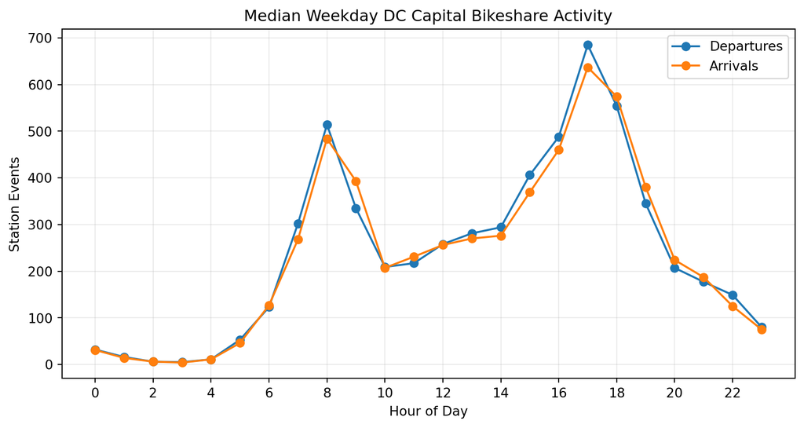

```python
fig, ax = plt.subplots(
    figsize=(
        10,
        4.8,
    )
)

ax.plot(
    weekday_hourly_profile.index,
    weekday_hourly_profile[
        "departures"
    ],
    marker="o",
    label="Departures",
)

ax.plot(
    weekday_hourly_profile.index,
    weekday_hourly_profile[
        "arrivals"
    ],
    marker="o",
    label="Arrivals",
)

ax.set_title(
    "Median Weekday DC Capital Bikeshare Activity"
)

ax.set_xlabel(
    "Hour of Day"
)

ax.set_ylabel(
    "Station Events"
)

ax.set_xticks(
    range(
        0,
        24,
        2,
    )
)

ax.legend()

ax.grid(
    alpha=0.25
)

plt.show()
```

### 12.3 Select a Representative Weekday

The representative day is the weekday whose 24-hour departure and arrival profile is closest to the median weekday profile.

```python
median_profile_reference = (
    weekday_hourly_profile[
        [
            "departures",
            "arrivals",
        ]
    ]
    .rename(
        columns={
            "departures":
                "median_departures",

            "arrivals":
                "median_arrivals",
        }
    )
    .reset_index()
)
```

```python
weekday_profile_comparison = (
    weekday_system
    .merge(
        median_profile_reference,
        on="hour",
        how="left",
        validate="many_to_one",
    )
)

weekday_profile_comparison[
    "profile_absolute_error"
] = (
    (
        weekday_profile_comparison[
            "departures"
        ]
        -
        weekday_profile_comparison[
            "median_departures"
        ]
    )
    .abs()
    +
    (
        weekday_profile_comparison[
            "arrivals"
        ]
        -
        weekday_profile_comparison[
            "median_arrivals"
        ]
    )
    .abs()
) / 2
```

```python
weekday_profile_scores = (
    weekday_profile_comparison
    .groupby(
        "date",
        as_index=False,
    )
    .agg(
        profile_mae=(
            "profile_absolute_error",
            "mean",
        ),

        departures=(
            "departures",
            "sum",
        ),

        arrivals=(
            "arrivals",
            "sum",
        ),

        daily_activity=(
            "activity",
            "sum",
        ),
    )
)
```

```python
representative_row = (
    weekday_profile_scores
    .sort_values(
        [
            "profile_mae",
            "date",
        ]
    )
    .iloc[0]
)

scenario_date = (
    representative_row[
        "date"
    ]
)

scenario_date
```

```
Timestamp('2025-01-23 00:00:00')
```

```python
median_daily_activity = (
    weekday_profile_scores[
        "daily_activity"
    ]
    .median()
)
```

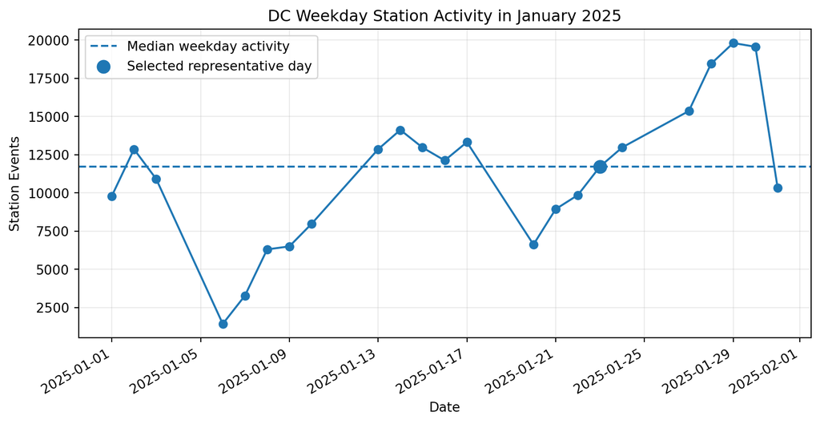

```python
fig, ax = plt.subplots(
    figsize=(
        10,
        4.8,
    )
)

ax.plot(
    weekday_profile_scores[
        "date"
    ],
    weekday_profile_scores[
        "daily_activity"
    ],
    marker="o",
)

ax.axhline(
    median_daily_activity,
    linestyle="--",
    label="Median weekday activity",
)

ax.scatter(
    [
        scenario_date
    ],
    [
        representative_row[
            "daily_activity"
        ]
    ],
    s=90,
    zorder=5,
    label="Selected representative day",
)

ax.set_title(
    "DC Weekday Station Activity in January 2025"
)

ax.set_xlabel(
    "Date"
)

ax.set_ylabel(
    "Station Events"
)

ax.legend()

ax.grid(
    alpha=0.25
)

fig.autofmt_xdate()

plt.show()
```

### 12.4 Select the Peak Operating Window

```python
representative_day_activity = (
    system_hourly.loc[
        system_hourly[
            "date"
        ]
        == scenario_date
    ]
    .copy()
)

peak_hour = int(
    representative_day_activity.loc[
        representative_day_activity[
            "activity"
        ].idxmax(),
        "hour",
    ]
)

scenario_start_hour = max(
    0,
    peak_hour - 1,
)

scenario_end_hour = min(
    24,
    peak_hour + 2,
)

scenario_hours = list(
    range(
        scenario_start_hour,
        scenario_end_hour,
    )
)
```

```python
scenario_selection = pd.DataFrame(
    {
        "Metric": [
            "Representative date",
            "Profile MAE",
            "Selected-day station activity",
            "Peak activity hour",
            "Scenario window",
        ],

        "Value": [
            scenario_date.strftime(
                "%Y-%m-%d"
            ),

            round(
                float(
                    representative_row[
                        "profile_mae"
                    ]
                ),
                2,
            ),

            int(
                representative_row[
                    "daily_activity"
                ]
            ),

            f"{peak_hour:02d}:00",

            (
                f"{scenario_start_hour:02d}:00"
                f"–"
                f"{scenario_end_hour:02d}:00"
            ),
        ],
    }
)

scenario_selection
```

|  | Metric | Value |
| --- | --- | --- |
| 0 | Representative date | 2025-01-23 |
| 1 | Profile MAE | 26.17 |
| 2 | Selected-day station activity | 11730 |
| 3 | Peak activity hour | 17:00 |
| 4 | Scenario window | 16:00–19:00 |

```python
scenario_definition = pd.DataFrame(
    {
        "scenario_date": [
            scenario_date.strftime(
                "%Y-%m-%d"
            )
        ],

        "start_hour": [
            scenario_start_hour
        ],

        "end_hour": [
            scenario_end_hour
        ],

        "peak_hour": [
            peak_hour
        ],

        "profile_mae": [
            float(
                representative_row[
                    "profile_mae"
                ]
            )
        ],

        "selected_day_activity": [
            int(
                representative_row[
                    "daily_activity"
                ]
            )
        ],
    }
)
```

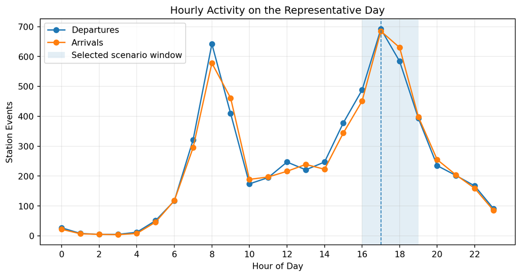

```python
fig, ax = plt.subplots(
    figsize=(
        10,
        4.8,
    )
)

ax.plot(
    representative_day_activity[
        "hour"
    ],
    representative_day_activity[
        "departures"
    ],
    marker="o",
    label="Departures",
)

ax.plot(
    representative_day_activity[
        "hour"
    ],
    representative_day_activity[
        "arrivals"
    ],
    marker="o",
    label="Arrivals",
)

ax.axvspan(
    scenario_start_hour,
    scenario_end_hour,
    alpha=0.12,
    label="Selected scenario window",
)

ax.axvline(
    peak_hour,
    linestyle="--",
    linewidth=1,
)

ax.set_title(
    "Hourly Activity on the Representative Day"
)

ax.set_xlabel(
    "Hour of Day"
)

ax.set_ylabel(
    "Station Events"
)

ax.set_xticks(
    range(
        0,
        24,
        2,
    )
)

ax.legend()

ax.grid(
    alpha=0.25
)

plt.show()
```

### 12.5 Build the Selected Scenario

```python
scenario_hourly_flows = (
    dc_station_hourly_flows.loc[
        (
            dc_station_hourly_flows[
                "date"
            ]
            == scenario_date
        )
        &
        (
            dc_station_hourly_flows[
                "hour"
            ]
            .isin(
                scenario_hours
            )
        )
    ]
    .copy()
)
```

```python
scenario_station_summary = (
    scenario_hourly_flows
    .groupby(
        [
            "short_name",
            "reference_station_id",
            "station_name",
            "reference_capacity",
            "lat",
            "lon",
        ],
        as_index=False,
    )[
        [
            "departures",
            "arrivals",
        ]
    ]
    .sum()
)

scenario_station_summary[
    "net_flow"
] = (
    scenario_station_summary[
        "arrivals"
    ]
    -
    scenario_station_summary[
        "departures"
    ]
)

scenario_station_summary[
    "station_events"
] = (
    scenario_station_summary[
        "arrivals"
    ]
    +
    scenario_station_summary[
        "departures"
    ]
)
```

```python
scenario_station_summary = (
    scenario_station_summary
    .merge(
        dc_zip_lookup,
        on="short_name",
        how="left",
        validate="one_to_one",
    )
)

scenario_station_summary[
    "absolute_net_flow"
] = (
    scenario_station_summary[
        "net_flow"
    ]
    .abs()
)

scenario_station_summary.head()
```

|  | short_name | reference_station_id | station_name | reference_capacity | lat | lon | departures | arrivals | net_flow | station_events | ZIP_CODE | absolute_net_flow |
| --- | --- | --- | --- | --- | --- | --- | --- | --- | --- | --- | --- | --- |
| 0 | 30200 | 5d8b76d9-ae82-464b-87f1-37553a9fec6c | 9th St & Pennsylvania Ave NW | 27 | 38.894280 | -77.023979 | 7 | 2 | -5 | 9 | 20004 | 5 |
| 1 | 30201 | a10f8bfa-1324-411c-b358-3fbd94eff32b | 9th & G St NW | 15 | 38.898097 | -77.023924 | 7 | 5 | -2 | 12 | 20001 | 2 |
| 2 | 31100 | 0824741d-1f3f-11e7-bf6b-3863bb334450 | 19th St & Pennsylvania Ave NW | 15 | 38.900300 | -77.042900 | 10 | 1 | -9 | 11 | 20006 | 9 |
| 3 | 31101 | 0824749f-1f3f-11e7-bf6b-3863bb334450 | 14th & V St NW | 31 | 38.917764 | -77.032096 | 12 | 15 | 3 | 27 | 20009 | 3 |
| 4 | 31102 | 08247522-1f3f-11e7-bf6b-3863bb334450 | 11th & Kenyon St NW | 39 | 38.929464 | -77.027822 | 8 | 11 | 3 | 19 | 20010 | 3 |

### 12.6 Station-Level Imbalance

The chart focuses on stations with the largest absolute net flow during the selected window.

```python
station_imbalance_plot_data = (
    scenario_station_summary.loc[
        scenario_station_summary[
            "station_events"
        ]
        > 0
    ]
    .nlargest(
        15,
        "absolute_net_flow",
    )
    .sort_values(
        "net_flow"
    )
    .copy()
)
```

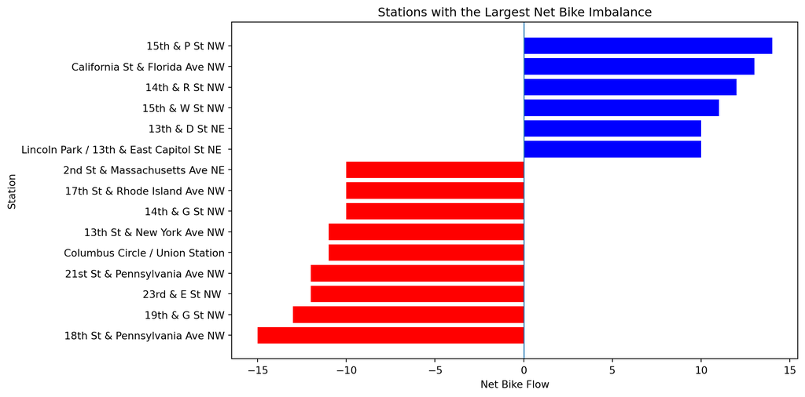

```python
fig, ax = plt.subplots(
    figsize=(
        10,
        6,
    )
)

bar_colors = np.where(
    station_imbalance_plot_data[
        "net_flow"
    ]
    < 0,
    "red",
    "blue",
)

ax.barh(
    station_imbalance_plot_data[
        "station_name"
    ],
    station_imbalance_plot_data[
        "net_flow"
    ],
    color=bar_colors,
)

ax.axvline(
    0,
    linewidth=1,
)

ax.set_title(
    "Stations with the Largest Net Bike Imbalance"
)

ax.set_xlabel(
    "Net Bike Flow"
)

ax.set_ylabel(
    "Station"
)

plt.show()
```

### 12.7 ZIP-Level Imbalance

```python
scenario_zip_summary = (
    scenario_station_summary
    .dropna(
        subset=[
            "ZIP_CODE"
        ]
    )
    .groupby(
        "ZIP_CODE",
        as_index=False,
    )[
        [
            "departures",
            "arrivals",
            "net_flow",
            "station_events",
        ]
    ]
    .sum()
)

scenario_zip_summary[
    "absolute_net_flow"
] = (
    scenario_zip_summary[
        "net_flow"
    ]
    .abs()
)
```

```python
top_zip_imbalance = (
    scenario_zip_summary
    .nlargest(
        12,
        "absolute_net_flow",
    )
    .sort_values(
        "net_flow"
    )
    .copy()
)
```

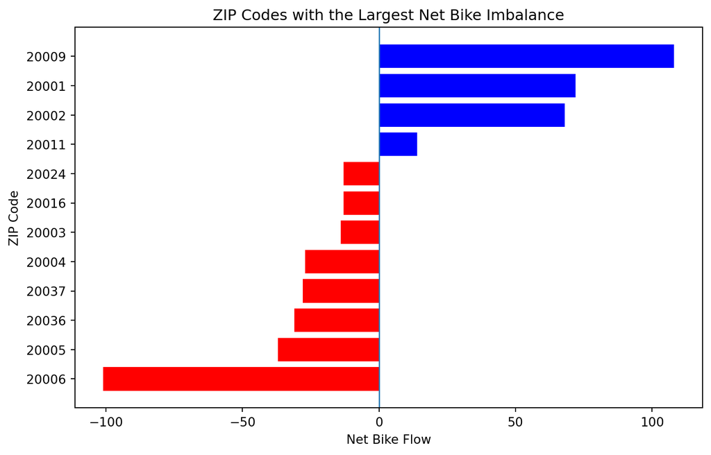

```python
fig, ax = plt.subplots(
    figsize=(
        9,
        5.5,
    )
)

zip_colors = np.where(
    top_zip_imbalance[
        "net_flow"
    ]
    < 0,
    "red",
    "blue",
)

ax.barh(
    top_zip_imbalance[
        "ZIP_CODE"
    ],
    top_zip_imbalance[
        "net_flow"
    ],
    color=zip_colors,
)

ax.axvline(
    0,
    linewidth=1,
)

ax.set_title(
    "ZIP Codes with the Largest Net Bike Imbalance"
)

ax.set_xlabel(
    "Net Bike Flow"
)

ax.set_ylabel(
    "ZIP Code"
)

plt.show()
```

### 12.8 Scenario Imbalance Map

The map summarizes regional net bike flow during the selected scenario. ZIP-code shading represents aggregate imbalance, while the most imbalanced stations are shown individually.

```python
from matplotlib.colors import TwoSlopeNorm
from matplotlib.cm import ScalarMappable
from mpl_toolkits.axes_grid1 import make_axes_locatable

scenario_zip_plot_data = (
    zip_analysis_gdf[
        [
            "ZIP_CODE",
            "geometry",
        ]
    ]
    .merge(
        scenario_zip_summary[
            [
                "ZIP_CODE",
                "departures",
                "arrivals",
                "net_flow",
                "station_events",
            ]
        ],
        on="ZIP_CODE",
        how="left",
    )
    .copy()
)

scenario_zip_plot_data[
    [
        "departures",
        "arrivals",
        "net_flow",
        "station_events",
    ]
] = (
    scenario_zip_plot_data[
        [
            "departures",
            "arrivals",
            "net_flow",
            "station_events",
        ]
    ]
    .fillna(0)
)

scenario_map_stations = (
    scenario_station_summary.loc[
        scenario_station_summary[
            "station_events"
        ] > 0
    ]
    .nlargest(
        24,
        "absolute_net_flow",
    )
    .copy()
)

loss_stations = (
    scenario_map_stations.loc[
        scenario_map_stations[
            "net_flow"
        ] < 0
    ]
    .copy()
)

gain_stations = (
    scenario_map_stations.loc[
        scenario_map_stations[
            "net_flow"
        ] > 0
    ]
    .copy()
)

max_zip_abs_flow = max(
    scenario_zip_plot_data[
        "net_flow"
    ]
    .abs()
    .max(),
    1,
)

max_station_abs_flow = max(
    scenario_map_stations[
        "absolute_net_flow"
    ]
    .max(),
    1,
)

zip_norm = TwoSlopeNorm(
    vmin=-max_zip_abs_flow,
    vcenter=0,
    vmax=max_zip_abs_flow,
)

active_station_extent = (
    scenario_station_summary.loc[
        scenario_station_summary[
            "station_events"
        ] > 0
    ]
    .copy()
)

lon_min = active_station_extent["lon"].min()
lon_max = active_station_extent["lon"].max()
lat_min = active_station_extent["lat"].min()
lat_max = active_station_extent["lat"].max()

# Tighter padding than before so the DC activity area fills the figure better
lon_pad = max(
    0.006,
    0.05 * (lon_max - lon_min),
)

lat_pad = max(
    0.006,
    0.05 * (lat_max - lat_min),
)
```

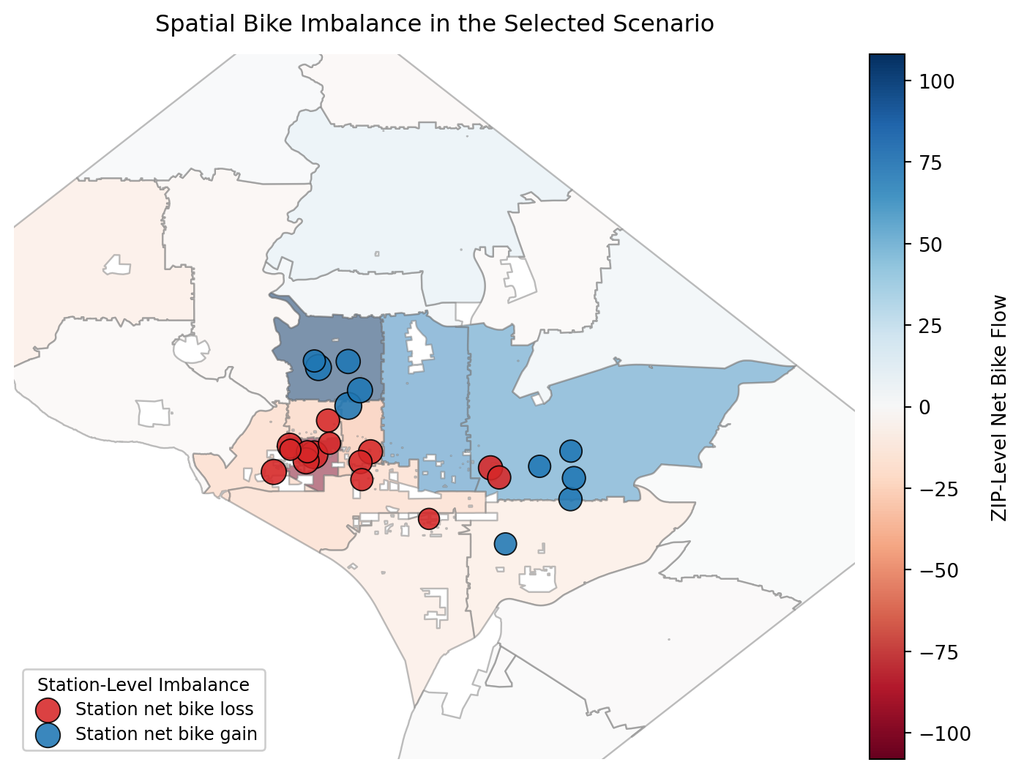

Regional and station-level bike imbalance during the selected scenario.

```python
fig, ax = plt.subplots(
    figsize=(7.4, 6.6)
)

# ZIP-level regional imbalance
scenario_zip_plot_data.plot(
    column="net_flow",
    cmap="RdBu",
    norm=zip_norm,
    linewidth=0.9,
    edgecolor="0.50",
    alpha=0.52,
    ax=ax,
)

# Smaller station markers to reduce overlap
loss_sizes = (
    20
    +
    180
    *
    loss_stations[
        "absolute_net_flow"
    ]
    /
    max_station_abs_flow
)

gain_sizes = (
    20
    +
    180
    *
    gain_stations[
        "absolute_net_flow"
    ]
    /
    max_station_abs_flow
)

# Station-level net bike loss
ax.scatter(
    loss_stations["lon"],
    loss_stations["lat"],
    s=loss_sizes,
    c="#d62728",
    marker="o",
    edgecolors="black",
    linewidths=0.7,
    alpha=0.88,
    label="Station net bike loss",
    zorder=5,
)

# Station-level net bike gain
ax.scatter(
    gain_stations["lon"],
    gain_stations["lat"],
    s=gain_sizes,
    c="#1f77b4",
    marker="o",
    edgecolors="black",
    linewidths=0.7,
    alpha=0.88,
    label="Station net bike gain",
    zorder=5,
)

# Tighter spatial focus
ax.set_xlim(
    lon_min - lon_pad,
    lon_max + lon_pad,
)

ax.set_ylim(
    lat_min - lat_pad,
    lat_max + lat_pad,
)

ax.set_aspect(
    "equal",
    adjustable="box",
)

ax.set_title(
    "Spatial Bike Imbalance in the Selected Scenario",
    pad=12,
)

ax.set_axis_off()

# Use a separate axis for the colorbar so it does not squeeze the map
divider = make_axes_locatable(ax)
cax = divider.append_axes(
    "right",
    size="4.2%",
    pad=0.10,
)

sm = ScalarMappable(
    norm=zip_norm,
    cmap="RdBu",
)
sm.set_array([])

cbar = fig.colorbar(
    sm,
    cax=cax,
)

cbar.set_label(
    "ZIP-Level Net Bike Flow",
    rotation=90,
    labelpad=10,
)

# Cleaner legend placement
ax.legend(
    title="Station-Level Imbalance",
    loc="lower left",
    frameon=True,
    framealpha=0.96,
    borderpad=0.4,
    labelspacing=0.4,
    handletextpad=0.6,
    fontsize=9,
    title_fontsize=9,
)

plt.tight_layout()
plt.show()
```

#### Interpretation

| Visual element | Meaning |
| --- | --- |
| Red ZIP shading | More departures than arrivals; regional net bike loss |
| Blue ZIP shading | More arrivals than departures; regional net bike gain |
| Darker ZIP shading | Larger absolute regional imbalance |
| Red station marker | Station-level net bike loss |
| Blue station marker | Station-level net bike gain |
| Larger station marker | Larger absolute station-level imbalance |

### 12.9 Save the Selected Scenario

```python
scenario_hourly_flows.to_csv(
    processed_dir
    / "selected_scenario_hourly_flows.csv",
    index=False,
)

scenario_station_summary.to_csv(
    processed_dir
    / "selected_scenario_station_summary.csv",
    index=False,
)

scenario_zip_summary.to_csv(
    processed_dir
    / "selected_scenario_zip_summary.csv",
    index=False,
)

scenario_definition.to_csv(
    processed_dir
    / "selected_scenario_definition.csv",
    index=False,
)
```

```python
print(
    "Representative date:",
    scenario_date.strftime(
        "%Y-%m-%d"
    )
)

print(
    "Selected time window:",
    (
        f"{scenario_start_hour:02d}:00"
        f"–"
        f"{scenario_end_hour:02d}:00"
    )
)

print(
    "DC stations:",
    len(
        scenario_station_summary
    )
)

print(
    "Active stations:",
    (
        scenario_station_summary[
            "station_events"
        ]
        > 0
    ).sum()
)

print(
    "Scenario departures:",
    scenario_station_summary[
        "departures"
    ].sum()
)

print(
    "Scenario arrivals:",
    scenario_station_summary[
        "arrivals"
    ].sum()
)
```

```
Representative date: 2025-01-23
Selected time window: 16:00–19:00
DC stations: 377
Active stations: 306
Scenario departures: 1764
Scenario arrivals: 1766
```

## Part 13 — Inventory Dynamics, Initial Conditions, and Numerical Simulation

Station inventory follows

$$S_{i,k+1}
=
S_{i,k}
+
A_{i,k}
-
D_{i,k}
+
U_{i,k}.$$

A continuous-time representation is

$$\frac{dS_i}{dt}
=
a_i(t)-d_i(t)+u_i(t).$$

For a time step $\Delta t$, the unconstrained inventory balance has the Forward Euler form

$$S_i^{n+1}
=
S_i^n
+
\Delta t
\left[
a_i(t_n)
-
d_i(t_n)
+
u_i(t_n)
\right].$$

Historical January 2025 station inventories are not observed. The baseline scenario therefore initializes the station network at 50% of reference capacity and tests alternative initial conditions separately.

### 13.1 Define the Simulation Network

Current reference capacity is used as a structural capacity proxy. Current GBFS bike inventory is not used as the historical initial condition.

```python
simulation_station_table = (
    scenario_station_summary[
        [
            "short_name",
            "reference_station_id",
            "station_name",
            "reference_capacity",
            "lat",
            "lon",
            "ZIP_CODE",
        ]
    ]
    .copy()
)

simulation_station_table[
    "capacity"
] = pd.to_numeric(
    simulation_station_table[
        "reference_capacity"
    ],
    errors="coerce",
)
```

```python
invalid_capacity_stations = (
    simulation_station_table.loc[
        simulation_station_table[
            "capacity"
        ].isna()
        |
        (
            simulation_station_table[
                "capacity"
            ]
            <= 0
        )
    ]
    .copy()
)

simulation_station_table = (
    simulation_station_table.loc[
        simulation_station_table[
            "capacity"
        ].notna()
        &
        (
            simulation_station_table[
                "capacity"
            ]
            > 0
        )
    ]
    .copy()
)

simulation_station_table[
    "capacity"
] = (
    simulation_station_table[
        "capacity"
    ]
    .astype(int)
)

simulation_station_table = (
    simulation_station_table
    .drop_duplicates(
        subset=[
            "short_name"
        ]
    )
    .sort_values(
        "short_name"
    )
    .reset_index(
        drop=True
    )
)
```

```python
simulation_short_names = set(
    simulation_station_table[
        "short_name"
    ]
)

simulation_scope_audit = pd.Series(
    {
        "Scenario stations":
            len(
                scenario_station_summary
            ),

        "Simulation stations":
            len(
                simulation_station_table
            ),

        "Excluded stations with invalid capacity":
            len(
                invalid_capacity_stations
            ),

        "Total reference capacity":
            simulation_station_table[
                "capacity"
            ].sum(),
    },
    name="Value",
)

simulation_scope_audit.to_frame()
```

|  | Value |
| --- | --- |
| Scenario stations | 377 |
| Simulation stations | 377 |
| Excluded stations with invalid capacity | 0 |
| Total reference capacity | 7620 |

### 13.2 Initial-Condition Policy

For baseline fill ratio $\rho$,

$$S_i(0)
\approx
\rho C_i,
\qquad
\rho=0.50.$$

The allocation preserves the target system-wide fill ratio while keeping station inventories integer-valued.

```python
def make_initial_inventory(
    capacity,
    fill_ratio,
):
    capacity = (
        capacity
        .astype(int)
        .copy()
    )

    raw_inventory = (
        fill_ratio
        * capacity
    )

    initial_inventory = (
        np.floor(
            raw_inventory
        )
        .astype(int)
    )

    target_total = int(
        round(
            raw_inventory.sum()
        )
    )

    remainder = (
        target_total
        - initial_inventory.sum()
    )

    if remainder > 0:

        fractional_part = (
            raw_inventory
            - initial_inventory
        )

        add_one = (
            fractional_part
            .sort_values(
                ascending=False
            )
            .head(
                remainder
            )
            .index
        )

        initial_inventory.loc[
            add_one
        ] += 1

    return initial_inventory
```

```python
capacity_series = (
    simulation_station_table
    .set_index(
        "short_name"
    )[
        "capacity"
    ]
)

baseline_fill_ratio = 0.50

baseline_initial_inventory = (
    make_initial_inventory(
        capacity_series,
        baseline_fill_ratio,
    )
)

initial_state = (
    simulation_station_table[
        [
            "short_name",
            "station_name",
            "capacity",
        ]
    ]
    .copy()
)

initial_state[
    "initial_inventory"
] = (
    initial_state[
        "short_name"
    ]
    .map(
        baseline_initial_inventory
    )
)

initial_state[
    "initial_fill_ratio"
] = (
    initial_state[
        "initial_inventory"
    ]
    /
    initial_state[
        "capacity"
    ]
)

initial_state.head()
```

|  | short_name | station_name | capacity | initial_inventory | initial_fill_ratio |
| --- | --- | --- | --- | --- | --- |
| 0 | 30200 | 9th St & Pennsylvania Ave NW | 27 | 14 | 0.518519 |
| 1 | 30201 | 9th & G St NW | 15 | 8 | 0.533333 |
| 2 | 31100 | 19th St & Pennsylvania Ave NW | 15 | 8 | 0.533333 |
| 3 | 31101 | 14th & V St NW | 31 | 16 | 0.516129 |
| 4 | 31102 | 11th & Kenyon St NW | 39 | 20 | 0.512821 |

```python
initial_condition_summary = pd.Series(
    {
        "Stations":
            len(
                initial_state
            ),

        "Total capacity":
            initial_state[
                "capacity"
            ].sum(),

        "Initial bikes":
            initial_state[
                "initial_inventory"
            ].sum(),

        "System fill ratio":
            (
                initial_state[
                    "initial_inventory"
                ].sum()
                /
                initial_state[
                    "capacity"
                ].sum()
            ),
    },
    name="Value",
)

initial_condition_summary.to_frame()
```

|  | Value |
| --- | --- |
| Stations | 377.0 |
| Total capacity | 7620.0 |
| Initial bikes | 3810.0 |
| System fill ratio | 0.5 |

### 13.3 Build Time-Step Flow Tables

Observed departure and arrival events are re-aggregated directly from their timestamps so that numerical sensitivity can be tested at different time resolutions.

```python
scenario_start_time = (
    pd.Timestamp(
        scenario_date
    )
    +
    pd.Timedelta(
        hours=
            scenario_start_hour
    )
)

scenario_end_time = (
    pd.Timestamp(
        scenario_date
    )
    +
    pd.Timedelta(
        hours=
            scenario_end_hour
    )
)

scenario_start_time, scenario_end_time
```

```
(Timestamp('2025-01-23 16:00:00'), Timestamp('2025-01-23 19:00:00'))
```

```python
def build_simulation_flow_table(
    step_minutes,
):

    frequency = (
        f"{step_minutes}min"
    )

    step_grid = pd.date_range(
        start=
            scenario_start_time,
        end=
            scenario_end_time,
        freq=
            frequency,
        inclusive=
            "left",
    )

    departure_subset = (
        matched_departures.loc[
            (
                matched_departures[
                    "started_at"
                ]
                >= scenario_start_time
            )
            &
            (
                matched_departures[
                    "started_at"
                ]
                < scenario_end_time
            )
            &
            matched_departures[
                "short_name"
            ].isin(
                simulation_short_names
            )
        ]
        .copy()
    )

    arrival_subset = (
        matched_arrivals.loc[
            (
                matched_arrivals[
                    "ended_at"
                ]
                >= scenario_start_time
            )
            &
            (
                matched_arrivals[
                    "ended_at"
                ]
                < scenario_end_time
            )
            &
            matched_arrivals[
                "short_name"
            ].isin(
                simulation_short_names
            )
        ]
        .copy()
    )

    departure_subset[
        "time"
    ] = (
        departure_subset[
            "started_at"
        ]
        .dt.floor(
            frequency
        )
    )

    arrival_subset[
        "time"
    ] = (
        arrival_subset[
            "ended_at"
        ]
        .dt.floor(
            frequency
        )
    )

    departure_counts = (
        departure_subset
        .groupby(
            [
                "time",
                "short_name",
            ]
        )
        .size()
        .reset_index(
            name=
                "departures"
        )
    )

    arrival_counts = (
        arrival_subset
        .groupby(
            [
                "time",
                "short_name",
            ]
        )
        .size()
        .reset_index(
            name=
                "arrivals"
        )
    )

    station_grid = (
        pd.MultiIndex.from_product(
            [
                step_grid,
                simulation_station_table[
                    "short_name"
                ],
            ],
            names=[
                "time",
                "short_name",
            ],
        )
        .to_frame(
            index=False
        )
    )

    flow_table = (
        station_grid
        .merge(
            departure_counts,
            on=[
                "time",
                "short_name",
            ],
            how="left",
            validate=
                "one_to_one",
        )
        .merge(
            arrival_counts,
            on=[
                "time",
                "short_name",
            ],
            how="left",
            validate=
                "one_to_one",
        )
    )

    flow_table[
        [
            "departures",
            "arrivals",
        ]
    ] = (
        flow_table[
            [
                "departures",
                "arrivals",
            ]
        ]
        .fillna(0)
        .astype(int)
    )

    flow_table = (
        flow_table
        .merge(
            simulation_station_table[
                [
                    "short_name",
                    "station_name",
                    "capacity",
                    "lat",
                    "lon",
                    "ZIP_CODE",
                ]
            ],
            on=
                "short_name",
            how=
                "left",
            validate=
                "many_to_one",
        )
    )

    dt_hours = (
        step_minutes
        / 60
    )

    flow_table[
        "arrival_rate"
    ] = (
        flow_table[
            "arrivals"
        ]
        /
        dt_hours
    )

    flow_table[
        "departure_rate"
    ] = (
        flow_table[
            "departures"
        ]
        /
        dt_hours
    )

    return flow_table
```

```python
simulation_flows_60 = (
    build_simulation_flow_table(
        60
    )
)
```

```python
expected_hourly_scope = (
    scenario_hourly_flows.loc[
        scenario_hourly_flows[
            "short_name"
        ].isin(
            simulation_short_names
        )
    ]
)

if (
    simulation_flows_60[
        "departures"
    ].sum()
    !=
    expected_hourly_scope[
        "departures"
    ].sum()
):

    raise ValueError(
        "60-minute departure totals do not match Part 12."
    )

if (
    simulation_flows_60[
        "arrivals"
    ].sum()
    !=
    expected_hourly_scope[
        "arrivals"
    ].sum()
):

    raise ValueError(
        "60-minute arrival totals do not match Part 12."
    )
```

### 13.4 Capacity-Constrained Inventory Simulation

Within each numerical interval, rebalancing is applied first, followed by departure requests and arrival requests.

For departures,

$$\widetilde D_{i,k}
=
\min
\left(
D_{i,k},
S_{i,k}^{+}
\right),$$

where $S_{i,k}^{+}$ is inventory after rebalancing.

Unmet departure demand is

$$L_{i,k}^{D}
=
D_{i,k}
-
\widetilde D_{i,k}.$$

Accepted arrivals satisfy

$$\widetilde A_{i,k}
=
\min
\left(
A_{i,k},
C_i
-
S_{i,k}^{+}
+
\widetilde D_{i,k}
\right),$$

with blocked arrivals

$$L_{i,k}^{A}
=
A_{i,k}
-
\widetilde A_{i,k}.$$

The constrained update becomes

$$S_{i,k+1}
=
S_{i,k}^{+}
-
\widetilde D_{i,k}
+
\widetilde A_{i,k}.$$

```python
def greedy_threshold_rebalance(
    inventory,
    capacity,
    bike_budget,
    low_threshold=0.25,
    high_threshold=0.75,
    target_fill=0.50,
):

    inventory = (
        inventory
        .copy()
        .astype(int)
    )

    capacity = (
        capacity
        .copy()
        .astype(int)
    )

    fill_ratio = (
        inventory
        /
        capacity
    )

    target_inventory = (
        make_initial_inventory(
            capacity,
            target_fill,
        )
    )

    donor_supply = (
        inventory
        -
        target_inventory
    ).clip(
        lower=0
    )

    receiver_need = (
        target_inventory
        -
        inventory
    ).clip(
        lower=0
    )

    donor_supply = (
        donor_supply.loc[
            (
                fill_ratio
                >= high_threshold
            )
            &
            (
                donor_supply
                > 0
            )
        ]
        .sort_values(
            ascending=False
        )
    )

    receiver_need = (
        receiver_need.loc[
            (
                fill_ratio
                <= low_threshold
            )
            &
            (
                receiver_need
                > 0
            )
        ]
        .sort_values(
            ascending=False
        )
    )

    delta = pd.Series(
        0,
        index=
            inventory.index,
        dtype=int,
    )

    transfers = []

    remaining_budget = int(
        bike_budget
    )

    for receiver in (
        receiver_need.index
    ):

        need = int(
            receiver_need.loc[
                receiver
            ]
        )

        if (
            need <= 0
            or
            remaining_budget <= 0
        ):
            continue

        for donor in (
            donor_supply.index
        ):

            available = int(
                donor_supply.loc[
                    donor
                ]
            )

            if available <= 0:
                continue

            moved = min(
                need,
                available,
                remaining_budget,
            )

            if moved <= 0:
                continue

            delta.loc[
                donor
            ] -= moved

            delta.loc[
                receiver
            ] += moved

            donor_supply.loc[
                donor
            ] -= moved

            need -= moved

            remaining_budget -= moved

            transfers.append(
                {
                    "from_short_name":
                        donor,
                    "to_short_name":
                        receiver,
                    "bikes":
                        moved,
                }
            )

            if (
                need <= 0
                or
                remaining_budget <= 0
            ):
                break

        if remaining_budget <= 0:
            break

    if delta.sum() != 0:

        raise ValueError(
            "Heuristic rebalancing does not conserve bikes."
        )

    return (
        delta,
        transfers,
    )
```

```python
def simulate_inventory(
    flow_table,
    step_minutes,
    initial_fill_ratio=0.50,
    policy="none",
    rebalancing_budget=0,
):

    station_table = (
        simulation_station_table
        .set_index(
            "short_name"
        )
    )

    station_ids = (
        station_table.index
        .tolist()
    )

    capacity = (
        station_table[
            "capacity"
        ]
        .astype(int)
    )

    inventory = (
        make_initial_inventory(
            capacity,
            initial_fill_ratio,
        )
    )

    simulation_records = []
    transfer_records = []

    dt_hours = (
        step_minutes
        / 60
    )

    for time, block in (
        flow_table
        .groupby(
            "time",
            sort=True,
        )
    ):

        block = (
            block
            .set_index(
                "short_name"
            )
            .reindex(
                station_ids
            )
        )

        start_inventory = (
            inventory
            .copy()
        )

        rebalance_delta = pd.Series(
            0,
            index=
                station_ids,
            dtype=int,
        )

        if policy == "heuristic":

            (
                rebalance_delta,
                transfers,
            ) = (
                greedy_threshold_rebalance(
                    inventory=
                        inventory,
                    capacity=
                        capacity,
                    bike_budget=
                        rebalancing_budget,
                )
            )

            for transfer in transfers:

                transfer[
                    "time"
                ] = time

                transfer_records.append(
                    transfer
                )

        inventory_after_rebalancing = (
            inventory
            +
            rebalance_delta
        )

        if (
            (
                inventory_after_rebalancing
                < 0
            ).any()
            or
            (
                inventory_after_rebalancing
                > capacity
            ).any()
        ):

            raise ValueError(
                "Rebalancing produced an infeasible inventory."
            )

        requested_departures = (
            block[
                "departures"
            ]
            .fillna(0)
            .astype(int)
        )

        requested_arrivals = (
            block[
                "arrivals"
            ]
            .fillna(0)
            .astype(int)
        )

        arrival_rate = (
            requested_arrivals
            /
            dt_hours
        )

        departure_rate = (
            requested_departures
            /
            dt_hours
        )

        unconstrained_end_inventory = (
            inventory_after_rebalancing
            +
            dt_hours
            * (
                arrival_rate
                -
                departure_rate
            )
        )

        served_departures = pd.Series(
            np.minimum(
                requested_departures,
                inventory_after_rebalancing,
            ),
            index=
                station_ids,
            dtype=int,
        )

        unmet_departures = (
            requested_departures
            -
            served_departures
        )

        inventory_after_departures = (
            inventory_after_rebalancing
            -
            served_departures
        )

        available_docks = (
            capacity
            -
            inventory_after_departures
        )

        accepted_arrivals = pd.Series(
            np.minimum(
                requested_arrivals,
                available_docks,
            ),
            index=
                station_ids,
            dtype=int,
        )

        blocked_arrivals = (
            requested_arrivals
            -
            accepted_arrivals
        )

        end_inventory = (
            inventory_after_departures
            +
            accepted_arrivals
        )

        if (
            (
                end_inventory
                < 0
            ).any()
            or
            (
                end_inventory
                > capacity
            ).any()
        ):

            raise ValueError(
                "Simulation produced inventory outside station capacity."
            )

        step_result = pd.DataFrame(
            {
                "time":
                    time,

                "time_end":
                    (
                        time
                        +
                        pd.Timedelta(
                            minutes=
                                step_minutes
                        )
                    ),

                "short_name":
                    station_ids,

                "station_name":
                    station_table.loc[
                        station_ids,
                        "station_name",
                    ].to_numpy(),

                "capacity":
                    capacity.loc[
                        station_ids
                    ].to_numpy(),

                "start_inventory":
                    start_inventory.loc[
                        station_ids
                    ].to_numpy(),

                "rebalance_delta":
                    rebalance_delta.loc[
                        station_ids
                    ].to_numpy(),

                "inventory_after_rebalancing":
                    inventory_after_rebalancing.loc[
                        station_ids
                    ].to_numpy(),

                "requested_departures":
                    requested_departures.loc[
                        station_ids
                    ].to_numpy(),

                "served_departures":
                    served_departures.loc[
                        station_ids
                    ].to_numpy(),

                "unmet_departures":
                    unmet_departures.loc[
                        station_ids
                    ].to_numpy(),

                "requested_arrivals":
                    requested_arrivals.loc[
                        station_ids
                    ].to_numpy(),

                "accepted_arrivals":
                    accepted_arrivals.loc[
                        station_ids
                    ].to_numpy(),

                "blocked_arrivals":
                    blocked_arrivals.loc[
                        station_ids
                    ].to_numpy(),

                "unconstrained_end_inventory":
                    unconstrained_end_inventory.loc[
                        station_ids
                    ].to_numpy(),

                "end_inventory":
                    end_inventory.loc[
                        station_ids
                    ].to_numpy(),
            }
        )

        step_result[
            "end_fill_ratio"
        ] = (
            step_result[
                "end_inventory"
            ]
            /
            step_result[
                "capacity"
            ]
        )

        simulation_records.append(
            step_result
        )

        inventory = (
            end_inventory
            .copy()
        )

    simulation_result = (
        pd.concat(
            simulation_records,
            ignore_index=True,
        )
    )

    transfers_result = pd.DataFrame(
        transfer_records,
        columns=[
            "time",
            "from_short_name",
            "to_short_name",
            "bikes",
        ],
    )

    return (
        simulation_result,
        transfers_result,
    )
```

### 13.5 No-Rebalancing Baseline

```python
baseline_simulation, baseline_transfers = (
    simulate_inventory(
        flow_table=
            simulation_flows_60,
        step_minutes=
            60,
        initial_fill_ratio=
            baseline_fill_ratio,
        policy=
            "none",
    )
)
```

```python
baseline_capacity_violations = pd.Series(
    {
        "Unconstrained states below zero":
            (
                baseline_simulation[
                    "unconstrained_end_inventory"
                ]
                < 0
            ).sum(),

        "Unconstrained states above capacity":
            (
                baseline_simulation[
                    "unconstrained_end_inventory"
                ]
                >
                baseline_simulation[
                    "capacity"
                ]
            ).sum(),
    },
    name="Count",
)

baseline_capacity_violations.to_frame()
```

|  | Count |
| --- | --- |
| Unconstrained states below zero | 6 |
| Unconstrained states above capacity | 3 |

### 13.6 Reactive Rebalancing Benchmark

The heuristic is intentionally simple: stations at or below 25% fill can receive bikes from stations at or above 75% fill, with a 50% target.

The hourly relocation budget is set to 1% of total modeled station capacity. This is a scenario parameter rather than an observed Capital Bikeshare operating limit.

```python
total_simulation_capacity = (
    simulation_station_table[
        "capacity"
    ]
    .sum()
)

heuristic_budget_per_hour = max(
    1,
    int(
        round(
            0.01
            * total_simulation_capacity
        )
    ),
)

heuristic_budget_per_hour
```

```
76
```

```python
heuristic_simulation, heuristic_transfers = (
    simulate_inventory(
        flow_table=
            simulation_flows_60,
        step_minutes=
            60,
        initial_fill_ratio=
            baseline_fill_ratio,
        policy=
            "heuristic",
        rebalancing_budget=
            heuristic_budget_per_hour,
    )
)
```

### 13.7 Compare the Two Policies

```python
def summarize_simulation(
    simulation,
    transfers,
    policy_name,
):

    requested_departures = (
        simulation[
            "requested_departures"
        ]
        .sum()
    )

    requested_arrivals = (
        simulation[
            "requested_arrivals"
        ]
        .sum()
    )

    served_departures = (
        simulation[
            "served_departures"
        ]
        .sum()
    )

    accepted_arrivals = (
        simulation[
            "accepted_arrivals"
        ]
        .sum()
    )

    unmet_departures = (
        simulation[
            "unmet_departures"
        ]
        .sum()
    )

    blocked_arrivals = (
        simulation[
            "blocked_arrivals"
        ]
        .sum()
    )

    requested_events = (
        requested_departures
        +
        requested_arrivals
    )

    served_events = (
        served_departures
        +
        accepted_arrivals
    )

    bikes_rebalanced = (
        transfers[
            "bikes"
        ].sum()
        if len(
            transfers
        ) > 0
        else 0
    )

    empty_station_intervals = (
        simulation[
            "end_inventory"
        ]
        .eq(0)
        .sum()
    )

    full_station_intervals = (
        simulation[
            "end_inventory"
        ]
        .eq(
            simulation[
                "capacity"
            ]
        )
        .sum()
    )

    stations_ever_empty = (
        simulation.loc[
            simulation[
                "end_inventory"
            ]
            == 0,
            "short_name",
        ]
        .nunique()
    )

    stations_ever_full = (
        simulation.loc[
            simulation[
                "end_inventory"
            ]
            ==
            simulation[
                "capacity"
            ],
            "short_name",
        ]
        .nunique()
    )

    return {
        "Policy":
            policy_name,

        "Requested departures":
            requested_departures,

        "Served departures":
            served_departures,

        "Unmet departures":
            unmet_departures,

        "Requested arrivals":
            requested_arrivals,

        "Accepted arrivals":
            accepted_arrivals,

        "Blocked arrivals":
            blocked_arrivals,

        "Total service failures":
            (
                unmet_departures
                +
                blocked_arrivals
            ),

        "Service success rate":
            (
                served_events
                /
                requested_events
                if requested_events > 0
                else np.nan
            ),

        "Stations ever empty":
            stations_ever_empty,

        "Stations ever full":
            stations_ever_full,

        "Empty station-intervals":
            empty_station_intervals,

        "Full station-intervals":
            full_station_intervals,

        "Bikes rebalanced":
            bikes_rebalanced,
    }
```

```python
policy_kpis = pd.DataFrame(
    [
        summarize_simulation(
            baseline_simulation,
            baseline_transfers,
            "No rebalancing",
        ),
        summarize_simulation(
            heuristic_simulation,
            heuristic_transfers,
            "Reactive heuristic",
        ),
    ]
)

baseline_failures = int(
    policy_kpis.loc[
        policy_kpis[
            "Policy"
        ]
        == "No rebalancing",
        "Total service failures",
    ]
    .iloc[0]
)

policy_kpis[
    "Service improvement vs baseline"
] = (
    baseline_failures
    -
    policy_kpis[
        "Total service failures"
    ]
)

policy_kpis
```

|  | Policy | Requested departures | Served departures | Unmet departures | Requested arrivals | Accepted arrivals | Blocked arrivals | Total service failures | Service success rate | Stations ever empty | Stations ever full | Empty station-intervals | Full station-intervals | Bikes rebalanced | Service improvement vs baseline |
| --- | --- | --- | --- | --- | --- | --- | --- | --- | --- | --- | --- | --- | --- | --- | --- |
| 0 | No rebalancing | 1764 | 1747 | 17 | 1766 | 1756 | 10 | 27 | 0.992351 | 4 | 3 | 4 | 3 | 0 | 0 |
| 1 | Reactive heuristic | 1764 | 1759 | 5 | 1766 | 1766 | 0 | 5 | 0.998584 | 1 | 0 | 1 | 0 | 84 | 22 |

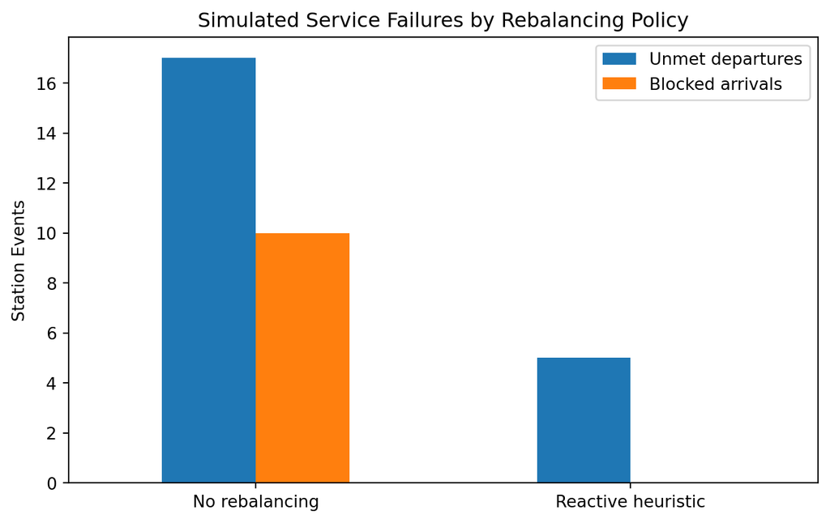

```python
policy_plot = (
    policy_kpis
    .set_index(
        "Policy"
    )[
        [
            "Unmet departures",
            "Blocked arrivals",
        ]
    ]
)

ax = policy_plot.plot(
    kind="bar",
    figsize=(
        8,
        4.8,
    ),
)

ax.set_title(
    "Simulated Service Failures by Rebalancing Policy"
)

ax.set_xlabel(
    ""
)

ax.set_ylabel(
    "Station Events"
)

ax.tick_params(
    axis="x",
    rotation=0,
)

plt.show()
```

### 13.8 System Inventory over Time

Passenger flows can change the number of bikes currently located at modeled stations. Rebalancing itself only transfers bikes between stations.

```python
baseline_system_inventory = (
    baseline_simulation
    .groupby(
        "time_end",
        as_index=False,
    )[
        "end_inventory"
    ]
    .sum()
    .rename(
        columns={
            "end_inventory":
                "No rebalancing"
        }
    )
)

heuristic_system_inventory = (
    heuristic_simulation
    .groupby(
        "time_end",
        as_index=False,
    )[
        "end_inventory"
    ]
    .sum()
    .rename(
        columns={
            "end_inventory":
                "Reactive heuristic"
        }
    )
)

system_inventory_comparison = (
    baseline_system_inventory
    .merge(
        heuristic_system_inventory,
        on=
            "time_end",
        how=
            "inner",
        validate=
            "one_to_one",
    )
)
```

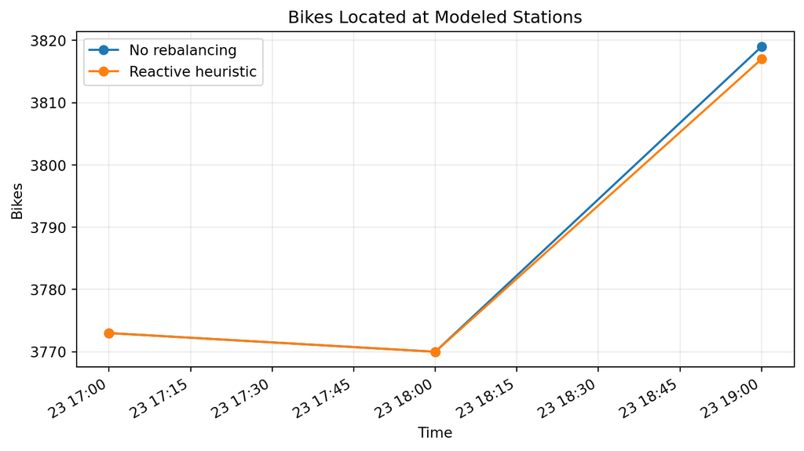

```python
fig, ax = plt.subplots(
    figsize=(
        9,
        4.8,
    )
)

ax.plot(
    system_inventory_comparison[
        "time_end"
    ],
    system_inventory_comparison[
        "No rebalancing"
    ],
    marker="o",
    label="No rebalancing",
)

ax.plot(
    system_inventory_comparison[
        "time_end"
    ],
    system_inventory_comparison[
        "Reactive heuristic"
    ],
    marker="o",
    label="Reactive heuristic",
)

ax.set_title(
    "Bikes Located at Modeled Stations"
)

ax.set_xlabel(
    "Time"
)

ax.set_ylabel(
    "Bikes"
)

ax.legend()

ax.grid(
    alpha=0.25
)

fig.autofmt_xdate()

plt.show()
```

### 13.9 Inventory Trajectories at Stressed Stations

```python
baseline_station_stress = (
    baseline_simulation
    .assign(
        service_failures=
            (
                baseline_simulation[
                    "unmet_departures"
                ]
                +
                baseline_simulation[
                    "blocked_arrivals"
                ]
            )
    )
    .groupby(
        [
            "short_name",
            "station_name",
        ],
        as_index=False,
    )[
        "service_failures"
    ]
    .sum()
)
```

```python
if (
    baseline_station_stress[
        "service_failures"
    ]
    .max()
    > 0
):

    stressed_station_ids = (
        baseline_station_stress
        .nlargest(
            6,
            "service_failures",
        )[
            "short_name"
        ]
        .tolist()
    )

else:

    stressed_station_ids = (
        scenario_station_summary
        .assign(
            absolute_net_flow=
                scenario_station_summary[
                    "net_flow"
                ]
                .abs()
        )
        .nlargest(
            6,
            "absolute_net_flow",
        )[
            "short_name"
        ]
        .tolist()
    )
```

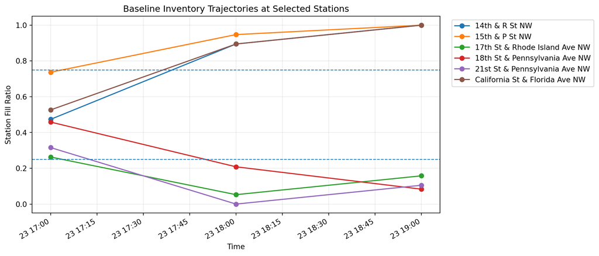

```python
trajectory_data = (
    baseline_simulation.loc[
        baseline_simulation[
            "short_name"
        ].isin(
            stressed_station_ids
        )
    ]
    .copy()
)

fig, ax = plt.subplots(
    figsize=(
        10,
        5.5,
    )
)

for (
    station_name,
    station_data,
) in (
    trajectory_data
    .groupby(
        "station_name"
    )
):

    ax.plot(
        station_data[
            "time_end"
        ],
        station_data[
            "end_fill_ratio"
        ],
        marker="o",
        label=
            station_name,
    )

ax.axhline(
    0.25,
    linestyle="--",
    linewidth=1,
)

ax.axhline(
    0.75,
    linestyle="--",
    linewidth=1,
)

ax.set_title(
    "Baseline Inventory Trajectories at Selected Stations"
)

ax.set_xlabel(
    "Time"
)

ax.set_ylabel(
    "Station Fill Ratio"
)

ax.legend(
    bbox_to_anchor=(
        1.02,
        1,
    ),
    loc="upper left",
)

ax.grid(
    alpha=0.25
)

fig.autofmt_xdate()

plt.show()
```

### 13.10 Initial-Condition Sensitivity

Because historical starting inventory is unknown, the baseline is repeated under several initial network fill ratios.

```python
initial_fill_scenarios = [
    0.35,
    0.50,
    0.65,
]

initial_condition_results = []

for fill_ratio in (
    initial_fill_scenarios
):

    simulation_result, _ = (
        simulate_inventory(
            flow_table=
                simulation_flows_60,
            step_minutes=
                60,
            initial_fill_ratio=
                fill_ratio,
            policy=
                "none",
        )
    )

    summary = (
        summarize_simulation(
            simulation_result,
            pd.DataFrame(
                columns=[
                    "bikes"
                ]
            ),
            f"{fill_ratio:.0%}",
        )
    )

    summary[
        "Initial fill ratio"
    ] = fill_ratio

    initial_condition_results.append(
        summary
    )

initial_condition_sensitivity = (
    pd.DataFrame(
        initial_condition_results
    )
)

initial_condition_sensitivity[
    [
        "Initial fill ratio",
        "Unmet departures",
        "Blocked arrivals",
        "Total service failures",
        "Stations ever empty",
        "Stations ever full",
    ]
]
```

|  | Initial fill ratio | Unmet departures | Blocked arrivals | Total service failures | Stations ever empty | Stations ever full |
| --- | --- | --- | --- | --- | --- | --- |
| 0 | 0.35 | 66 | 3 | 69 | 11 | 3 |
| 1 | 0.50 | 17 | 10 | 27 | 4 | 3 |
| 2 | 0.65 | 4 | 32 | 36 | 0 | 18 |

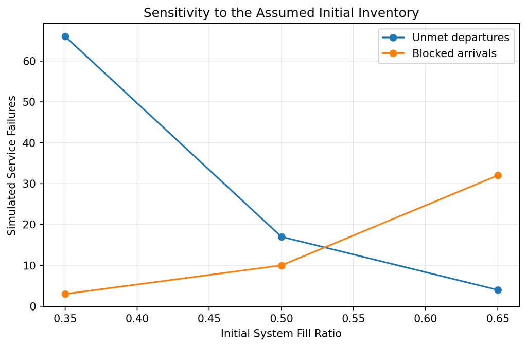

```python
fig, ax = plt.subplots(
    figsize=(
        8,
        4.8,
    )
)

ax.plot(
    initial_condition_sensitivity[
        "Initial fill ratio"
    ],
    initial_condition_sensitivity[
        "Unmet departures"
    ],
    marker="o",
    label="Unmet departures",
)

ax.plot(
    initial_condition_sensitivity[
        "Initial fill ratio"
    ],
    initial_condition_sensitivity[
        "Blocked arrivals"
    ],
    marker="o",
    label="Blocked arrivals",
)

ax.set_title(
    "Sensitivity to the Assumed Initial Inventory"
)

ax.set_xlabel(
    "Initial System Fill Ratio"
)

ax.set_ylabel(
    "Simulated Service Failures"
)

ax.legend()

ax.grid(
    alpha=0.25
)

plt.show()
```

### 13.11 Time-Step Sensitivity

The operational model is also tested with finer time intervals.

This is a numerical robustness check rather than a formal order-of-convergence estimate because the capacity constraints introduce clipping and the forcing is constructed from discrete observed events.

```python
step_sizes = [
    60,
    30,
    15,
    5,
]

step_simulations = {}
step_sensitivity_rows = []

for step_minutes in (
    step_sizes
):

    flow_table = (
        build_simulation_flow_table(
            step_minutes
        )
    )

    simulation_result, _ = (
        simulate_inventory(
            flow_table=
                flow_table,
            step_minutes=
                step_minutes,
            initial_fill_ratio=
                baseline_fill_ratio,
            policy=
                "none",
        )
    )

    step_simulations[
        step_minutes
    ] = simulation_result

    summary = (
        summarize_simulation(
            simulation_result,
            pd.DataFrame(
                columns=[
                    "bikes"
                ]
            ),
            f"{step_minutes} min",
        )
    )

    step_sensitivity_rows.append(
        {
            "Step minutes":
                step_minutes,

            "Unmet departures":
                summary[
                    "Unmet departures"
                ],

            "Blocked arrivals":
                summary[
                    "Blocked arrivals"
                ],

            "Total service failures":
                summary[
                    "Total service failures"
                ],
        }
    )
```

```python
reference_step = 5

reference_final_inventory = (
    step_simulations[
        reference_step
    ]
    .sort_values(
        "time_end"
    )
    .groupby(
        "short_name",
        as_index=True,
    )
    .tail(1)
    .set_index(
        "short_name"
    )[
        "end_inventory"
    ]
)
```

```python
for row in (
    step_sensitivity_rows
):

    step_minutes = (
        row[
            "Step minutes"
        ]
    )

    final_inventory = (
        step_simulations[
            step_minutes
        ]
        .sort_values(
            "time_end"
        )
        .groupby(
            "short_name",
            as_index=True,
        )
        .tail(1)
        .set_index(
            "short_name"
        )[
            "end_inventory"
        ]
    )

    common_stations = (
        final_inventory.index
        .intersection(
            reference_final_inventory.index
        )
    )

    final_inventory_mae = (
        (
            final_inventory.loc[
                common_stations
            ]
            -
            reference_final_inventory.loc[
                common_stations
            ]
        )
        .abs()
        .mean()
    )

    row[
        "Final inventory MAE vs 5-minute grid"
    ] = (
        final_inventory_mae
    )

time_step_sensitivity = (
    pd.DataFrame(
        step_sensitivity_rows
    )
    .sort_values(
        "Step minutes",
        ascending=False,
    )
)

time_step_sensitivity
```

|  | Step minutes | Unmet departures | Blocked arrivals | Total service failures | Final inventory MAE vs 5-minute grid |
| --- | --- | --- | --- | --- | --- |
| 0 | 60 | 17 | 10 | 27 | 0.018568 |
| 1 | 30 | 13 | 10 | 23 | 0.007958 |
| 2 | 15 | 10 | 10 | 20 | 0.000000 |
| 3 | 5 | 10 | 10 | 20 | 0.000000 |

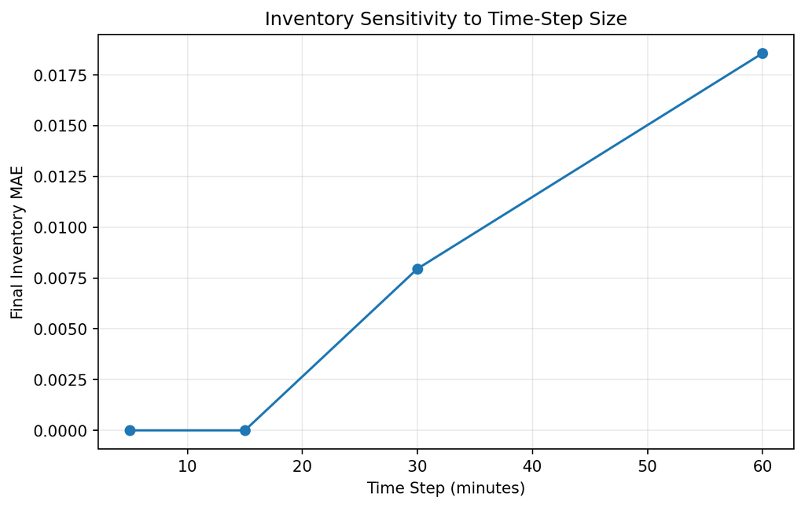

```python
fig, ax = plt.subplots(
    figsize=(
        8,
        4.8,
    )
)

ax.plot(
    time_step_sensitivity[
        "Step minutes"
    ],
    time_step_sensitivity[
        "Final inventory MAE vs 5-minute grid"
    ],
    marker="o",
)

ax.set_title(
    "Inventory Sensitivity to Time-Step Size"
)

ax.set_xlabel(
    "Time Step (minutes)"
)

ax.set_ylabel(
    "Final Inventory MAE"
)

ax.grid(
    alpha=0.25
)

plt.show()
```

### 13.12 Save the Simulation Outputs

```python
baseline_simulation.to_csv(
    processed_dir
    / "baseline_inventory_simulation.csv",
    index=False,
)

heuristic_simulation.to_csv(
    processed_dir
    / "heuristic_inventory_simulation.csv",
    index=False,
)

heuristic_transfers.to_csv(
    processed_dir
    / "heuristic_rebalancing_transfers.csv",
    index=False,
)

policy_kpis.to_csv(
    processed_dir
    / "inventory_policy_kpis.csv",
    index=False,
)

initial_condition_sensitivity.to_csv(
    processed_dir
    / "initial_condition_sensitivity.csv",
    index=False,
)

time_step_sensitivity.to_csv(
    processed_dir
    / "time_step_sensitivity.csv",
    index=False,
)

initial_state.to_csv(
    processed_dir
    / "simulation_initial_state.csv",
    index=False,
)
```

```python
print(
    "Initial fill ratio:",
    f"{baseline_fill_ratio:.0%}"
)

print(
    "Hourly heuristic budget:",
    heuristic_budget_per_hour,
    "bikes"
)

print(
    "Baseline service failures:",
    int(
        policy_kpis.loc[
            policy_kpis[
                "Policy"
            ]
            == "No rebalancing",
            "Total service failures",
        ]
        .iloc[0]
    )
)

print(
    "Heuristic service failures:",
    int(
        policy_kpis.loc[
            policy_kpis[
                "Policy"
            ]
            == "Reactive heuristic",
            "Total service failures",
        ]
        .iloc[0]
    )
)
```

```
Initial fill ratio: 50%
Hourly heuristic budget: 76 bikes
Baseline service failures: 27
Heuristic service failures: 5
```

The simulated service failures are hypothetical failures under the assumed initial inventory and station capacities. They are not estimates of actual historical unmet demand.

The optimized policy in Part 14 will use the same inventory and service accounting framework so that its performance can be compared directly with the no-rebalancing and heuristic benchmarks.

**Linear Optimization**

## Part 14 — Linear Bike Rebalancing Model: Formulation and Solution

Let

$$x_{ij,k}
=
\text{bikes rebalanced from station } i
\text{ to station } j
\text{ during interval } k.$$

The LP also includes

$$y_{i,k}^{D}
=
\text{served departures},$$

$$y_{i,k}^{A}
=
\text{accepted arrivals},$$

and service-failure variables

$$u_{i,k}^{D}
=
D_{i,k}-y_{i,k}^{D},$$

$$u_{i,k}^{A}
=
A_{i,k}-y_{i,k}^{A}.$$

The objective is

$$\min
\left[
\sum_k
\sum_{(i,j)\in E}
c_{ij}x_{ij,k}
+
\lambda
\sum_k
\sum_i
\left(
u_{i,k}^{D}
+
u_{i,k}^{A}
\right)
\right].$$

The model is a continuous linear program. Integer bike transfers are not imposed in this stage.

### 14.1 Inventory and Service Constraints

Let $S_{i,k}$ be inventory at the beginning of interval $k$.

After rebalancing,

$$R_{i,k}
=
S_{i,k}
+
\sum_j x_{ji,k}
-
\sum_j x_{ij,k}.$$

The station balance is

$$S_{i,k+1}
=
R_{i,k}
-
y_{i,k}^{D}
+
y_{i,k}^{A}.$$

The LP enforces

$$0
\leq
R_{i,k}
\leq
C_i,$$

$$0
\leq
y_{i,k}^{D}
\leq
D_{i,k},$$

$$y_{i,k}^{D}
\leq
R_{i,k},$$

and

$$0
\leq
y_{i,k}^{A}
\leq
A_{i,k},$$

$$y_{i,k}^{A}
\leq
C_i
-
R_{i,k}
+
y_{i,k}^{D}.$$

Only bikes present at the beginning of an interval can be sent out for rebalancing:

$$\sum_j x_{ij,k}
\leq
S_{i,k}.$$

The hourly rebalancing resource limit is

$$\sum_{(i,j)\in E}
x_{ij,k}
\leq
B_k.$$

### 14.2 Construct the Candidate Rebalancing Network

Straight-line geographic distance is used as the relocation-cost proxy. Each station is connected to a local set of nearby stations to keep the optimization network operationally local and computationally manageable.

```python
from scipy.optimize import linprog
from scipy.sparse import coo_matrix
```

```python
optimization_station_table = (
    simulation_station_table
    .sort_values(
        "short_name"
    )
    .reset_index(
        drop=True
    )
    .copy()
)

station_ids = (
    optimization_station_table[
        "short_name"
    ]
    .tolist()
)

station_count = len(
    optimization_station_table
)

station_index = {
    station_id: i
    for i, station_id
    in enumerate(
        station_ids
    )
}
```

```python
def haversine_distance_matrix(
    latitudes,
    longitudes,
):

    earth_radius_km = 6371.0088

    lat = np.radians(
        np.asarray(
            latitudes,
            dtype=float,
        )
    )

    lon = np.radians(
        np.asarray(
            longitudes,
            dtype=float,
        )
    )

    dlat = (
        lat[:, None]
        -
        lat[None, :]
    )

    dlon = (
        lon[:, None]
        -
        lon[None, :]
    )

    a = (
        np.sin(
            dlat / 2
        ) ** 2
        +
        np.cos(
            lat[:, None]
        )
        *
        np.cos(
            lat[None, :]
        )
        *
        np.sin(
            dlon / 2
        ) ** 2
    )

    return (
        2
        *
        earth_radius_km
        *
        np.arcsin(
            np.sqrt(
                np.clip(
                    a,
                    0,
                    1,
                )
            )
        )
    )
```

```python
distance_matrix = (
    haversine_distance_matrix(
        optimization_station_table[
            "lat"
        ],
        optimization_station_table[
            "lon"
        ],
    )
)

np.fill_diagonal(
    distance_matrix,
    np.inf,
)
```

Each station is connected to its 12 nearest stations. The graph is made symmetric so a selected station pair can be used in either direction.

```python
neighbor_count = min(
    12,
    station_count - 1,
)

candidate_edge_pairs = set()

for i in range(
    station_count
):

    nearest_stations = (
        np.argsort(
            distance_matrix[
                i
            ]
        )[
            :neighbor_count
        ]
    )

    for j in (
        nearest_stations
    ):

        if i == j:
            continue

        candidate_edge_pairs.add(
            (
                i,
                int(j),
            )
        )

        candidate_edge_pairs.add(
            (
                int(j),
                i,
            )
        )
```

```python
candidate_edges = []

for i, j in sorted(
    candidate_edge_pairs
):

    candidate_edges.append(
        {
            "origin_index":
                i,

            "destination_index":
                j,

            "origin_short_name":
                station_ids[i],

            "destination_short_name":
                station_ids[j],

            "distance_km":
                float(
                    distance_matrix[
                        i,
                        j,
                    ]
                ),
        }
    )

candidate_edges = pd.DataFrame(
    candidate_edges
)

edge_count = len(
    candidate_edges
)

candidate_edges.head()
```

|  | origin_index | destination_index | origin_short_name | destination_short_name | distance_km |
| --- | --- | --- | --- | --- | --- |
| 0 | 0 | 1 | 30200 | 30201 | 0.424458 |
| 1 | 0 | 53 | 30200 | 31218 | 0.903724 |
| 2 | 0 | 54 | 30200 | 31219 | 0.224429 |
| 3 | 0 | 63 | 30200 | 31228 | 0.607612 |
| 4 | 0 | 65 | 30200 | 31230 | 0.566570 |

```python
network_summary = pd.Series(
    {
        "Stations":
            station_count,

        "Directed candidate arcs":
            edge_count,

        "Nearest neighbors per station":
            neighbor_count,

        "Median arc distance (km)":
            candidate_edges[
                "distance_km"
            ].median(),

        "Maximum arc distance (km)":
            candidate_edges[
                "distance_km"
            ].max(),
    },
    name="Value",
)

network_summary.to_frame()
```

|  | Value |
| --- | --- |
| Stations | 377.000000 |
| Directed candidate arcs | 5402.000000 |
| Nearest neighbors per station | 12.000000 |
| Median arc distance (km) | 0.724379 |
| Maximum arc distance (km) | 4.174581 |

### 14.3 Prepare the Optimization Scenario

```python
optimization_times = pd.DatetimeIndex(
    sorted(
        pd.to_datetime(
            simulation_flows_60[
                "time"
            ]
            .unique()
        )
    )
)

time_count = len(
    optimization_times
)

capacity = (
    optimization_station_table
    .set_index(
        "short_name"
    )
    .loc[
        station_ids,
        "capacity",
    ]
    .astype(float)
    .to_numpy()
)

initial_inventory = (
    baseline_initial_inventory
    .reindex(
        station_ids
    )
    .astype(float)
    .to_numpy()
)
```

```python
requested_departures = np.zeros(
    (
        time_count,
        station_count,
    ),
    dtype=float,
)

requested_arrivals = np.zeros(
    (
        time_count,
        station_count,
    ),
    dtype=float,
)

for k, time in enumerate(
    optimization_times
):

    block = (
        simulation_flows_60.loc[
            simulation_flows_60[
                "time"
            ]
            == time
        ]
        .set_index(
            "short_name"
        )
        .reindex(
            station_ids
        )
    )

    requested_departures[
        k,
        :
    ] = (
        block[
            "departures"
        ]
        .fillna(0)
        .to_numpy(
            dtype=float
        )
    )

    requested_arrivals[
        k,
        :
    ] = (
        block[
            "arrivals"
        ]
        .fillna(0)
        .to_numpy(
            dtype=float
        )
    )
```

The LP uses the same hourly relocation budget as the heuristic benchmark in Part 13.

```python
optimization_budget_per_hour = (
    heuristic_budget_per_hour
)

service_failure_penalty = 25.0

relocation_cost_weight = 1.0
```

```python
optimization_parameters = pd.Series(
    {
        "Hourly rebalancing budget":
            optimization_budget_per_hour,

        "Service-failure penalty":
            service_failure_penalty,

        "Relocation cost weight":
            relocation_cost_weight,

        "Time intervals":
            time_count,
    },
    name="Value",
)

optimization_parameters.to_frame()
```

|  | Value |
| --- | --- |
| Hourly rebalancing budget | 76.0 |
| Service-failure penalty | 25.0 |
| Relocation cost weight | 1.0 |
| Time intervals | 3.0 |

### 14.4 Define the LP Variables

```python
n_x = (
    time_count
    * edge_count
)

n_s = (
    (
        time_count + 1
    )
    * station_count
)

n_departure_service = (
    time_count
    * station_count
)

n_arrival_service = (
    time_count
    * station_count
)

n_unmet_departures = (
    time_count
    * station_count
)

n_blocked_arrivals = (
    time_count
    * station_count
)
```

```python
offset_x = 0

offset_s = (
    offset_x
    + n_x
)

offset_departure_service = (
    offset_s
    + n_s
)

offset_arrival_service = (
    offset_departure_service
    + n_departure_service
)

offset_unmet_departures = (
    offset_arrival_service
    + n_arrival_service
)

offset_blocked_arrivals = (
    offset_unmet_departures
    + n_unmet_departures
)

number_of_variables = (
    offset_blocked_arrivals
    + n_blocked_arrivals
)
```

```python
def idx_x(
    k,
    e,
):
    return (
        offset_x
        +
        k
        * edge_count
        +
        e
    )


def idx_s(
    k,
    i,
):
    return (
        offset_s
        +
        k
        * station_count
        +
        i
    )


def idx_departure_service(
    k,
    i,
):
    return (
        offset_departure_service
        +
        k
        * station_count
        +
        i
    )


def idx_arrival_service(
    k,
    i,
):
    return (
        offset_arrival_service
        +
        k
        * station_count
        +
        i
    )


def idx_unmet_departure(
    k,
    i,
):
    return (
        offset_unmet_departures
        +
        k
        * station_count
        +
        i
    )


def idx_blocked_arrival(
    k,
    i,
):
    return (
        offset_blocked_arrivals
        +
        k
        * station_count
        +
        i
    )
```

### 14.5 Objective Function and Bounds

```python
objective_coefficients = np.zeros(
    number_of_variables,
    dtype=float,
)

edge_distances = (
    candidate_edges[
        "distance_km"
    ]
    .to_numpy(
        dtype=float
    )
)

for k in range(
    time_count
):

    start = (
        offset_x
        +
        k
        * edge_count
    )

    end = (
        start
        +
        edge_count
    )

    objective_coefficients[
        start:end
    ] = (
        relocation_cost_weight
        *
        edge_distances
    )

objective_coefficients[
    offset_unmet_departures:
    offset_blocked_arrivals
] = (
    service_failure_penalty
)

objective_coefficients[
    offset_blocked_arrivals:
] = (
    service_failure_penalty
)
```

```python
bounds = []
```

Rebalancing variables:

```python
bounds.extend(
    [
        (
            0,
            None,
        )
        for _ in range(
            n_x
        )
    ]
)
```

Inventory variables:

```python
for k in range(
    time_count + 1
):

    for i in range(
        station_count
    ):

        if k == 0:

            value = float(
                initial_inventory[
                    i
                ]
            )

            bounds.append(
                (
                    value,
                    value,
                )
            )

        else:

            bounds.append(
                (
                    0,
                    float(
                        capacity[
                            i
                        ]
                    ),
                )
            )
```

Served departure variables:

```python
for k in range(
    time_count
):

    for i in range(
        station_count
    ):

        bounds.append(
            (
                0,
                float(
                    requested_departures[
                        k,
                        i,
                    ]
                ),
            )
        )
```

Accepted arrival variables:

```python
for k in range(
    time_count
):

    for i in range(
        station_count
    ):

        bounds.append(
            (
                0,
                float(
                    requested_arrivals[
                        k,
                        i,
                    ]
                ),
            )
        )
```

Unmet departure variables:

```python
for k in range(
    time_count
):

    for i in range(
        station_count
    ):

        bounds.append(
            (
                0,
                float(
                    requested_departures[
                        k,
                        i,
                    ]
                ),
            )
        )
```

Blocked arrival variables:

```python
for k in range(
    time_count
):

    for i in range(
        station_count
    ):

        bounds.append(
            (
                0,
                float(
                    requested_arrivals[
                        k,
                        i,
                    ]
                ),
            )
        )
```

```python
if len(
    bounds
) != number_of_variables:

    raise ValueError(
        "LP variable bounds do not match the variable count."
    )
```

### 14.6 Construct the Sparse Constraint Matrices

```python
outgoing_edges = [
    []
    for _ in range(
        station_count
    )
]

incoming_edges = [
    []
    for _ in range(
        station_count
    )
]

for e, row in (
    candidate_edges
    .iterrows()
):

    origin = int(
        row[
            "origin_index"
        ]
    )

    destination = int(
        row[
            "destination_index"
        ]
    )

    outgoing_edges[
        origin
    ].append(
        e
    )

    incoming_edges[
        destination
    ].append(
        e
    )
```

```python
eq_rows = []
eq_cols = []
eq_data = []
b_eq = []

eq_constraint_metadata = []

ub_rows = []
ub_cols = []
ub_data = []
b_ub = []

ub_constraint_metadata = []
```

```python
def add_eq_constraint(
    coefficients,
    rhs,
    category,
    time=None,
    station=None,
):

    row_number = len(
        b_eq
    )

    for variable_index, value in (
        coefficients
    ):

        if value == 0:
            continue

        eq_rows.append(
            row_number
        )

        eq_cols.append(
            variable_index
        )

        eq_data.append(
            value
        )

    b_eq.append(
        float(
            rhs
        )
    )

    eq_constraint_metadata.append(
        {
            "row":
                row_number,

            "category":
                category,

            "time":
                time,

            "short_name":
                station,

            "rhs":
                float(
                    rhs
                ),
        }
    )
```

```python
def add_ub_constraint(
    coefficients,
    rhs,
    category,
    time=None,
    station=None,
):

    row_number = len(
        b_ub
    )

    for variable_index, value in (
        coefficients
    ):

        if value == 0:
            continue

        ub_rows.append(
            row_number
        )

        ub_cols.append(
            variable_index
        )

        ub_data.append(
            value
        )

    b_ub.append(
        float(
            rhs
        )
    )

    ub_constraint_metadata.append(
        {
            "row":
                row_number,

            "category":
                category,

            "time":
                time,

            "short_name":
                station,

            "rhs":
                float(
                    rhs
                ),
        }
    )
```

Service accounting:

```python
for k, time in enumerate(
    optimization_times
):

    for i, station_id in enumerate(
        station_ids
    ):

        add_eq_constraint(
            [
                (
                    idx_departure_service(
                        k,
                        i,
                    ),
                    1,
                ),
                (
                    idx_unmet_departure(
                        k,
                        i,
                    ),
                    1,
                ),
            ],
            requested_departures[
                k,
                i,
            ],
            category=
                "departure_service_balance",
            time=
                time,
            station=
                station_id,
        )

        add_eq_constraint(
            [
                (
                    idx_arrival_service(
                        k,
                        i,
                    ),
                    1,
                ),
                (
                    idx_blocked_arrival(
                        k,
                        i,
                    ),
                    1,
                ),
            ],
            requested_arrivals[
                k,
                i,
            ],
            category=
                "arrival_service_balance",
            time=
                time,
            station=
                station_id,
        )
```

Inventory balance:

```python
for k, time in enumerate(
    optimization_times
):

    for i, station_id in enumerate(
        station_ids
    ):

        coefficients = [
            (
                idx_s(
                    k + 1,
                    i,
                ),
                1,
            ),
            (
                idx_s(
                    k,
                    i,
                ),
                -1,
            ),
            (
                idx_departure_service(
                    k,
                    i,
                ),
                1,
            ),
            (
                idx_arrival_service(
                    k,
                    i,
                ),
                -1,
            ),
        ]

        for e in (
            incoming_edges[
                i
            ]
        ):

            coefficients.append(
                (
                    idx_x(
                        k,
                        e,
                    ),
                    -1,
                )
            )

        for e in (
            outgoing_edges[
                i
            ]
        ):

            coefficients.append(
                (
                    idx_x(
                        k,
                        e,
                    ),
                    1,
                )
            )

        add_eq_constraint(
            coefficients,
            0,
            category=
                "inventory_balance",
            time=
                time,
            station=
                station_id,
        )
```

Only bikes available at the beginning of the interval can be sent out:

```python
for k, time in enumerate(
    optimization_times
):

    for i, station_id in enumerate(
        station_ids
    ):

        coefficients = [
            (
                idx_s(
                    k,
                    i,
                ),
                -1,
            )
        ]

        for e in (
            outgoing_edges[
                i
            ]
        ):

            coefficients.append(
                (
                    idx_x(
                        k,
                        e,
                    ),
                    1,
                )
            )

        add_ub_constraint(
            coefficients,
            0,
            category=
                "outgoing_bike_availability",
            time=
                time,
            station=
                station_id,
        )
```

Post-rebalancing station capacity:

```python
for k, time in enumerate(
    optimization_times
):

    for i, station_id in enumerate(
        station_ids
    ):

        coefficients = [
            (
                idx_s(
                    k,
                    i,
                ),
                1,
            )
        ]

        for e in (
            incoming_edges[
                i
            ]
        ):

            coefficients.append(
                (
                    idx_x(
                        k,
                        e,
                    ),
                    1,
                )
            )

        for e in (
            outgoing_edges[
                i
            ]
        ):

            coefficients.append(
                (
                    idx_x(
                        k,
                        e,
                    ),
                    -1,
                )
            )

        add_ub_constraint(
            coefficients,
            capacity[
                i
            ],
            category=
                "post_rebalancing_capacity",
            time=
                time,
            station=
                station_id,
        )
```

Departure availability:

```python
for k, time in enumerate(
    optimization_times
):

    for i, station_id in enumerate(
        station_ids
    ):

        coefficients = [
            (
                idx_departure_service(
                    k,
                    i,
                ),
                1,
            ),
            (
                idx_s(
                    k,
                    i,
                ),
                -1,
            ),
        ]

        for e in (
            incoming_edges[
                i
            ]
        ):

            coefficients.append(
                (
                    idx_x(
                        k,
                        e,
                    ),
                    -1,
                )
            )

        for e in (
            outgoing_edges[
                i
            ]
        ):

            coefficients.append(
                (
                    idx_x(
                        k,
                        e,
                    ),
                    1,
                )
            )

        add_ub_constraint(
            coefficients,
            0,
            category=
                "departure_inventory",
            time=
                time,
            station=
                station_id,
        )
```

Arrival dock availability:

```python
for k, time in enumerate(
    optimization_times
):

    for i, station_id in enumerate(
        station_ids
    ):

        coefficients = [
            (
                idx_arrival_service(
                    k,
                    i,
                ),
                1,
            ),
            (
                idx_s(
                    k,
                    i,
                ),
                1,
            ),
            (
                idx_departure_service(
                    k,
                    i,
                ),
                -1,
            ),
        ]

        for e in (
            incoming_edges[
                i
            ]
        ):

            coefficients.append(
                (
                    idx_x(
                        k,
                        e,
                    ),
                    1,
                )
            )

        for e in (
            outgoing_edges[
                i
            ]
        ):

            coefficients.append(
                (
                    idx_x(
                        k,
                        e,
                    ),
                    -1,
                )
            )

        add_ub_constraint(
            coefficients,
            capacity[
                i
            ],
            category=
                "arrival_dock_capacity",
            time=
                time,
            station=
                station_id,
        )
```

Hourly rebalancing budget:

```python
for k, time in enumerate(
    optimization_times
):

    coefficients = [
        (
            idx_x(
                k,
                e,
            ),
            1,
        )
        for e in range(
            edge_count
        )
    ]

    add_ub_constraint(
        coefficients,
        optimization_budget_per_hour,
        category=
            "rebalancing_budget",
        time=
            time,
        station=
            None,
    )
```

```python
A_eq = coo_matrix(
    (
        eq_data,
        (
            eq_rows,
            eq_cols,
        ),
    ),
    shape=(
        len(
            b_eq
        ),
        number_of_variables,
    ),
).tocsr()

A_ub = coo_matrix(
    (
        ub_data,
        (
            ub_rows,
            ub_cols,
        ),
    ),
    shape=(
        len(
            b_ub
        ),
        number_of_variables,
    ),
).tocsr()

b_eq = np.asarray(
    b_eq,
    dtype=float,
)

b_ub = np.asarray(
    b_ub,
    dtype=float,
)
```

```python
lp_size = pd.Series(
    {
        "Decision variables":
            number_of_variables,

        "Equality constraints":
            A_eq.shape[0],

        "Inequality constraints":
            A_ub.shape[0],

        "Nonzero equality coefficients":
            A_eq.nnz,

        "Nonzero inequality coefficients":
            A_ub.nnz,
    },
    name="Value",
)

lp_size.to_frame()
```

|  | Value |
| --- | --- |
| Decision variables | 22238 |
| Equality constraints | 3393 |
| Inequality constraints | 4527 |
| Nonzero equality coefficients | 41460 |
| Nonzero inequality coefficients | 137565 |

### 14.7 Solve the Linear Program

```python
lp_result = linprog(
    c=
        objective_coefficients,
    A_ub=
        A_ub,
    b_ub=
        b_ub,
    A_eq=
        A_eq,
    b_eq=
        b_eq,
    bounds=
        bounds,
    method=
        "highs",
)
```

```python
solver_summary = pd.Series(
    {
        "Success":
            lp_result.success,

        "Status":
            lp_result.status,

        "Message":
            lp_result.message,

        "Objective value":
            (
                lp_result.fun
                if lp_result.success
                else np.nan
            ),

        "Iterations":
            getattr(
                lp_result,
                "nit",
                np.nan,
            ),
    },
    name="Value",
)

solver_summary.to_frame()
```

|  | Value |
| --- | --- |
| Success | True |
| Status | 0 |
| Message | Optimization terminated successfully. (HiGHS S... |
| Objective value | 5.657473 |
| Iterations | 1145 |

```python
if not lp_result.success:

    raise RuntimeError(
        "The rebalancing LP did not solve successfully: "
        f"{lp_result.message}"
    )
```

### 14.8 Extract the Optimal Solution

```python
solution = (
    lp_result.x
)

x_solution = (
    solution[
        offset_x:
        offset_s
    ]
    .reshape(
        (
            time_count,
            edge_count,
        )
    )
)

inventory_solution = (
    solution[
        offset_s:
        offset_departure_service
    ]
    .reshape(
        (
            time_count + 1,
            station_count,
        )
    )
)

departure_service_solution = (
    solution[
        offset_departure_service:
        offset_arrival_service
    ]
    .reshape(
        (
            time_count,
            station_count,
        )
    )
)

arrival_service_solution = (
    solution[
        offset_arrival_service:
        offset_unmet_departures
    ]
    .reshape(
        (
            time_count,
            station_count,
        )
    )
)

unmet_departure_solution = (
    solution[
        offset_unmet_departures:
        offset_blocked_arrivals
    ]
    .reshape(
        (
            time_count,
            station_count,
        )
    )
)

blocked_arrival_solution = (
    solution[
        offset_blocked_arrivals:
    ]
    .reshape(
        (
            time_count,
            station_count,
        )
    )
)
```

### 14.9 Optimal Rebalancing Transfers

```python
optimized_transfer_records = []

solution_tolerance = 1e-7

for k, time in enumerate(
    optimization_times
):

    for e, edge in (
        candidate_edges
        .iterrows()
    ):

        bikes = float(
            x_solution[
                k,
                e,
            ]
        )

        if bikes <= solution_tolerance:
            continue

        origin_index = int(
            edge[
                "origin_index"
            ]
        )

        destination_index = int(
            edge[
                "destination_index"
            ]
        )

        optimized_transfer_records.append(
            {
                "time":
                    time,

                "from_short_name":
                    edge[
                        "origin_short_name"
                    ],

                "to_short_name":
                    edge[
                        "destination_short_name"
                    ],

                "from_station":
                    optimization_station_table.loc[
                        origin_index,
                        "station_name",
                    ],

                "to_station":
                    optimization_station_table.loc[
                        destination_index,
                        "station_name",
                    ],

                "from_lat":
                    optimization_station_table.loc[
                        origin_index,
                        "lat",
                    ],

                "from_lon":
                    optimization_station_table.loc[
                        origin_index,
                        "lon",
                    ],

                "to_lat":
                    optimization_station_table.loc[
                        destination_index,
                        "lat",
                    ],

                "to_lon":
                    optimization_station_table.loc[
                        destination_index,
                        "lon",
                    ],

                "distance_km":
                    edge[
                        "distance_km"
                    ],

                "bikes":
                    bikes,

                "bike_km":
                    (
                        bikes
                        *
                        edge[
                            "distance_km"
                        ]
                    ),
            }
        )
```

```python
optimized_transfers = pd.DataFrame(
    optimized_transfer_records,
    columns=[
        "time",
        "from_short_name",
        "to_short_name",
        "from_station",
        "to_station",
        "from_lat",
        "from_lon",
        "to_lat",
        "to_lon",
        "distance_km",
        "bikes",
        "bike_km",
    ],
)

optimized_transfers.head()
```

|  | time | from_short_name | to_short_name | from_station | to_station | from_lat | from_lon | to_lat | to_lon | distance_km | bikes | bike_km |
| --- | --- | --- | --- | --- | --- | --- | --- | --- | --- | --- | --- | --- |
| 0 | 2025-01-23 16:00:00 | 31116 | 31114 | California St & Florida Ave NW | 18th St & Wyoming Ave NW | 38.917761 | -77.040620 | 38.919129 | -77.041464 | 0.168732 | 3.0 | 0.506197 |
| 1 | 2025-01-23 16:00:00 | 31201 | 31203 | 15th & P St NW | 14th St & Rhode Island Ave NW | 38.909801 | -77.034427 | 38.908600 | -77.032300 | 0.227358 | 3.0 | 0.682074 |
| 2 | 2025-01-23 16:00:00 | 31267 | 31210 | 17th St & Massachusetts Ave NW | 17th St & Rhode Island Ave NW | 38.908326 | -77.038377 | 38.906767 | -77.038627 | 0.174694 | 1.0 | 0.174694 |
| 3 | 2025-01-23 17:00:00 | 31202 | 31327 | 14th & R St NW | 14th & Q St NW | 38.913046 | -77.032008 | 38.910674 | -77.031880 | 0.263987 | 2.0 | 0.527974 |
| 4 | 2025-01-23 17:00:00 | 31205 | 31252 | 21st & I St NW | 21st St & Pennsylvania Ave NW | 38.900711 | -77.046449 | 38.901539 | -77.046564 | 0.092651 | 4.0 | 0.370604 |

```python
lp_integrality_audit = pd.Series(
    {
        "Positive transfer variables":
            len(
                optimized_transfers
            ),

        "Fractional positive transfers":
            (
                np.abs(
                    optimized_transfers[
                        "bikes"
                    ]
                    -
                    np.round(
                        optimized_transfers[
                            "bikes"
                        ]
                    )
                )
                > 1e-6
            ).sum()
            if len(
                optimized_transfers
            ) > 0
            else 0,

        "Total bikes rebalanced":
            optimized_transfers[
                "bikes"
            ].sum()
            if len(
                optimized_transfers
            ) > 0
            else 0,

        "Total relocation bike-km":
            optimized_transfers[
                "bike_km"
            ].sum()
            if len(
                optimized_transfers
            ) > 0
            else 0,
    },
    name="Value",
)

lp_integrality_audit.to_frame()
```

|  | Value |
| --- | --- |
| Positive transfer variables | 13.000000 |
| Fractional positive transfers | 0.000000 |
| Total bikes rebalanced | 27.000000 |
| Total relocation bike-km | 5.657473 |

### 14.10 Build the Optimized Inventory Simulation

```python
rebalance_net = np.zeros(
    (
        time_count,
        station_count,
    ),
    dtype=float,
)

for k in range(
    time_count
):

    for e, edge in (
        candidate_edges
        .iterrows()
    ):

        flow = (
            x_solution[
                k,
                e,
            ]
        )

        if abs(
            flow
        ) <= solution_tolerance:
            continue

        origin = int(
            edge[
                "origin_index"
            ]
        )

        destination = int(
            edge[
                "destination_index"
            ]
        )

        rebalance_net[
            k,
            origin,
        ] -= flow

        rebalance_net[
            k,
            destination,
        ] += flow
```

```python
inventory_after_rebalancing = (
    inventory_solution[
        :-1,
        :
    ]
    +
    rebalance_net
)

unconstrained_end_inventory = (
    inventory_after_rebalancing
    +
    requested_arrivals
    -
    requested_departures
)
```

```python
optimized_simulation = pd.DataFrame(
    {
        "time":
            np.repeat(
                optimization_times,
                station_count,
            ),

        "time_end":
            np.repeat(
                optimization_times
                +
                pd.Timedelta(
                    hours=1
                ),
                station_count,
            ),

        "short_name":
            np.tile(
                station_ids,
                time_count,
            ),

        "station_name":
            np.tile(
                optimization_station_table[
                    "station_name"
                ].to_numpy(),
                time_count,
            ),

        "capacity":
            np.tile(
                capacity,
                time_count,
            ),

        "start_inventory":
            inventory_solution[
                :-1,
                :
            ].reshape(
                -1
            ),

        "rebalance_delta":
            rebalance_net.reshape(
                -1
            ),

        "inventory_after_rebalancing":
            inventory_after_rebalancing.reshape(
                -1
            ),

        "requested_departures":
            requested_departures.reshape(
                -1
            ),

        "served_departures":
            departure_service_solution.reshape(
                -1
            ),

        "unmet_departures":
            unmet_departure_solution.reshape(
                -1
            ),

        "requested_arrivals":
            requested_arrivals.reshape(
                -1
            ),

        "accepted_arrivals":
            arrival_service_solution.reshape(
                -1
            ),

        "blocked_arrivals":
            blocked_arrival_solution.reshape(
                -1
            ),

        "unconstrained_end_inventory":
            unconstrained_end_inventory.reshape(
                -1
            ),

        "end_inventory":
            inventory_solution[
                1:,
                :
            ].reshape(
                -1
            ),
    }
)
```

Clean small numerical solver tolerances.

```python
numeric_columns_to_clean = [
    "start_inventory",
    "rebalance_delta",
    "inventory_after_rebalancing",
    "served_departures",
    "unmet_departures",
    "accepted_arrivals",
    "blocked_arrivals",
    "end_inventory",
]

for column in (
    numeric_columns_to_clean
):

    optimized_simulation.loc[
        optimized_simulation[
            column
        ].abs()
        < 1e-8,
        column,
    ] = 0
```

```python
near_capacity = np.isclose(
    optimized_simulation[
        "end_inventory"
    ],
    optimized_simulation[
        "capacity"
    ],
    atol=1e-8,
)

optimized_simulation.loc[
    near_capacity,
    "end_inventory",
] = (
    optimized_simulation.loc[
        near_capacity,
        "capacity",
    ]
)
```

```python
optimized_simulation[
    "end_fill_ratio"
] = (
    optimized_simulation[
        "end_inventory"
    ]
    /
    optimized_simulation[
        "capacity"
    ]
)

optimized_simulation.head()
```

|  | time | time_end | short_name | station_name | capacity | start_inventory | rebalance_delta | inventory_after_rebalancing | requested_departures | served_departures | unmet_departures | requested_arrivals | accepted_arrivals | blocked_arrivals | unconstrained_end_inventory | end_inventory | end_fill_ratio |
| --- | --- | --- | --- | --- | --- | --- | --- | --- | --- | --- | --- | --- | --- | --- | --- | --- | --- |
| 0 | 2025-01-23 16:00:00 | 2025-01-23 17:00:00 | 30200 | 9th St & Pennsylvania Ave NW | 27.0 | 14.0 | 0.0 | 14.0 | 6.0 | 6.0 | 0.0 | 0.0 | 0.0 | 0.0 | 8.0 | 8.0 | 0.296296 |
| 1 | 2025-01-23 16:00:00 | 2025-01-23 17:00:00 | 30201 | 9th & G St NW | 15.0 | 8.0 | 0.0 | 8.0 | 4.0 | 4.0 | 0.0 | 2.0 | 2.0 | 0.0 | 6.0 | 6.0 | 0.400000 |
| 2 | 2025-01-23 16:00:00 | 2025-01-23 17:00:00 | 31100 | 19th St & Pennsylvania Ave NW | 15.0 | 8.0 | 0.0 | 8.0 | 1.0 | 1.0 | 0.0 | 1.0 | 1.0 | 0.0 | 8.0 | 8.0 | 0.533333 |
| 3 | 2025-01-23 16:00:00 | 2025-01-23 17:00:00 | 31101 | 14th & V St NW | 31.0 | 16.0 | 0.0 | 16.0 | 3.0 | 3.0 | 0.0 | 2.0 | 2.0 | 0.0 | 15.0 | 15.0 | 0.483871 |
| 4 | 2025-01-23 16:00:00 | 2025-01-23 17:00:00 | 31102 | 11th & Kenyon St NW | 39.0 | 20.0 | 0.0 | 20.0 | 1.0 | 1.0 | 0.0 | 4.0 | 4.0 | 0.0 | 23.0 | 23.0 | 0.589744 |

### 14.11 Validate the Optimal Solution

```python
optimization_validation = pd.Series(
    {
        "Minimum inventory":
            optimized_simulation[
                "end_inventory"
            ].min(),

        "Maximum capacity violation":
            (
                optimized_simulation[
                    "end_inventory"
                ]
                -
                optimized_simulation[
                    "capacity"
                ]
            ).max(),

        "Minimum served departures":
            optimized_simulation[
                "served_departures"
            ].min(),

        "Minimum accepted arrivals":
            optimized_simulation[
                "accepted_arrivals"
            ].min(),

        "Maximum departure accounting error":
            (
                optimized_simulation[
                    "served_departures"
                ]
                +
                optimized_simulation[
                    "unmet_departures"
                ]
                -
                optimized_simulation[
                    "requested_departures"
                ]
            )
            .abs()
            .max(),

        "Maximum arrival accounting error":
            (
                optimized_simulation[
                    "accepted_arrivals"
                ]
                +
                optimized_simulation[
                    "blocked_arrivals"
                ]
                -
                optimized_simulation[
                    "requested_arrivals"
                ]
            )
            .abs()
            .max(),
    },
    name="Value",
)

optimization_validation.to_frame()
```

|  | Value |
| --- | --- |
| Minimum inventory | 0.0 |
| Maximum capacity violation | 0.0 |
| Minimum served departures | 0.0 |
| Minimum accepted arrivals | 0.0 |
| Maximum departure accounting error | 0.0 |
| Maximum arrival accounting error | 0.0 |

```python
hourly_rebalancing = (
    optimized_transfers
    .groupby(
        "time",
        as_index=False,
    )[
        "bikes"
    ]
    .sum()
    if len(
        optimized_transfers
    ) > 0
    else pd.DataFrame(
        {
            "time":
                optimization_times,
            "bikes":
                0.0,
        }
    )
)

hourly_rebalancing = (
    pd.DataFrame(
        {
            "time":
                optimization_times
        }
    )
    .merge(
        hourly_rebalancing,
        on=
            "time",
        how=
            "left",
    )
)

hourly_rebalancing[
    "bikes"
] = (
    hourly_rebalancing[
        "bikes"
    ]
    .fillna(0)
)

hourly_rebalancing[
    "budget"
] = (
    optimization_budget_per_hour
)

hourly_rebalancing[
    "budget_slack"
] = (
    hourly_rebalancing[
        "budget"
    ]
    -
    hourly_rebalancing[
        "bikes"
    ]
)

hourly_rebalancing
```

|  | time | bikes | budget | budget_slack |
| --- | --- | --- | --- | --- |
| 0 | 2025-01-23 16:00:00 | 7.0 | 76 | 69.0 |
| 1 | 2025-01-23 17:00:00 | 15.0 | 76 | 61.0 |
| 2 | 2025-01-23 18:00:00 | 5.0 | 76 | 71.0 |

```python
if (
    hourly_rebalancing[
        "bikes"
    ]
    >
    hourly_rebalancing[
        "budget"
    ]
    + 1e-6
).any():

    raise ValueError(
        "The optimized solution violates the hourly rebalancing budget."
    )
```

### 14.12 Compare the Rebalancing Policies

The optimized policy is compared with the no-rebalancing baseline and the reactive heuristic using the same initial inventory and service accounting rules.

```python
optimized_policy_summary = (
    summarize_simulation(
        optimized_simulation,
        optimized_transfers,
        "LP optimization",
    )
)
```

```python
policy_comparison = (
    policy_kpis
    .drop(
        columns=[
            "Service improvement vs baseline"
        ],
        errors="ignore",
    )
    .copy()
)

policy_comparison = pd.concat(
    [
        policy_comparison,
        pd.DataFrame(
            [
                optimized_policy_summary
            ]
        ),
    ],
    ignore_index=True,
)
```

```python
baseline_failures = float(
    policy_comparison.loc[
        policy_comparison[
            "Policy"
        ]
        == "No rebalancing",
        "Total service failures",
    ]
    .iloc[0]
)

policy_comparison[
    "Service improvement vs baseline"
] = (
    baseline_failures
    -
    policy_comparison[
        "Total service failures"
    ]
)
```

Add relocation distance for each policy.

```python
def transfer_distance_summary(
    transfers
):

    if len(
        transfers
    ) == 0:

        return 0.0

    total_bike_km = 0.0

    for _, row in (
        transfers
        .iterrows()
    ):

        origin = (
            station_index[
                row[
                    "from_short_name"
                ]
            ]
        )

        destination = (
            station_index[
                row[
                    "to_short_name"
                ]
            ]
        )

        total_bike_km += (
            row[
                "bikes"
            ]
            *
            distance_matrix[
                origin,
                destination,
            ]
        )

    return float(
        total_bike_km
    )
```

```python
heuristic_bike_km = (
    transfer_distance_summary(
        heuristic_transfers
    )
)

optimized_bike_km = (
    optimized_transfers[
        "bike_km"
    ].sum()
    if len(
        optimized_transfers
    ) > 0
    else 0.0
)

policy_comparison[
    "Relocation bike-km"
] = (
    policy_comparison[
        "Policy"
    ]
    .map(
        {
            "No rebalancing":
                0.0,

            "Reactive heuristic":
                heuristic_bike_km,

            "LP optimization":
                optimized_bike_km,
        }
    )
)
```

```python
policy_comparison[
    [
        "Policy",
        "Unmet departures",
        "Blocked arrivals",
        "Total service failures",
        "Service success rate",
        "Bikes rebalanced",
        "Relocation bike-km",
        "Service improvement vs baseline",
    ]
]
```

|  | Policy | Unmet departures | Blocked arrivals | Total service failures | Service success rate | Bikes rebalanced | Relocation bike-km | Service improvement vs baseline |
| --- | --- | --- | --- | --- | --- | --- | --- | --- |
| 0 | No rebalancing | 17.0 | 10.0 | 27.0 | 0.992351 | 0.0 | 0.000000 | 0.0 |
| 1 | Reactive heuristic | 5.0 | 0.0 | 5.0 | 0.998584 | 84.0 | 209.974098 | 22.0 |
| 2 | LP optimization | 0.0 | 0.0 | 0.0 | 1.000000 | 27.0 | 5.657473 | 27.0 |

#### Service Failures

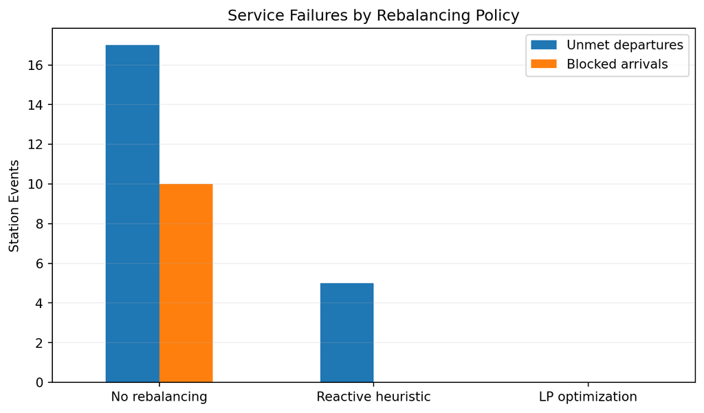

```python
service_failure_plot = (
    policy_comparison
    .set_index(
        "Policy"
    )[
        [
            "Unmet departures",
            "Blocked arrivals",
        ]
    ]
)

ax = service_failure_plot.plot(
    kind="bar",
    figsize=(
        9,
        5,
    ),
)

ax.set_title(
    "Service Failures by Rebalancing Policy"
)

ax.set_xlabel(
    ""
)

ax.set_ylabel(
    "Station Events"
)

ax.tick_params(
    axis="x",
    rotation=0,
)

ax.legend(
    title=""
)

ax.grid(
    axis="y",
    alpha=0.20,
)

plt.show()
```

#### Service Improvement

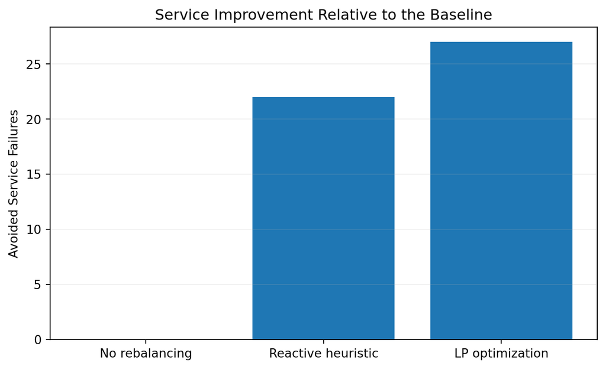

```python
fig, ax = plt.subplots(
    figsize=(
        8,
        4.6,
    )
)

ax.bar(
    policy_comparison[
        "Policy"
    ],
    policy_comparison[
        "Service improvement vs baseline"
    ],
)

ax.axhline(
    0,
    linewidth=1,
)

ax.set_title(
    "Service Improvement Relative to the Baseline"
)

ax.set_xlabel(
    ""
)

ax.set_ylabel(
    "Avoided Service Failures"
)

ax.tick_params(
    axis="x",
    rotation=0,
)

ax.grid(
    axis="y",
    alpha=0.20,
)

plt.show()
```

#### Relocation Effort

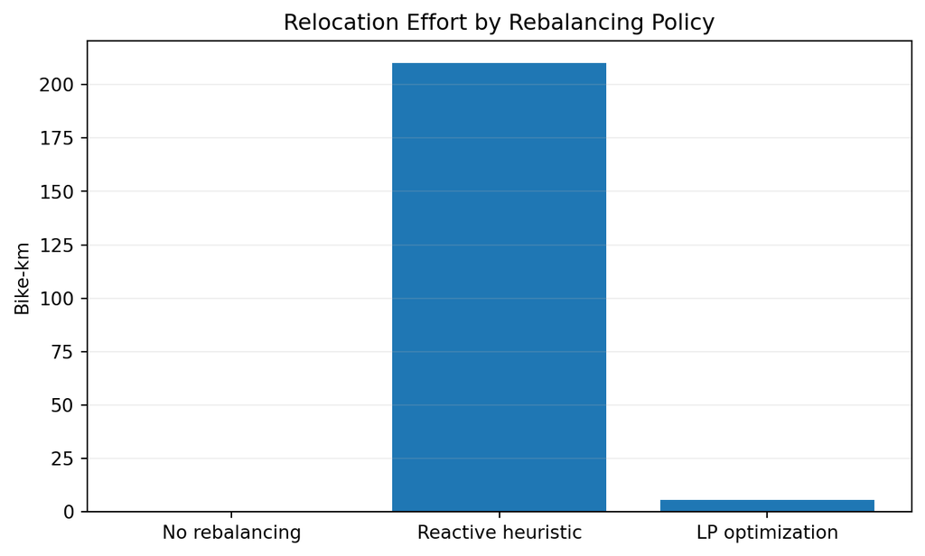

```python
fig, ax = plt.subplots(
    figsize=(
        8,
        4.6,
    )
)

ax.bar(
    policy_comparison[
        "Policy"
    ],
    policy_comparison[
        "Relocation bike-km"
    ],
)

ax.set_title(
    "Relocation Effort by Rebalancing Policy"
)

ax.set_xlabel(
    ""
)

ax.set_ylabel(
    "Bike-km"
)

ax.tick_params(
    axis="x",
    rotation=0,
)

ax.grid(
    axis="y",
    alpha=0.20,
)

plt.show()
```

### 14.13 Major Rebalancing Actions

The full LP solution may contain many station-to-station transfers. The report therefore summarizes the largest relocation corridors, while the complete transfer table is retained for the standalone interactive application.

```python
if len(
    optimized_transfers
) > 0:

    transfer_corridors = (
        optimized_transfers
        .groupby(
            [
                "from_short_name",
                "to_short_name",
                "from_station",
                "to_station",
                "from_lat",
                "from_lon",
                "to_lat",
                "to_lon",
            ],
            as_index=False,
        )
        .agg(
            bikes=(
                "bikes",
                "sum",
            ),

            bike_km=(
                "bike_km",
                "sum",
            ),

            distance_km=(
                "distance_km",
                "first",
            ),

            active_intervals=(
                "time",
                "nunique",
            ),
        )
    )

    transfer_corridors[
        "corridor"
    ] = (
        transfer_corridors[
            "from_station"
        ]
        +
        " → "
        +
        transfer_corridors[
            "to_station"
        ]
    )

    transfer_corridors = (
        transfer_corridors
        .sort_values(
            "bikes",
            ascending=False,
        )
        .reset_index(
            drop=True
        )
    )

else:

    transfer_corridors = pd.DataFrame(
        columns=[
            "from_short_name",
            "to_short_name",
            "from_station",
            "to_station",
            "from_lat",
            "from_lon",
            "to_lat",
            "to_lon",
            "bikes",
            "bike_km",
            "distance_km",
            "active_intervals",
            "corridor",
        ]
    )
```

```python
top_transfer_corridors = (
    transfer_corridors
    .head(
        15
    )
    .copy()
)

top_transfer_corridors[
    [
        "corridor",
        "bikes",
        "distance_km",
        "bike_km",
        "active_intervals",
    ]
].round(
    {
        "bikes": 2,
        "distance_km": 3,
        "bike_km": 3,
    }
)
```

|  | corridor | bikes | distance_km | bike_km | active_intervals |
| --- | --- | --- | --- | --- | --- |
| 0 | 15th & P St NW → 14th St & Rhode Island Ave NW | 4.0 | 0.227 | 0.909 | 2 |
| 1 | 21st & I St NW → 21st St & Pennsylvania Ave NW | 4.0 | 0.093 | 0.371 | 1 |
| 2 | Rhode Island & Connecticut Ave NW → 17th St & ... | 3.0 | 0.133 | 0.399 | 1 |
| 3 | California St & Florida Ave NW → 18th St & Wyo... | 3.0 | 0.169 | 0.506 | 1 |
| 4 | 19th & G St NW → 18th St & Pennsylvania Ave NW | 3.0 | 0.200 | 0.601 | 1 |
| 5 | 14th & R St NW → 14th & Q St NW | 2.0 | 0.264 | 0.528 | 1 |
| 6 | 17th & G St NW → 18th St & Pennsylvania Ave NW | 2.0 | 0.225 | 0.449 | 1 |
| 7 | 21st & E St NW → 23rd & E St NW | 2.0 | 0.283 | 0.565 | 1 |
| 8 | California St & Florida Ave NW → New Hampshire... | 1.0 | 0.321 | 0.321 | 1 |
| 9 | 34th St & Wisconsin Ave NW → Reservoir Rd & 38... | 1.0 | 0.680 | 0.680 | 1 |
| 10 | 17th St & Massachusetts Ave NW → 17th St & Rho... | 1.0 | 0.175 | 0.175 | 1 |
| 11 | 19th & I St NW → 19th St & Pennsylvania Ave NW | 1.0 | 0.154 | 0.154 | 1 |

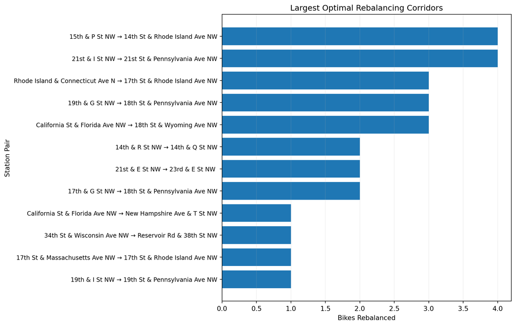

```python
if len(
    top_transfer_corridors
) > 0:

    transfer_plot_data = (
        top_transfer_corridors
        .sort_values(
            "bikes",
            ascending=True,
        )
        .copy()
    )

    transfer_plot_data[
        "corridor_label"
    ] = (
        transfer_plot_data[
            "from_station"
        ]
        .str.slice(
            0,
            32,
        )
        +
        " → "
        +
        transfer_plot_data[
            "to_station"
        ]
        .str.slice(
            0,
            32,
        )
    )

    fig, ax = plt.subplots(
        figsize=(
            11,
            7,
        )
    )

    ax.barh(
        transfer_plot_data[
            "corridor_label"
        ],
        transfer_plot_data[
            "bikes"
        ],
    )

    ax.set_title(
        "Largest Optimal Rebalancing Corridors"
    )

    ax.set_xlabel(
        "Bikes Rebalanced"
    )

    ax.set_ylabel(
        "Station Pair"
    )

    ax.tick_params(
        axis="y",
        labelsize=9,
    )

    ax.grid(
        axis="x",
        alpha=0.20,
    )

    plt.tight_layout()
    plt.show()

else:

    print(
        "The optimal solution contains no "
        "positive station-to-station transfers."
    )
```

#### Hourly Rebalancing Resource Use

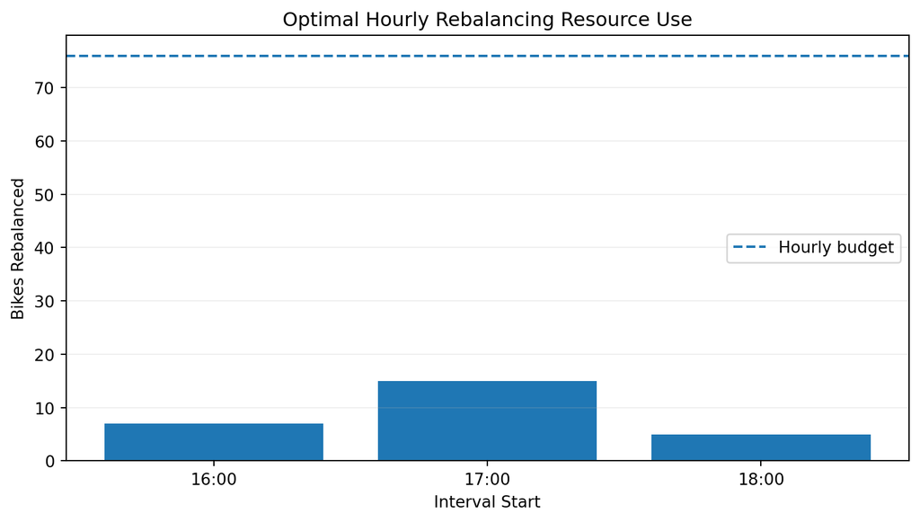

```python
fig, ax = plt.subplots(
    figsize=(
        8,
        4.6,
    )
)

ax.bar(
    hourly_rebalancing[
        "time"
    ]
    .dt.strftime(
        "%H:%M"
    ),
    hourly_rebalancing[
        "bikes"
    ],
)

ax.axhline(
    optimization_budget_per_hour,
    linestyle="--",
    label="Hourly budget",
)

ax.set_title(
    "Optimal Hourly Rebalancing Resource Use"
)

ax.set_xlabel(
    "Interval Start"
)

ax.set_ylabel(
    "Bikes Rebalanced"
)

ax.legend()

ax.grid(
    axis="y",
    alpha=0.20,
)

plt.tight_layout()
plt.show()
```

### 14.14 Optimization Result Map

The report map displays the largest optimized relocation corridors. Arrow direction represents the movement of bikes between stations, while marker color summarizes each station’s net rebalancing role.

```python
map_transfer_corridors = (
    transfer_corridors
    .head(
        12
    )
    .copy()
)
```

```python
if len(
    map_transfer_corridors
) > 0:

    outbound_map_stations = (
        map_transfer_corridors[
            [
                "from_short_name",
                "from_station",
                "from_lat",
                "from_lon",
                "bikes",
            ]
        ]
        .rename(
            columns={
                "from_short_name":
                    "short_name",

                "from_station":
                    "station_name",

                "from_lat":
                    "lat",

                "from_lon":
                    "lon",

                "bikes":
                    "outbound_bikes",
            }
        )
        .copy()
    )

    outbound_map_stations[
        "inbound_bikes"
    ] = 0.0

    inbound_map_stations = (
        map_transfer_corridors[
            [
                "to_short_name",
                "to_station",
                "to_lat",
                "to_lon",
                "bikes",
            ]
        ]
        .rename(
            columns={
                "to_short_name":
                    "short_name",

                "to_station":
                    "station_name",

                "to_lat":
                    "lat",

                "to_lon":
                    "lon",

                "bikes":
                    "inbound_bikes",
            }
        )
        .copy()
    )

    inbound_map_stations[
        "outbound_bikes"
    ] = 0.0

    map_station_summary = (
        pd.concat(
            [
                outbound_map_stations,
                inbound_map_stations,
            ],
            ignore_index=True,
        )
        .groupby(
            [
                "short_name",
                "station_name",
                "lat",
                "lon",
            ],
            as_index=False,
        )[
            [
                "outbound_bikes",
                "inbound_bikes",
            ]
        ]
        .sum()
    )

    map_station_summary[
        "net_rebalance"
    ] = (
        map_station_summary[
            "inbound_bikes"
        ]
        -
        map_station_summary[
            "outbound_bikes"
        ]
    )

    map_station_summary[
        "total_rebalance"
    ] = (
        map_station_summary[
            "inbound_bikes"
        ]
        +
        map_station_summary[
            "outbound_bikes"
        ]
    )

else:

    map_station_summary = pd.DataFrame(
        columns=[
            "short_name",
            "station_name",
            "lat",
            "lon",
            "outbound_bikes",
            "inbound_bikes",
            "net_rebalance",
            "total_rebalance",
        ]
    )
```

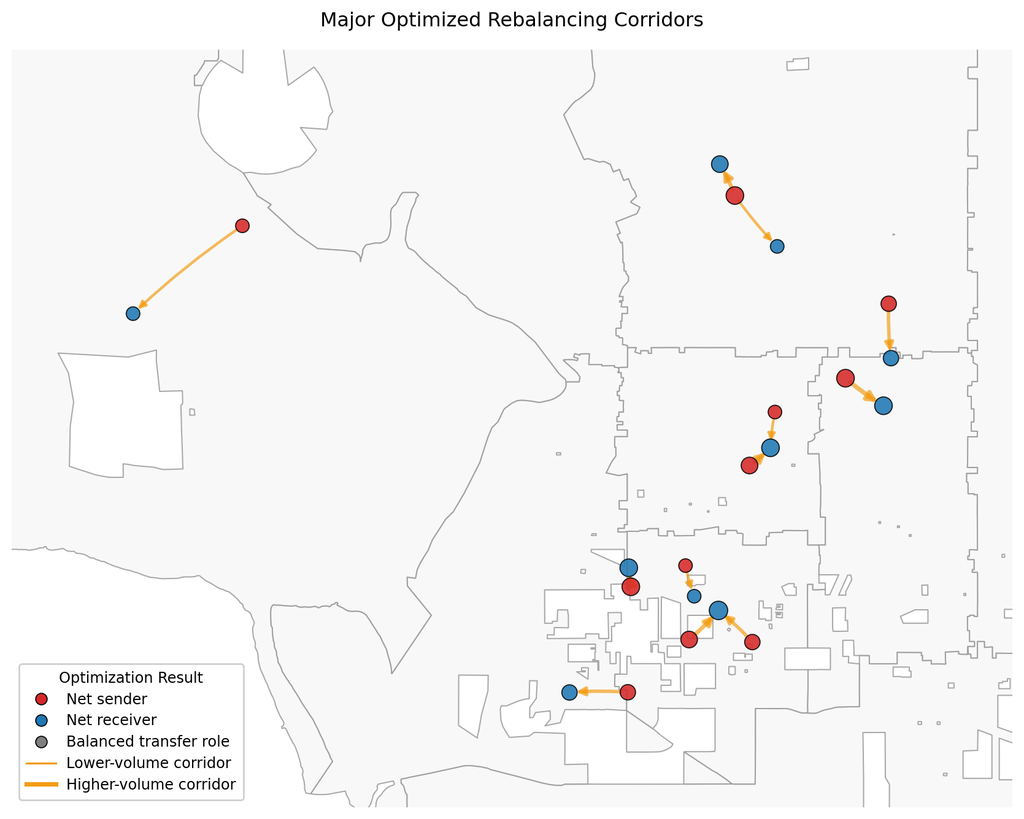

```python
from matplotlib.lines import Line2D
from matplotlib.patches import FancyArrowPatch

optimization_zip_polygons = (
    zip_analysis_gdf[
        [
            "ZIP_CODE",
            "geometry",
        ]
    ]
    .to_crs(
        "EPSG:4326"
    )
    .copy()
)

fig, ax = plt.subplots(
    figsize=(
        9,
        7,
    )
)

# ZIP-code boundaries provide geographic context.
optimization_zip_polygons.plot(
    ax=ax,
    facecolor="#f7f7f7",
    edgecolor="#9a9a9a",
    linewidth=0.75,
    alpha=0.85,
    zorder=1,
)

if len(
    map_transfer_corridors
) > 0:

    max_transfer = max(
        map_transfer_corridors[
            "bikes"
        ].max(),
        1,
    )

    # Draw the largest optimized transfer corridors.
    for _, row in (
        map_transfer_corridors
        .iterrows()
    ):

        transfer_scale = np.sqrt(
            row[
                "bikes"
            ]
            /
            max_transfer
        )

        line_width = (
            0.7
            +
            2.0
            *
            transfer_scale
        )

        arrow_size = (
            6
            +
            6
            *
            transfer_scale
        )

        transfer_arrow = FancyArrowPatch(
            posA=(
                row[
                    "from_lon"
                ],
                row[
                    "from_lat"
                ],
            ),

            posB=(
                row[
                    "to_lon"
                ],
                row[
                    "to_lat"
                ],
            ),

            arrowstyle=
                "-|>",

            mutation_scale=
                arrow_size,

            linewidth=
                line_width,

            color=
                "#f39c12",

            alpha=
                0.68,

            shrinkA=
                4,

            shrinkB=
                4,

            connectionstyle=
                "arc3,rad=0.04",

            zorder=
                2,
        )

        ax.add_patch(
            transfer_arrow
        )

    role_tolerance = 1e-9

    sender_stations = (
        map_station_summary.loc[
            map_station_summary[
                "net_rebalance"
            ]
            <
            -role_tolerance
        ]
        .copy()
    )

    receiver_stations = (
        map_station_summary.loc[
            map_station_summary[
                "net_rebalance"
            ]
            >
            role_tolerance
        ]
        .copy()
    )

    balanced_stations = (
        map_station_summary.loc[
            map_station_summary[
                "net_rebalance"
            ]
            .abs()
            <=
            role_tolerance
        ]
        .copy()
    )

    max_station_activity = max(
        map_station_summary[
            "total_rebalance"
        ].max(),
        1,
    )

    def station_marker_sizes(
        activity
    ):

        return (
            22
            +
            105
            *
            np.sqrt(
                activity
                /
                max_station_activity
            )
        )

    # Stations that send more bikes than they receive.
    if len(
        sender_stations
    ) > 0:

        ax.scatter(
            sender_stations[
                "lon"
            ],
            sender_stations[
                "lat"
            ],

            s=station_marker_sizes(
                sender_stations[
                    "total_rebalance"
                ]
            ),

            c="#d62728",
            edgecolors="black",
            linewidths=0.65,
            alpha=0.88,
            zorder=3,
        )

    # Stations that receive more bikes than they send.
    if len(
        receiver_stations
    ) > 0:

        ax.scatter(
            receiver_stations[
                "lon"
            ],
            receiver_stations[
                "lat"
            ],

            s=station_marker_sizes(
                receiver_stations[
                    "total_rebalance"
                ]
            ),

            c="#1f77b4",
            edgecolors="black",
            linewidths=0.65,
            alpha=0.88,
            zorder=3,
        )

    # Stations with approximately equal
    # inbound and outbound activity.
    if len(
        balanced_stations
    ) > 0:

        ax.scatter(
            balanced_stations[
                "lon"
            ],
            balanced_stations[
                "lat"
            ],

            s=station_marker_sizes(
                balanced_stations[
                    "total_rebalance"
                ]
            ),

            c="#7f7f7f",
            edgecolors="black",
            linewidths=0.65,
            alpha=0.78,
            zorder=3,
        )

    # Focus on the transfer endpoints rather
    # than the entire regional ZIP layer.
    transfer_longitudes = pd.concat(
        [
            map_transfer_corridors[
                "from_lon"
            ],
            map_transfer_corridors[
                "to_lon"
            ],
        ],
        ignore_index=True,
    )

    transfer_latitudes = pd.concat(
        [
            map_transfer_corridors[
                "from_lat"
            ],
            map_transfer_corridors[
                "to_lat"
            ],
        ],
        ignore_index=True,
    )

    xmin = (
        transfer_longitudes
        .min()
    )

    xmax = (
        transfer_longitudes
        .max()
    )

    ymin = (
        transfer_latitudes
        .min()
    )

    ymax = (
        transfer_latitudes
        .max()
    )

else:

    xmin, ymin, xmax, ymax = (
        optimization_zip_polygons
        .total_bounds
    )

x_span = max(
    xmax - xmin,
    0.020,
)

y_span = max(
    ymax - ymin,
    0.020,
)

x_pad = max(
    0.005,
    0.16
    *
    x_span,
)

y_pad = max(
    0.005,
    0.16
    *
    y_span,
)

ax.set_xlim(
    xmin - x_pad,
    xmax + x_pad,
)

ax.set_ylim(
    ymin - y_pad,
    ymax + y_pad,
)

# Correct approximate longitude-latitude distortion.
mean_latitude = (
    ymin + ymax
) / 2

ax.set_aspect(
    1
    /
    np.cos(
        np.deg2rad(
            mean_latitude
        )
    )
)

ax.set_title(
    "Major Optimized Rebalancing Corridors",
    pad=14,
)

ax.set_axis_off()

legend_handles = [
    Line2D(
        [0],
        [0],

        marker="o",
        linestyle="none",

        markerfacecolor=
            "#d62728",

        markeredgecolor=
            "black",

        markeredgewidth=
            0.65,

        markersize=
            7,

        label=
            "Net sender",
    ),

    Line2D(
        [0],
        [0],

        marker="o",
        linestyle="none",

        markerfacecolor=
            "#1f77b4",

        markeredgecolor=
            "black",

        markeredgewidth=
            0.65,

        markersize=
            7,

        label=
            "Net receiver",
    ),

    Line2D(
        [0],
        [0],

        marker="o",
        linestyle="none",

        markerfacecolor=
            "#7f7f7f",

        markeredgecolor=
            "black",

        markeredgewidth=
            0.65,

        markersize=
            7,

        label=
            "Balanced transfer role",
    ),

    Line2D(
        [0],
        [0],

        color=
            "#f39c12",

        linewidth=
            1.2,

        label=
            "Lower-volume corridor",
    ),

    Line2D(
        [0],
        [0],

        color=
            "#f39c12",

        linewidth=
            2.7,

        label=
            "Higher-volume corridor",
    ),
]

ax.legend(
    handles=
        legend_handles,

    title=
        "Optimization Result",

    loc=
        "lower left",

    frameon=
        True,

    framealpha=
        0.96,

    borderpad=
        0.5,

    labelspacing=
        0.45,

    handletextpad=
        0.7,

    fontsize=
        9,

    title_fontsize=
        9,
)

plt.tight_layout()
plt.show()
```

### 14.15 Preserve Constraint Information for Dual Analysis

```python
eq_constraint_results = (
    pd.DataFrame(
        eq_constraint_metadata
    )
)

eq_constraint_results[
    "residual"
] = (
    lp_result.eqlin.residual
)

eq_constraint_results[
    "marginal"
] = (
    lp_result.eqlin.marginals
)
```

```python
ub_constraint_results = (
    pd.DataFrame(
        ub_constraint_metadata
    )
)

ub_constraint_results[
    "slack"
] = (
    lp_result.ineqlin.residual
)

ub_constraint_results[
    "marginal"
] = (
    lp_result.ineqlin.marginals
)
```

```python
binding_constraint_summary = (
    ub_constraint_results
    .assign(
        binding=
            ub_constraint_results[
                "slack"
            ]
            .abs()
            < 1e-7
    )
    .groupby(
        "category",
        as_index=False,
    )
    .agg(
        constraints=(
            "row",
            "count",
        ),
        binding_constraints=(
            "binding",
            "sum",
        ),
    )
)

binding_constraint_summary
```

|  | category | constraints | binding_constraints |
| --- | --- | --- | --- |
| 0 | arrival_dock_capacity | 1131 | 4 |
| 1 | departure_inventory | 1131 | 14 |
| 2 | outgoing_bike_availability | 1131 | 0 |
| 3 | post_rebalancing_capacity | 1131 | 0 |
| 4 | rebalancing_budget | 3 | 0 |

Detailed dual interpretation is deferred to Part 15.

### 14.16 Save the Optimization Outputs

```python
optimized_simulation.to_csv(
    processed_dir
    / "optimized_inventory_simulation.csv",
    index=False,
)

optimized_transfers.to_csv(
    processed_dir
    / "optimized_rebalancing_transfers.csv",
    index=False,
)

policy_comparison.to_csv(
    processed_dir
    / "policy_comparison.csv",
    index=False,
)

candidate_edges.to_csv(
    processed_dir
    / "optimization_candidate_edges.csv",
    index=False,
)

hourly_rebalancing.to_csv(
    processed_dir
    / "optimized_hourly_rebalancing.csv",
    index=False,
)

eq_constraint_results.to_csv(
    processed_dir
    / "lp_equality_constraints.csv",
    index=False,
)

ub_constraint_results.to_csv(
    processed_dir
    / "lp_inequality_constraints.csv",
    index=False,
)
```

```python
print(
    "LP objective:",
    round(
        lp_result.fun,
        3,
    )
)

print(
    "Total service failures:",
    round(
        optimized_policy_summary[
            "Total service failures"
        ],
        3,
    )
)

print(
    "Bikes rebalanced:",
    round(
        optimized_policy_summary[
            "Bikes rebalanced"
        ],
        3,
    )
)

print(
    "Relocation bike-km:",
    round(
        optimized_bike_km,
        3,
    )
)

print(
    "Binding inequality constraints:",
    int(
        (
            ub_constraint_results[
                "slack"
            ]
            .abs()
            < 1e-7
        )
        .sum()
    ),
)
```

```
LP objective: 5.657
Total service failures: 0.0
Bikes rebalanced: 27.0
Relocation bike-km: 5.657
Binding inequality constraints: 18
```

The LP solution is a planning benchmark. Transfer variables are continuous, straight-line distance is used as a relocation-cost proxy, and explicit truck routing is not modeled.

## Part 15 — Optimization Results, Duality, and Sensitivity Analysis

Dual variables measure the local change in the optimal objective value when a constraint is relaxed.

For an inequality constraint

$$a_j^\top z
\leq
b_j,$$

SciPy reports

$$\frac{\partial z^*}{\partial b_j}$$

as the constraint marginal. For a resource constraint, the corresponding nonnegative resource value is reported as

$$-\text{marginal}.$$

A binding constraint does not necessarily have a positive shadow value because degeneracy may produce binding constraints with zero marginal value.

### 15.1 Final Optimization Performance

```python
optimization_performance = (
    policy_comparison[
        [
            "Policy",
            "Unmet departures",
            "Blocked arrivals",
            "Total service failures",
            "Service success rate",
            "Bikes rebalanced",
            "Relocation bike-km",
            "Service improvement vs baseline",
        ]
    ]
    .copy()
)

optimization_performance[
    "Service success rate"
] = (
    100
    * optimization_performance[
        "Service success rate"
    ]
)

optimization_performance = (
    optimization_performance
    .rename(
        columns={
            "Service success rate":
                "Station-event success rate (%)"
        }
    )
)

(
    optimization_performance
    .round(3)
    .style
    .hide(axis="index")
)
```

| Policy | Unmet departures | Blocked arrivals | Total service failures | Station-event success rate (%) | Bikes rebalanced | Relocation bike-km | Service improvement vs baseline |
| --- | --- | --- | --- | --- | --- | --- | --- |
| No rebalancing | 17.000000 | 10.000000 | 27.000000 | 99.235000 | 0.000000 | 0.000000 | 0.000000 |
| Reactive heuristic | 5.000000 | 0.000000 | 5.000000 | 99.858000 | 84.000000 | 209.974000 | 22.000000 |
| LP optimization | 0.000000 | 0.000000 | 0.000000 | 100.000000 | 27.000000 | 5.657000 | 27.000000 |

### 15.2 Binding Constraint Summary

```python
dual_tolerance = 1e-7

constraint_labels = {
    "outgoing_bike_availability":
        "Outgoing bike availability",

    "post_rebalancing_capacity":
        "Post-rebalancing station capacity",

    "departure_inventory":
        "Departure inventory availability",

    "arrival_dock_capacity":
        "Arrival dock capacity",

    "rebalancing_budget":
        "Hourly rebalancing budget",
}
```

```python
ub_dual_analysis = (
    ub_constraint_results
    .copy()
)

ub_dual_analysis[
    "binding"
] = (
    ub_dual_analysis[
        "slack"
    ]
    .abs()
    <= dual_tolerance
)

ub_dual_analysis[
    "shadow_value"
] = (
    -ub_dual_analysis[
        "marginal"
    ]
)

ub_dual_analysis.loc[
    ub_dual_analysis[
        "shadow_value"
    ]
    .abs()
    < dual_tolerance,
    "shadow_value",
] = 0.0

ub_dual_analysis[
    "constraint"
] = (
    ub_dual_analysis[
        "category"
    ]
    .map(
        constraint_labels
    )
    .fillna(
        ub_dual_analysis[
            "category"
        ]
    )
)
```

```python
constraint_dual_summary = (
    ub_dual_analysis
    .groupby(
        [
            "category",
            "constraint",
        ],
        as_index=False,
    )
    .agg(
        constraints=(
            "row",
            "count",
        ),

        binding_constraints=(
            "binding",
            "sum",
        ),

        positive_shadow_constraints=(
            "shadow_value",
            lambda x:
                (
                    x
                    > dual_tolerance
                )
                .sum(),
        ),

        maximum_shadow_value=(
            "shadow_value",
            "max",
        ),

        total_shadow_value=(
            "shadow_value",
            "sum",
        ),
    )
)

constraint_dual_summary[
    "binding_rate"
] = (
    constraint_dual_summary[
        "binding_constraints"
    ]
    /
    constraint_dual_summary[
        "constraints"
    ]
)

constraint_dual_display = (
    constraint_dual_summary[
        [
            "constraint",
            "constraints",
            "binding_constraints",
            "binding_rate",
            "positive_shadow_constraints",
            "maximum_shadow_value",
        ]
    ]
    .rename(
        columns={
            "constraint":
                "Constraint",

            "constraints":
                "Rows",

            "binding_constraints":
                "Binding rows",

            "binding_rate":
                "Binding rate",

            "positive_shadow_constraints":
                "Positive shadow rows",

            "maximum_shadow_value":
                "Maximum shadow value",
        }
    )
)

(
    constraint_dual_display
    .round(4)
    .style
    .hide(axis="index")
)
```

| Constraint | Rows | Binding rows | Binding rate | Positive shadow rows | Maximum shadow value |
| --- | --- | --- | --- | --- | --- |
| Arrival dock capacity | 1131 | 4 | 0.003500 | 0 | 0.000000 |
| Departure inventory availability | 1131 | 14 | 0.012400 | 7 | 0.679600 |
| Outgoing bike availability | 1131 | 0 | 0.000000 | 0 | 0.000000 |
| Post-rebalancing station capacity | 1131 | 0 | 0.000000 | 0 | 0.000000 |
| Hourly rebalancing budget | 3 | 0 | 0.000000 | 0 | 0.000000 |

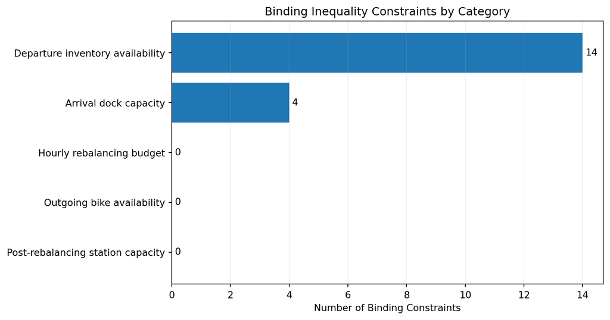

```python
binding_plot_data = (
    constraint_dual_summary
    .sort_values(
        "binding_constraints"
    )
)

fig, ax = plt.subplots(
    figsize=(
        9,
        4.8,
    )
)

binding_bars = ax.barh(
    binding_plot_data[
        "constraint"
    ],
    binding_plot_data[
        "binding_constraints"
    ],
)

ax.bar_label(
    binding_bars,
    fmt="%.0f",
    padding=3,
)

ax.set_title(
    "Binding Inequality Constraints by Category"
)

ax.set_xlabel(
    "Number of Binding Constraints"
)

ax.set_ylabel(
    ""
)

ax.set_xlim(
    left=0
)

ax.grid(
    axis="x",
    alpha=0.20,
)

plt.tight_layout()
plt.show()
```

### 15.3 Shadow Prices at the Current Solution

The shadow value reports the local objective improvement associated with one additional unit of the corresponding resource.

#### Hourly Rebalancing Budget

```python
budget_shadow_prices = (
    ub_dual_analysis.loc[
        ub_dual_analysis[
            "category"
        ]
        == "rebalancing_budget",
        [
            "time",
            "rhs",
            "slack",
            "binding",
            "marginal",
            "shadow_value",
        ],
    ]
    .copy()
    .reset_index(
        drop=True
    )
)

budget_shadow_prices[
    "time"
] = (
    pd.to_datetime(
        budget_shadow_prices[
            "time"
        ]
    )
)

budget_shadow_prices[
    "interval"
] = (
    budget_shadow_prices[
        "time"
    ]
    .dt.strftime(
        "%H:%M"
    )
)

budget_shadow_prices_display = (
    budget_shadow_prices[
        [
            "interval",
            "rhs",
            "slack",
            "binding",
            "marginal",
            "shadow_value",
        ]
    ]
    .rename(
        columns={
            "interval":
                "Interval",

            "rhs":
                "Hourly budget",

            "slack":
                "Unused budget",

            "binding":
                "Binding",

            "marginal":
                "SciPy marginal",

            "shadow_value":
                "Shadow value",
        }
    )
)

(
    budget_shadow_prices_display
    .round(5)
    .style
    .hide(axis="index")
)
```

| Interval | Hourly budget | Unused budget | Binding | SciPy marginal | Shadow value |
| --- | --- | --- | --- | --- | --- |
| 16:00 | 76.000000 | 69.000000 | False | -0.000000 | 0.000000 |
| 17:00 | 76.000000 | 61.000000 | False | -0.000000 | 0.000000 |
| 18:00 | 76.000000 | 71.000000 | False | -0.000000 | 0.000000 |

#### Station-Level Resource Values

```python
station_name_lookup = (
    optimization_station_table
    .set_index(
        "short_name"
    )[
        "station_name"
    ]
    .to_dict()
)
```

```python
top_shadow_constraints = (
    ub_dual_analysis.loc[
        ub_dual_analysis[
            "binding"
        ]
        &
        (
            ub_dual_analysis[
                "shadow_value"
            ]
            > dual_tolerance
        )
        &
        ub_dual_analysis[
            "short_name"
        ]
        .notna()
    ]
    .copy()
)

top_shadow_constraints[
    "station_name"
] = (
    top_shadow_constraints[
        "short_name"
    ]
    .map(
        station_name_lookup
    )
    .fillna(
        top_shadow_constraints[
            "short_name"
        ]
        .astype(str)
    )
)

top_shadow_constraints[
    "time"
] = (
    pd.to_datetime(
        top_shadow_constraints[
            "time"
        ]
    )
)

top_shadow_constraints[
    "interval"
] = (
    top_shadow_constraints[
        "time"
    ]
    .dt.strftime(
        "%H:%M"
    )
)

top_shadow_constraints[
    "constraint_label"
] = (
    top_shadow_constraints[
        "category"
    ]
    .map(
        constraint_labels
    )
    .fillna(
        top_shadow_constraints[
            "category"
        ]
    )
)

top_shadow_constraints[
    "display_label"
] = (
    top_shadow_constraints[
        "interval"
    ]
    +
    " | "
    +
    top_shadow_constraints[
        "station_name"
    ]
    +
    " | "
    +
    top_shadow_constraints[
        "constraint_label"
    ]
)

top_shadow_constraints = (
    top_shadow_constraints
    .nlargest(
        15,
        "shadow_value",
    )
    .reset_index(
        drop=True
    )
)
```

```python
top_shadow_display = (
    top_shadow_constraints[
        [
            "interval",
            "station_name",
            "constraint_label",
            "slack",
            "shadow_value",
        ]
    ]
    .rename(
        columns={
            "interval":
                "Interval",

            "station_name":
                "Station",

            "constraint_label":
                "Constraint",

            "slack":
                "Slack",

            "shadow_value":
                "Shadow value",
        }
    )
)

(
    top_shadow_display
    .round(5)
    .style
    .hide(axis="index")
)
```

| Interval | Station | Constraint | Slack | Shadow value |
| --- | --- | --- | --- | --- |
| 17:00 | Reservoir Rd & 38th St NW | Departure inventory availability | 0.000000 | 0.679580 |
| 17:00 | 23rd & E St NW | Departure inventory availability | 0.000000 | 0.282740 |
| 18:00 | 18th St & Pennsylvania Ave NW | Departure inventory availability | 0.000000 | 0.224570 |
| 18:00 | 17th St & Rhode Island Ave NW | Departure inventory availability | 0.000000 | 0.174690 |
| 18:00 | 21st St & Pennsylvania Ave NW | Departure inventory availability | 0.000000 | 0.092650 |
| 18:00 | Rhode Island & Connecticut Ave NW | Departure inventory availability | 0.000000 | 0.041690 |
| 18:00 | 19th & G St NW | Departure inventory availability | 0.000000 | 0.024340 |

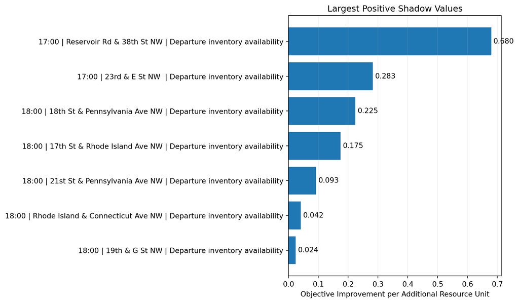

```python
if len(
    top_shadow_constraints
) > 0:

    shadow_plot_data = (
        top_shadow_constraints
        .sort_values(
            "shadow_value"
        )
    )

    fig, ax = plt.subplots(
        figsize=(
            10,
            6,
        )
    )

    shadow_bars = ax.barh(
        shadow_plot_data[
            "display_label"
        ],
        shadow_plot_data[
            "shadow_value"
        ],
    )

    ax.bar_label(
        shadow_bars,
        fmt="%.3f",
        padding=3,
    )

    ax.set_title(
        "Largest Positive Shadow Values"
    )

    ax.set_xlabel(
        "Objective Improvement per Additional Resource Unit"
    )

    ax.set_ylabel(
        ""
    )

    ax.set_xlim(
        left=0
    )

    ax.grid(
        axis="x",
        alpha=0.20,
    )

    plt.tight_layout()
    plt.show()

else:

    print(
        "No binding inequality constraint "
        "has a positive shadow value at the current solution."
    )
```

### 15.4 LP Sensitivity Solver

The following helper re-solves the same LP after changing the hourly rebalancing budget, service-failure penalty, or station capacity.

```python
budget_constraint_rows = (
    ub_constraint_results.loc[
        ub_constraint_results[
            "category"
        ]
        == "rebalancing_budget",
        "row",
    ]
    .astype(int)
    .to_numpy()
)

station_position = {
    station_id: i
    for i, station_id
    in enumerate(
        station_ids
    )
}
```

```python
def solve_lp_variant(
    hourly_budget=None,
    failure_penalty=None,
    capacity_changes=None,
):

    variant_objective = (
        objective_coefficients
        .copy()
    )

    variant_b_ub = (
        b_ub.copy()
    )

    variant_bounds = list(
        bounds
    )

    if failure_penalty is None:
        failure_penalty = (
            service_failure_penalty
        )

    variant_objective[
        offset_unmet_departures:
        offset_blocked_arrivals
    ] = float(
        failure_penalty
    )

    variant_objective[
        offset_blocked_arrivals:
    ] = float(
        failure_penalty
    )

    if hourly_budget is not None:

        if np.isscalar(
            hourly_budget
        ):

            budget_values = np.full(
                len(
                    budget_constraint_rows
                ),
                float(
                    hourly_budget
                ),
            )

        else:

            budget_values = np.asarray(
                hourly_budget,
                dtype=float,
            )

            if len(
                budget_values
            ) != len(
                budget_constraint_rows
            ):

                raise ValueError(
                    "The hourly-budget vector must "
                    "match the number of time intervals."
                )

        variant_b_ub[
            budget_constraint_rows
        ] = budget_values

    if capacity_changes is not None:

        capacity_categories = [
            "post_rebalancing_capacity",
            "arrival_dock_capacity",
        ]

        for (
            station_id,
            capacity_delta,
        ) in capacity_changes.items():

            if station_id not in station_position:

                raise KeyError(
                    f"Unknown station: {station_id}"
                )

            capacity_delta = float(
                capacity_delta
            )

            if capacity_delta < 0:

                raise ValueError(
                    "Part 15 capacity sensitivity "
                    "uses nonnegative capacity changes."
                )

            i = station_position[
                station_id
            ]

            for k in range(
                1,
                time_count + 1,
            ):

                variable_index = idx_s(
                    k,
                    i,
                )

                lower_bound, upper_bound = (
                    variant_bounds[
                        variable_index
                    ]
                )

                if upper_bound is None:

                    raise ValueError(
                        "The inventory upper bound is missing."
                    )

                variant_bounds[
                    variable_index
                ] = (
                    lower_bound,
                    float(
                        upper_bound
                    )
                    +
                    capacity_delta,
                )

            station_capacity_rows = (
                ub_constraint_results.loc[
                    ub_constraint_results[
                        "category"
                    ]
                    .isin(
                        capacity_categories
                    )
                    &
                    (
                        ub_constraint_results[
                            "short_name"
                        ]
                        == station_id
                    ),
                    "row",
                ]
                .astype(int)
                .to_numpy()
            )

            variant_b_ub[
                station_capacity_rows
            ] += capacity_delta

    return linprog(
        c=
            variant_objective,

        A_ub=
            A_ub,

        b_ub=
            variant_b_ub,

        A_eq=
            A_eq,

        b_eq=
            b_eq,

        bounds=
            variant_bounds,

        method=
            "highs",
    )
```

```python
requested_event_total = (
    requested_departures.sum()
    +
    requested_arrivals.sum()
)


def extract_lp_metrics(
    result,
    failure_penalty,
):

    if not result.success:

        return {
            "success":
                False,

            "status":
                result.status,

            "message":
                result.message,
        }

    result_x = (
        result.x[
            offset_x:
            offset_s
        ]
        .reshape(
            (
                time_count,
                edge_count,
            )
        )
    )

    unmet_departures = (
        result.x[
            offset_unmet_departures:
            offset_blocked_arrivals
        ]
        .sum()
    )

    blocked_arrivals = (
        result.x[
            offset_blocked_arrivals:
        ]
        .sum()
    )

    total_service_failures = (
        unmet_departures
        +
        blocked_arrivals
    )

    bikes_rebalanced = (
        result_x.sum()
    )

    relocation_bike_km = (
        result_x
        *
        edge_distances[
            None,
            :
        ]
    ).sum()

    relocation_cost = (
        relocation_cost_weight
        *
        relocation_bike_km
    )

    service_failure_cost = (
        float(
            failure_penalty
        )
        *
        total_service_failures
    )

    station_event_success_rate = (
        1
        -
        total_service_failures
        /
        requested_event_total
    )

    return {
        "success":
            True,

        "status":
            result.status,

        "objective_value":
            result.fun,

        "unmet_departures":
            unmet_departures,

        "blocked_arrivals":
            blocked_arrivals,

        "total_service_failures":
            total_service_failures,

        "station_event_success_rate":
            station_event_success_rate,

        "bikes_rebalanced":
            bikes_rebalanced,

        "relocation_bike_km":
            relocation_bike_km,

        "relocation_cost":
            relocation_cost,

        "service_failure_cost":
            service_failure_cost,

        "objective_reconstruction_error":
            abs(
                result.fun
                -
                (
                    relocation_cost
                    +
                    service_failure_cost
                )
            ),
    }
```

```python
base_lp_metrics = (
    extract_lp_metrics(
        lp_result,
        service_failure_penalty,
    )
)

base_lp_metrics_display = pd.DataFrame(
    {
        "Measure": [
            "Objective value",
            "Unmet departures",
            "Blocked arrivals",
            "Total service failures",
            "Station-event success rate (%)",
            "Bikes rebalanced",
            "Relocation bike-km",
            "Objective reconstruction error",
        ],

        "Value": [
            base_lp_metrics[
                "objective_value"
            ],

            base_lp_metrics[
                "unmet_departures"
            ],

            base_lp_metrics[
                "blocked_arrivals"
            ],

            base_lp_metrics[
                "total_service_failures"
            ],

            100
            * base_lp_metrics[
                "station_event_success_rate"
            ],

            base_lp_metrics[
                "bikes_rebalanced"
            ],

            base_lp_metrics[
                "relocation_bike_km"
            ],

            base_lp_metrics[
                "objective_reconstruction_error"
            ],
        ],
    }
)

(
    base_lp_metrics_display
    .round(6)
    .style
    .hide(axis="index")
)
```

| Measure | Value |
| --- | --- |
| Objective value | 5.657473 |
| Unmet departures | 0.000000 |
| Blocked arrivals | 0.000000 |
| Total service failures | 0.000000 |
| Station-event success rate (%) | 100.000000 |
| Bikes rebalanced | 27.000000 |
| Relocation bike-km | 5.657473 |
| Objective reconstruction error | 0.000000 |

### 15.5 Rebalancing-Budget Sensitivity

The hourly budget is varied while all other model assumptions remain unchanged.

```python
current_hourly_budget = float(
    optimization_budget_per_hour
)

budget_grid = np.unique(
    np.concatenate(
        [
            np.array(
                [
                    0,
                    2,
                    4,
                    5,
                    6,
                    7,
                    8,
                    10,
                    12,
                    15,
                    20,
                ],
                dtype=float,
            ),

            np.rint(
                current_hourly_budget
                *
                np.array(
                    [
                        0.35,
                        0.50,
                        0.75,
                        1.00,
                        1.25,
                    ]
                )
            )
            .astype(float),

            np.array(
                [
                    current_hourly_budget
                ],
                dtype=float,
            ),
        ]
    )
)

budget_grid = (
    budget_grid[
        budget_grid
        >= 0
    ]
)
```

```python
budget_sensitivity_rows = []

for hourly_budget in (
    budget_grid
):

    result = solve_lp_variant(
        hourly_budget=
            float(
                hourly_budget
            ),

        failure_penalty=
            service_failure_penalty,
    )

    metrics = extract_lp_metrics(
        result,
        service_failure_penalty,
    )

    if result.success:

        binding_budget_intervals = int(
            (
                np.abs(
                    result
                    .ineqlin
                    .residual[
                        budget_constraint_rows
                    ]
                )
                <= dual_tolerance
            )
            .sum()
        )

    else:

        binding_budget_intervals = np.nan

    budget_sensitivity_rows.append(
        {
            "Hourly budget":
                float(
                    hourly_budget
                ),

            "Success":
                metrics[
                    "success"
                ],

            "Objective value":
                metrics.get(
                    "objective_value",
                    np.nan,
                ),

            "Unmet departures":
                metrics.get(
                    "unmet_departures",
                    np.nan,
                ),

            "Blocked arrivals":
                metrics.get(
                    "blocked_arrivals",
                    np.nan,
                ),

            "Total service failures":
                metrics.get(
                    "total_service_failures",
                    np.nan,
                ),

            "Bikes rebalanced":
                metrics.get(
                    "bikes_rebalanced",
                    np.nan,
                ),

            "Relocation bike-km":
                metrics.get(
                    "relocation_bike_km",
                    np.nan,
                ),

            "Binding budget intervals":
                binding_budget_intervals,
        }
    )

budget_sensitivity = (
    pd.DataFrame(
        budget_sensitivity_rows
    )
    .sort_values(
        "Hourly budget"
    )
    .reset_index(
        drop=True
    )
)

(
    budget_sensitivity
    .round(4)
    .style
    .hide(axis="index")
)
```

| Hourly budget | Success | Objective value | Unmet departures | Blocked arrivals | Total service failures | Bikes rebalanced | Relocation bike-km | Binding budget intervals |
| --- | --- | --- | --- | --- | --- | --- | --- | --- |
| 0.000000 | True | 675.000000 | 17.000000 | 10.000000 | 27.000000 | 0.000000 | 0.000000 | 3 |
| 2.000000 | True | 427.168700 | 11.000000 | 6.000000 | 17.000000 | 6.000000 | 2.168700 | 3 |
| 4.000000 | True | 278.014300 | 8.000000 | 3.000000 | 11.000000 | 12.000000 | 3.014300 | 3 |
| 5.000000 | True | 203.615000 | 5.000000 | 3.000000 | 8.000000 | 15.000000 | 3.615000 | 3 |
| 6.000000 | True | 129.328200 | 3.000000 | 2.000000 | 5.000000 | 18.000000 | 4.328200 | 3 |
| 7.000000 | True | 55.157600 | 1.000000 | 1.000000 | 2.000000 | 21.000000 | 5.157600 | 3 |
| 8.000000 | True | 6.022300 | 0.000000 | 0.000000 | 0.000000 | 24.000000 | 6.022300 | 3 |
| 10.000000 | True | 5.657500 | 0.000000 | 0.000000 | 0.000000 | 27.000000 | 5.657500 | 1 |
| 12.000000 | True | 5.657500 | 0.000000 | 0.000000 | 0.000000 | 27.000000 | 5.657500 | 1 |
| 15.000000 | True | 5.657500 | 0.000000 | 0.000000 | 0.000000 | 27.000000 | 5.657500 | 1 |
| 20.000000 | True | 5.657500 | 0.000000 | 0.000000 | 0.000000 | 27.000000 | 5.657500 | 0 |
| 27.000000 | True | 5.657500 | 0.000000 | 0.000000 | 0.000000 | 27.000000 | 5.657500 | 0 |
| 38.000000 | True | 5.657500 | 0.000000 | 0.000000 | 0.000000 | 27.000000 | 5.657500 | 0 |
| 57.000000 | True | 5.657500 | 0.000000 | 0.000000 | 0.000000 | 27.000000 | 5.657500 | 0 |
| 76.000000 | True | 5.657500 | 0.000000 | 0.000000 | 0.000000 | 27.000000 | 5.657500 | 0 |
| 95.000000 | True | 5.657500 | 0.000000 | 0.000000 | 0.000000 | 27.000000 | 5.657500 | 0 |

```python
zero_failure_budget_rows = (
    budget_sensitivity.loc[
        budget_sensitivity[
            "Success"
        ]
        &
        (
            budget_sensitivity[
                "Total service failures"
            ]
            <= dual_tolerance
        )
    ]
)

minimum_zero_failure_budget = (
    zero_failure_budget_rows[
        "Hourly budget"
    ]
    .min()
    if len(
        zero_failure_budget_rows
    ) > 0
    else np.nan
)

objective_tolerance = (
    1e-6
    *
    max(
        1.0,
        abs(
            base_lp_metrics[
                "objective_value"
            ]
        ),
    )
)

objective_matching_budget_rows = (
    budget_sensitivity.loc[
        budget_sensitivity[
            "Success"
        ]
        &
        (
            budget_sensitivity[
                "Objective value"
            ]
            -
            base_lp_metrics[
                "objective_value"
            ]
        )
        .abs()
        .le(
            objective_tolerance
        )
    ]
)

minimum_objective_matching_budget = (
    objective_matching_budget_rows[
        "Hourly budget"
    ]
    .min()
    if len(
        objective_matching_budget_rows
    ) > 0
    else np.nan
)

# Backward-compatible name used in earlier report code.
minimum_matching_budget = (
    minimum_zero_failure_budget
)
```

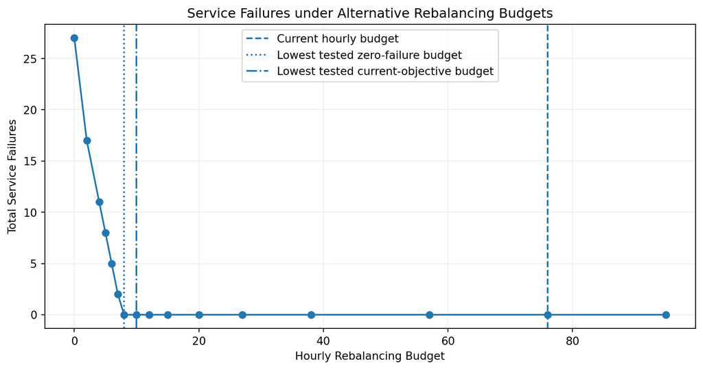

```python
fig, ax = plt.subplots(
    figsize=(
        9,
        4.8,
    )
)

ax.plot(
    budget_sensitivity[
        "Hourly budget"
    ],
    budget_sensitivity[
        "Total service failures"
    ],
    marker="o",
)

ax.axvline(
    current_hourly_budget,
    linestyle="--",
    label="Current hourly budget",
)

if np.isfinite(
    minimum_zero_failure_budget
):

    ax.axvline(
        minimum_zero_failure_budget,
        linestyle=":",
        label="Lowest tested zero-failure budget",
    )

if (
    np.isfinite(
        minimum_objective_matching_budget
    )
    and
    not np.isclose(
        minimum_objective_matching_budget,
        minimum_zero_failure_budget,
    )
):

    ax.axvline(
        minimum_objective_matching_budget,
        linestyle="-.",
        label="Lowest tested current-objective budget",
    )

ax.set_title(
    "Service Failures under Alternative Rebalancing Budgets"
)

ax.set_xlabel(
    "Hourly Rebalancing Budget"
)

ax.set_ylabel(
    "Total Service Failures"
)

ax.margins(
    y=0.05
)

ax.legend()

ax.grid(
    alpha=0.20,
)

plt.tight_layout()
plt.show()
```

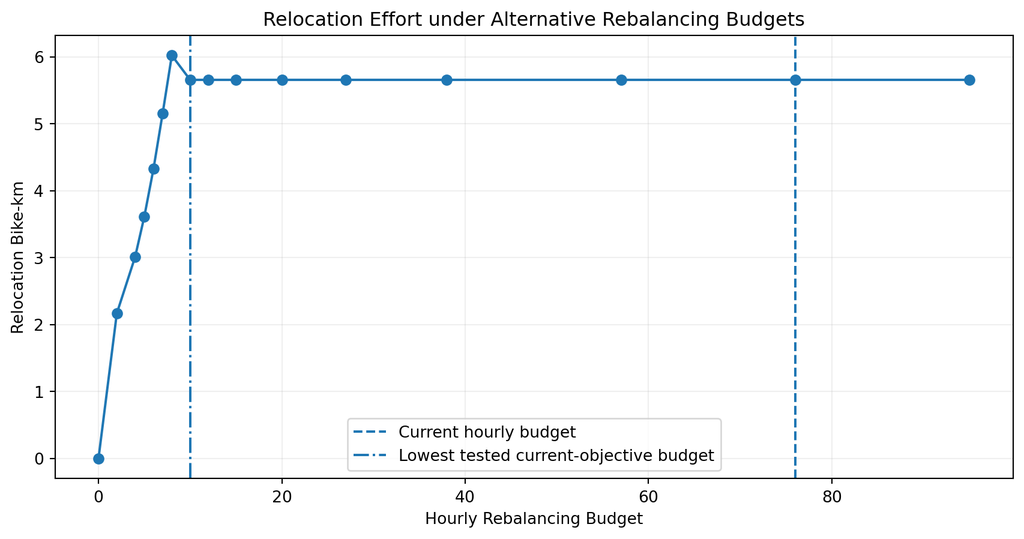

```python
fig, ax = plt.subplots(
    figsize=(
        9,
        4.8,
    )
)

ax.plot(
    budget_sensitivity[
        "Hourly budget"
    ],
    budget_sensitivity[
        "Relocation bike-km"
    ],
    marker="o",
)

ax.axvline(
    current_hourly_budget,
    linestyle="--",
    label="Current hourly budget",
)

if np.isfinite(
    minimum_objective_matching_budget
):

    ax.axvline(
        minimum_objective_matching_budget,
        linestyle="-.",
        label="Lowest tested current-objective budget",
    )

ax.set_title(
    "Relocation Effort under Alternative Rebalancing Budgets"
)

ax.set_xlabel(
    "Hourly Rebalancing Budget"
)

ax.set_ylabel(
    "Relocation Bike-km"
)

ax.margins(
    y=0.05
)

ax.legend()

ax.grid(
    alpha=0.20,
)

plt.tight_layout()
plt.show()
```

#### Local Shadow-Price Check

Increasing every hourly budget by one unit provides a finite-difference check of the current budget shadow prices.

```python
budget_plus_one_result = (
    solve_lp_variant(
        hourly_budget=
            current_hourly_budget
            +
            1,

        failure_penalty=
            service_failure_penalty,
    )
)

budget_plus_one_metrics = (
    extract_lp_metrics(
        budget_plus_one_result,
        service_failure_penalty,
    )
)

finite_difference_budget_improvement = (
    base_lp_metrics[
        "objective_value"
    ]
    -
    budget_plus_one_metrics[
        "objective_value"
    ]
    if budget_plus_one_metrics[
        "success"
    ]
    else np.nan
)

budget_dual_validation = pd.DataFrame(
    {
        "Measure": [
            "Dual-predicted objective improvement",
            "Finite-difference objective improvement",
        ],

        "Value": [
            budget_shadow_prices[
                "shadow_value"
            ].sum(),

            finite_difference_budget_improvement,
        ],
    }
)

(
    budget_dual_validation
    .round(6)
    .style
    .hide(axis="index")
)
```

| Measure | Value |
| --- | --- |
| Dual-predicted objective improvement | 0.000000 |
| Finite-difference objective improvement | 0.000000 |

### 15.6 Service-Penalty Sensitivity

The penalty parameter controls the tradeoff between relocation effort and service failure. Because the penalty changes the objective function itself, objective values are retained in the saved data but are not used for direct cross-scenario comparison.

```python
penalty_grid = np.unique(
    np.array(
        [
            0.50,
            0.60,
            0.70,
            0.80,
            0.90,
            1.00,
            2.00,
            5.00,
            10.00,
            float(
                service_failure_penalty
            ),
            50.00,
            100.00,
        ]
    )
)
```

```python
penalty_sensitivity_rows = []

for penalty_value in (
    penalty_grid
):

    result = solve_lp_variant(
        hourly_budget=
            current_hourly_budget,

        failure_penalty=
            float(
                penalty_value
            ),
    )

    metrics = extract_lp_metrics(
        result,
        float(
            penalty_value
        ),
    )

    penalty_sensitivity_rows.append(
        {
            "Service-failure penalty":
                float(
                    penalty_value
                ),

            "Success":
                metrics[
                    "success"
                ],

            "Objective value":
                metrics.get(
                    "objective_value",
                    np.nan,
                ),

            "Total service failures":
                metrics.get(
                    "total_service_failures",
                    np.nan,
                ),

            "Unmet departures":
                metrics.get(
                    "unmet_departures",
                    np.nan,
                ),

            "Blocked arrivals":
                metrics.get(
                    "blocked_arrivals",
                    np.nan,
                ),

            "Bikes rebalanced":
                metrics.get(
                    "bikes_rebalanced",
                    np.nan,
                ),

            "Relocation bike-km":
                metrics.get(
                    "relocation_bike_km",
                    np.nan,
                ),
        }
    )

penalty_sensitivity = (
    pd.DataFrame(
        penalty_sensitivity_rows
    )
    .sort_values(
        "Service-failure penalty"
    )
    .reset_index(
        drop=True
    )
)

penalty_sensitivity_display = (
    penalty_sensitivity[
        [
            "Service-failure penalty",
            "Success",
            "Total service failures",
            "Unmet departures",
            "Blocked arrivals",
            "Bikes rebalanced",
            "Relocation bike-km",
        ]
    ]
    .copy()
)

(
    penalty_sensitivity_display
    .round(4)
    .style
    .hide(axis="index")
)
```

| Service-failure penalty | Success | Total service failures | Unmet departures | Blocked arrivals | Bikes rebalanced | Relocation bike-km |
| --- | --- | --- | --- | --- | --- | --- |
| 0.500000 | True | 1.000000 | 1.000000 | 0.000000 | 26.000000 | 4.977900 |
| 0.600000 | True | 1.000000 | 1.000000 | 0.000000 | 26.000000 | 4.977900 |
| 0.700000 | True | 0.000000 | 0.000000 | 0.000000 | 27.000000 | 5.657500 |
| 0.800000 | True | 0.000000 | 0.000000 | 0.000000 | 27.000000 | 5.657500 |
| 0.900000 | True | 0.000000 | 0.000000 | 0.000000 | 27.000000 | 5.657500 |
| 1.000000 | True | 0.000000 | 0.000000 | 0.000000 | 27.000000 | 5.657500 |
| 2.000000 | True | 0.000000 | 0.000000 | 0.000000 | 27.000000 | 5.657500 |
| 5.000000 | True | 0.000000 | 0.000000 | 0.000000 | 27.000000 | 5.657500 |
| 10.000000 | True | 0.000000 | 0.000000 | 0.000000 | 27.000000 | 5.657500 |
| 25.000000 | True | 0.000000 | 0.000000 | 0.000000 | 27.000000 | 5.657500 |
| 50.000000 | True | 0.000000 | 0.000000 | 0.000000 | 27.000000 | 5.657500 |
| 100.000000 | True | 0.000000 | 0.000000 | 0.000000 | 27.000000 | 5.657500 |

```python
zero_failure_penalty_rows = (
    penalty_sensitivity.loc[
        penalty_sensitivity[
            "Success"
        ]
        &
        (
            penalty_sensitivity[
                "Total service failures"
            ]
            <= dual_tolerance
        )
    ]
)

minimum_zero_failure_penalty = (
    zero_failure_penalty_rows[
        "Service-failure penalty"
    ]
    .min()
    if len(
        zero_failure_penalty_rows
    ) > 0
    else np.nan
)

# Backward-compatible name used in earlier report code.
minimum_matching_penalty = (
    minimum_zero_failure_penalty
)
```

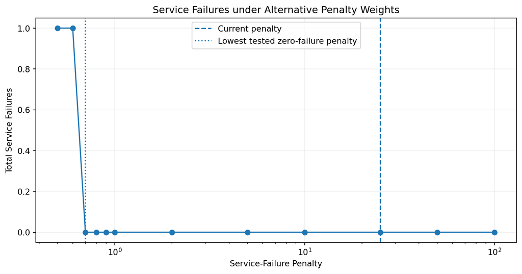

```python
fig, ax = plt.subplots(
    figsize=(
        9,
        4.8,
    )
)

ax.plot(
    penalty_sensitivity[
        "Service-failure penalty"
    ],
    penalty_sensitivity[
        "Total service failures"
    ],
    marker="o",
)

ax.axvline(
    service_failure_penalty,
    linestyle="--",
    label="Current penalty",
)

if np.isfinite(
    minimum_zero_failure_penalty
):

    ax.axvline(
        minimum_zero_failure_penalty,
        linestyle=":",
        label="Lowest tested zero-failure penalty",
    )

ax.set_xscale(
    "log"
)

ax.set_title(
    "Service Failures under Alternative Penalty Weights"
)

ax.set_xlabel(
    "Service-Failure Penalty"
)

ax.set_ylabel(
    "Total Service Failures"
)

ax.margins(
    y=0.05
)

ax.legend()

ax.grid(
    alpha=0.20,
)

plt.tight_layout()
plt.show()
```

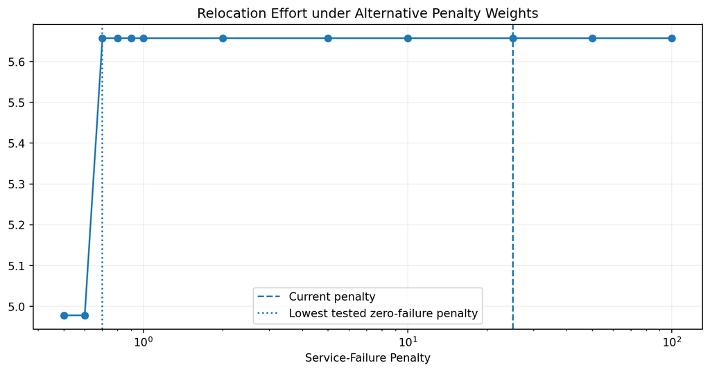

```python
fig, ax = plt.subplots(
    figsize=(
        9,
        4.8,
    )
)

ax.plot(
    penalty_sensitivity[
        "Service-failure penalty"
    ],
    penalty_sensitivity[
        "Relocation bike-km"
    ],
    marker="o",
)

ax.axvline(
    service_failure_penalty,
    linestyle="--",
    label="Current penalty",
)

if np.isfinite(
    minimum_zero_failure_penalty
):

    ax.axvline(
        minimum_zero_failure_penalty,
        linestyle=":",
        label="Lowest tested zero-failure penalty",
    )

ax.set_xscale(
    "log"
)

ax.set_title(
    "Relocation Effort under Alternative Penalty Weights"
)

ax.set_xlabel(
    "Service-Failure Penalty"
)

ax.margins(
    y=0.05
)

ax.margins(
    y=0.05
)

ax.legend()

ax.grid(
    alpha=0.20,
)

plt.tight_layout()
plt.show()
```